# ThrustOne Theory Manual

## 12.4 Air flow, corrected flow and speed

The implemented air-flow scaling is

$$\frac{\dot m_a}{\dot m_{aR}}=
\frac{p_0\pi_r\pi_d\pi_c}{p_{0R}\pi_{rR}\pi_{dR}\pi_{cR}}
\sqrt{\frac{T_{t4R}}{T_{t4}}}.$$

At otherwise identical dimensionless conditions, decreasing ambient pressure decreases dimensional mass flow and thrust while leaving specific thrust unchanged. This is one reason that a specific-performance plot cannot replace an absolute-thrust plot.

The reported corrected-flow ratio is

$$\frac{\dot m_{c}}{\dot m_{cR}}=
\frac{\pi_c}{\pi_{cR}}\sqrt{\frac{\theta_R}{\theta}}.$$

It is a reference-normalized result, not a dimensional corrected flow in kg/s. The mechanical speed ratio is

$$\frac{N}{N_R}=
\sqrt{\frac{T_{t2}}{T_{t2R}}
\frac{\pi_c^{(\gamma_c-1)/\gamma_c}-1}
{\pi_{cR}^{(\gamma_c-1)/\gamma_c}-1}}.$$

The square root is essential: the quantity inside it scales a work-like term with speed squared. This mechanical speed ratio is not the corrected-speed map coordinate discussed in Chapter 3. To form a corrected-speed ratio at the same inlet reference convention, an additional temperature correction is required.

The aliases `speed_ratio`, `n_nr` and `N_NR` refer to the same mechanical ratio. Multiple output names do not represent separate speed definitions.

## 12.5 Nozzle and admissibility

Available nozzle pressure ratio is

$$NPR=(p_0/p_9)\pi_r\pi_d\pi_c\pi_b\pi_{tR}\pi_n.$$

The exit velocity and pressure thrust are calculated from the specified exit static pressure using Chapter 9’s relations. The model does not solve a fixed exit-area back-pressure problem; its exit area is intended to vary consistently with the requested expansion while throat area remains fixed.

The current single-spool solver checks $NPR>1$ for a jet, but does not require the current NPR to exceed the critical choking ratio. Thus an accepted low-NPR result does not establish the choking assumption on which its reference model relies. Check that assumption when interpreting operating points. The dual-spool branch, described below, explicitly rejects an unchoked nozzle condition.

Other refusals include invalid reference values, insufficient burner energy, nonpositive computed compressor rise, nonpositive thrust and nonfinite results. Such numerical guards cannot prove that the fixed-ratio turbine approximation remains valid under all changed inputs. In particular, independently varying gas properties or loss factors can invalidate cancellations used to obtain the reference scaling.

## 12.6 Exit-area reconstruction

For an isentropic constant-property nozzle with fixed throat area, the mass-flow parameter gives, up to factors constant between operating and reference states,

$$\frac{A_9}{A_*}\propto
\frac{NPR^{(\gamma+1)/(2\gamma)}}
{\sqrt{NPR^{(\gamma-1)/\gamma}-1}}.$$

Therefore the consistent exit-area ratio is

$$\frac{A_9}{A_{9R}}=
\left(\frac{NPR}{NPR_R}\right)^{(\gamma+1)/(2\gamma)}
\sqrt{\frac{NPR_R^{(\gamma-1)/\gamma}-1}
{NPR^{(\gamma-1)/\gamma}-1}}.$$

The `area_ratio_9` diagnostic uses the pressure-ratio orientation shown above. Both factors equal one at the reference state. That normalization alone is not enough to establish the formula away from the reference: reversing the first pressure ratio would still reproduce the reference area while producing incorrect off-reference geometry.

The area diagnostic is calculated after thrust and flow and does not feed them back into the solver. It reconstructs the exit area implied by the fixed-throat, isentropic nozzle relation; it does not introduce a geometric matching calculation or validate a real nozzle under separation, shocks or unchoked operation.

## 12.7 Worked normalized throttle change

Consider an illustrative reference inlet total temperature of 282 K, turbine-entry temperature 1500 K, compressor temperature ratio 1.8 and reference isentropic compressor efficiency 0.85, with gamma 1.4. Choose a consistent reference pressure ratio from the compressor relation:

$$\pi_{cR}=[1+0.85(1.8-1)]^{3.5}=6.14585750.$$

Reduce turbine-entry temperature to 1350 K at unchanged inlet total temperature and unchanged inlet pressure and recovery factors. The loading ratio is 0.9, giving

$$\tau_c=1+0.8(0.9)=1.72,\qquad T_{t3}=282(1.72)=485.04\ \mathrm{K},$$

$$\pi_c=[1+0.85(0.72)]^{3.5}=5.31835877.$$

The predicted air-flow ratio is

$$\frac{\dot m_a}{\dot m_{aR}}=
\frac{5.31835877}{6.14585750}\frac{1}{\sqrt{0.9}}
=0.91216602.$$

The mechanical speed ratio is $\sqrt{0.9}=0.94868330$. Flow and speed do not fall in the same proportion. The flow relation combines reduced compressor pressure with the square-root turbine-temperature factor; the speed relation follows the compressor work scaling.

These numbers demonstrate the reference equations only. A complete operating point additionally needs turbine ratios, burner assumptions and a nozzle condition that remains inside the choking and thrust domain. No dimensional thrust or physical engine performance is inferred from this partial reference specification.

## 12.8 Two spools require two reference rises

The dual-spool mode separates low- and high-pressure compressor temperature ratios, $\tau_{cL}$ and $\tau_{cH}$. Define

$$\Theta=\frac{T_{t4}/T_0}{T_{t4R}/T_{0R}}.$$

The implemented relations are

$$\tau_{cL}=1+\Theta\frac{\tau_{rR}}{\tau_r}(\tau_{cLR}-1),$$

$$\tau_{cH}=1+\Theta
\frac{\tau_{rR}\tau_{cLR}}{\tau_r\tau_{cL}}(\tau_{cHR}-1).$$

The second compressor receives the first compressor’s outlet. Its normalization must therefore include $\tau_{cL}$; treating both compressors as though they had the same inlet temperature would alter high-spool work.

Separate supplied isentropic efficiencies convert each temperature ratio into pressure ratio. Air flow scales with the product $\pi_{cL}\pi_{cH}$, the actual inlet pressure factors and the turbine-temperature square root. The reference denominator uses its stored recovery. A consistent interpretation requires that stored reference factor represent the intended reference inlet convention, especially when preparing a nonzero-Mach reference.

High- and low-turbine temperature and pressure ratios are explicit fixed inputs. Their product determines the turbine-exit state. The code does not solve new independent turbine maps or integrate two shaft accelerations. The physical rationale involves spool work and choked capacities, but the implementation uses the resulting reference relations rather than an unrestricted coupled matching solve.

## 12.9 Dual-spool speed and afterburner behavior

The low-spool mechanical speed ratio is formed from the low-compressor pressure-work ratio and its inlet total temperature. The high-spool ratio uses the high-compressor inlet temperature, which includes the low-compressor temperature rise:

$$\frac{N_H}{N_{HR}}=
\sqrt{\frac{T_0\tau_r\tau_{cL}}{T_{0R}\tau_{rR}\tau_{cLR}}
\frac{\pi_{cH}^{(\gamma_c-1)/\gamma_c}-1}
{\pi_{cHR}^{(\gamma_c-1)/\gamma_c}-1}}.$$

This extra temperature factor is required even though both shafts belong to the same engine. Neither speed ratio alone determines corrected-flow matching on a component map.

Optional afterburning uses the main-fuel-plus-air mass entering the chamber and adds its own fuel mass and pressure loss. The dual-spool implementation uses afterburner temperature in its nozzle static-temperature expression. The constant-property design-point path likewise uses its augmented nozzle total temperature. Similar feature names still do not imply identical matching assumptions or numerical paths.

The dual-spool warning explicitly assumes choking at stations 4, 4.5 and 8 and variable nozzle area to isolate downstream afterburning from turbine matching. It checks the current nozzle’s critical pressure ratio. It does not solve internal turbine throat states to demonstrate all of those assumptions independently.

For unchanged upstream inputs, enabling afterburning leaves reference-derived compressor ratios, core flow and shaft speed ratios unchanged, while changing nozzle pressure, temperature, exhaust mass and thrust. That is the intended variable-area reference model; it is not a prediction of what happens when fuel is added to an arbitrary fixed nozzle.

## 12.10 Reading a reference-family result

Both off-design modes produce a restricted steady operating relation. They omit compressor-map matching, surge dynamics, spool transients, cooling-flow schedules and general unchoked operation. The single-spool implementation additionally requires care because a simple positive-NPR guard does not enforce its choking assumption, so users must retain the stated choked-flow domain when interpreting its reconstructed exit area.

A useful report retains reference identity, current flight state and throttle, fixed turbine ratios, pressure-loss assumptions and nozzle setting. Interpret mechanical speed, corrected flow and dimensional flow separately. Do not substitute one for another because all three are expressed as ratios near one.

Preserving those distinctions makes reference normalization useful for controlled comparisons. It also identifies where a broader engine model would need new equations or data instead of silently extending the present approximation outside its declared domain.

# 13. Separate-flow turbofans

A separate-flow turbofan divides incoming air between a heated core and a bypass stream. The turbine supplies work to the compression system, including the work used to accelerate bypass air through the fan. The two streams leave through separate nozzles, and their momentum and pressure contributions combine in the net thrust.

The additional stream introduces two common accounting errors: applying fuel ratio to total air when it is defined on core air, and multiplying a total-air specific thrust by core flow. It also creates a thermodynamic tradeoff. Increasing bypass flow can spread momentum addition over more air, but the fan work must still come from the core turbine.

This chapter covers the constant-property single-spool separate design mode and the separate-exhaust branch of the variable-property single-spool mode. Their compressor pressure ratios have different inlet references. A physically consistent comparison must resolve that difference before numerical inputs are reused.

## 13.1 Core, bypass and fuel mass

Define bypass ratio and main fuel ratio by

$$\alpha=\frac{\dot m_b}{\dot m_c},\qquad
f=\frac{\dot m_f}{\dot m_c},$$

where $\dot m_c$ is core **air** flow and $\dot m_b$ bypass air flow. Total incoming air is

$$\dot m_a=(1+\alpha)\dot m_c.$$

Without afterburning, the core nozzle carries $(1+f)\dot m_c$, and the bypass nozzle carries $\alpha\dot m_c$. Fuel does not belong in the definition of bypass ratio.

Normalize first to one kilogram of core air. The incoming air inventory is then $1+\alpha$, fuel is $f$, core exhaust is $1+f$, and bypass exhaust is $\alpha$. This basis makes shaft work and burner energy particularly clear. Divide by $1+\alpha$ only when forming a quantity explicitly defined per unit total inlet air.

Separate exhaust means the streams need not have equal exit temperatures, velocities or static pressures. They share the ambient reference pressure used for net pressure thrust, but their two nozzle expansions are independently specified in the constant-property design model.

## 13.2 Constant-property compression convention

The constant-property mode defines core compressor pressure ratio as $p_{t3}/p_{t2}$, from inlet exit directly to core burner entry. The fan ratio defines $p_{t13}/p_{t2}$ for the bypass path. It does not multiply the fan ratio into the supplied core ratio a second time.

Using the inlet total state from Chapter 4,

$$T_{t3}=T_{t2}\tau_c,\qquad T_{t13}=T_{t2}\tau_f,$$

$$\tau_c=\pi_c^{(\gamma_c-1)/(\gamma_ce_c)},\qquad
\tau_f=\pi_f^{(\gamma_c-1)/(\gamma_ce_f)}.$$

The input efficiencies here are polytropic. Derived isentropic efficiencies follow the finite-rise conversion in Chapter 11. Fan and core compressor are represented as effective compression paths; the model does not require a particular physical split between fan root and additional core stages.

The total compression work per kilogram of core air is

$$w_{\mathrm{load}}=c_{p,c}(T_{t3}-T_{t2})
+\alpha c_{p,c}(T_{t13}-T_{t2}).$$

The first term already includes the full core compression from station 2. Adding another fan-work term for core air would count part of that path twice under this convention.

## 13.3 Burner and single-shaft turbine balance

Only core air enters the main burner. The nonideal fuel balance is

$$c_{p,c}T_{t3}+f\eta_bQ_R=(1+f)c_{p,h}T_{t4},$$

which gives

$$f=\frac{c_{p,h}T_{t4}-c_{p,c}T_{t3}}
{\eta_bQ_R-c_{p,h}T_{t4}}.$$

At prescribed core pressure ratio and turbine-entry temperature, this expression contains no bypass ratio. Changing bypass ratio alone therefore does not change main fuel ratio in this specific design closure. It does change how much turbine work must be extracted after combustion.

The shaft balance is

$$\eta_m(1+f)c_{p,h}(T_{t4}-T_{t5})=w_{\mathrm{load}}.$$

In temperature-ratio notation, with $\tau_\lambda=c_{p,h}T_{t4}/(c_{p,c}T_0)$,

$$\tau_t=1-
\frac{\tau_r[(\tau_c-1)+\alpha(\tau_f-1)]}
{\eta_m(1+f)\tau_\lambda}.$$

Turbine polytropic efficiency then determines $\pi_t$ from $\tau_t$. More bypass work lowers turbine-exit total temperature and pressure at unchanged main-burner conditions. Eventually the chosen fan demand can leave insufficient energy or pressure for a usable core nozzle.

The solver rejects nonpositive turbine temperature ratio and nonpositive total thrust. These guards identify incompatible prescribed operating points; they do not optimize fan pressure ratio or bypass ratio automatically.

## 13.4 Two nozzle calculations

The constant-property core nozzle receives

$$T_{t9}=T_{t4}\tau_t,\qquad
p_{t9}=p_{t2}\pi_c\pi_b\pi_t\pi_{n,c}.$$

The bypass nozzle receives

$$T_{t19}=T_{t2}\tau_f,\qquad
p_{t19}=p_{t2}\pi_f\pi_{n,b}.$$

Each has its own prescribed ambient-to-exit static-pressure ratio. Its exit Mach, temperature and velocity follow the total-to-static equations in Chapter 9, with hot-gas properties for the core and cold-air properties for bypass flow.

These are pressure-specified expansions, not fixed-area convergent-nozzle solutions. A Mach number above one does not establish that a particular nozzle geometry supports it. Separation, internal shocks and installed nacelle forces remain outside the calculation.

The current constant-property solver evaluates both nozzle pressure conditions even when bypass ratio is zero. Thus an otherwise valid core calculation can still be rejected by an invalid unused bypass-nozzle setting. The zero-bypass limit of the governing thrust and work equations exists, but the present input guards do not fully remove that inactive calculation. Retain a valid bypass setting when using this limit; do not infer an aerodynamic failure of the core from that rejection.

## 13.5 Combining thrust on a consistent basis

For the two nozzles,

$$F=\dot m_c[(1+f)V_9-V_0]+(p_9-p_0)A_9
+\alpha\dot m_c(V_{19}-V_0)+(p_{19}-p_0)A_{19}.$$

Eliminating areas with each stream’s continuity equation gives a core contribution per unit core air,

$$F_{s,c}=(1+f)V_9-V_0+
\frac{(1+f)R_hT_9}{V_9}(1-p_0/p_9),$$

and a bypass contribution per unit bypass air,

$$F_{s,b}=V_{19}-V_0+
\frac{R_cT_{19}}{V_{19}}(1-p_0/p_{19}).$$

The total result on the core-air basis is $F/\dot m_c=F_{s,c}+\alpha F_{s,b}$. The App’s principal specific thrust uses total air:

$$F_s=\frac{F_{s,c}+\alpha F_{s,b}}{1+\alpha}.$$

Fuel consumption follows

$$TSFC=\frac{f}{F_{s,c}+\alpha F_{s,b}}
=\frac{f}{(1+\alpha)F_s}.$$

The constant-property mode’s optional dimensional flow input is core air flow. Therefore net thrust is $\dot m_c[F_{s,c}+\alpha F_{s,b}]$. Its reported total mass flow is incoming air flow, not total exhaust including fuel. These definitions should accompany exported values.

## 13.6 Why bypass flow can improve momentum efficiency

For a single fully expanded stream without added mass, thrust is $\dot m(V_e-V_0)$, while kinetic-energy increase is $\dot m(V_e^2-V_0^2)/2$. At a fixed thrust, accelerating more mass through a smaller velocity increment can reduce the required kinetic-energy increase. This is the basic motivation for bypass propulsion.

The argument does not mean that arbitrarily large bypass ratio always improves an engine. The fan requires work, inlet and nozzle losses consume pressure potential, and a real installation has size, drag and mass consequences. Only the first two effects are represented in this simplified cycle. The final design tradeoff cannot be inferred from a total-air specific-thrust value alone.

For two fully expanded streams, kinetic power per unit core air is

$$\Delta e_k=\frac{(1+f)V_9^2+\alpha V_{19}^2-(1+\alpha)V_0^2}{2}.$$

The constant-property model uses it for thermal and propulsive efficiencies. If either active stream is not fully expanded, the App omits that kinetic decomposition and retains overall thrust-power efficiency. A zero-mass bypass stream is excluded from the full-expansion efficiency condition, even though its nozzle calculation is still evaluated as noted above.

## 13.7 Worked separate-flow cycle

Choose an illustrative nonideal case: $M_0=0.8$, $T_0=250$ K, bypass ratio 3, fan ratio 1.5, core ratio 10 and turbine-entry temperature 1500 K. Use $c_{p,c}=1005$, $c_{p,h}=1150$ J/(kg K), gamma 1.4/1.33, heating value 43 MJ/kg, inlet recovery 0.97, burner pressure ratio 0.95 and both nozzle recoveries 0.98. Compressor and fan polytropic efficiencies are 0.90, turbine polytropic efficiency is 0.92, burner efficiency 0.98 and mechanical efficiency 0.99. Both streams expand to ambient pressure.

The inlet total temperature is 282 K. Direct evaluation gives:

| Quantity | Value |
| --- | --- |
| Core compressor outlet total temperature | 585.746127 K |
| Bypass fan outlet total temperature | 320.738501 K |
| Main fuel/core-air ratio | 0.028116421 |
| Turbine outlet total temperature | 1139.421071 K |
| Core nozzle pressure ratio | 4.12771119 |
| Bypass nozzle pressure ratio | 2.17355642 |
| Core exit velocity | 881.574083 m/s |
| Bypass exit velocity | 358.124321 m/s |

Freestream speed is 253.613880 m/s. The core contributes 652.746911 N s/kg of core air, and bypass contributes 104.510442 N s/kg of bypass air. Therefore

$$F/\dot m_c=652.746911+3(104.510442)=966.278236\ \mathrm{N\,s/kg}.$$

Total-air specific thrust is 241.569559 N s/kg. With core air flow 10 kg/s, total air flow is 40 kg/s, thrust is 9.662782 kN, and fuel flow is approximately 0.281164 kg/s. TSFC is 29.097645 mg/(N s).

Multiplying the principal specific thrust by 10 kg/s would understate thrust by a factor of four. Either multiply it by total air flow or multiply thrust per core flow by core air flow. These are equivalent routes when the definitions are retained.

The example is direct arithmetic for the stated model, not a measured engine. Its absolute ambient pressure can be supplied independently when a dimensional station pressure is needed; the fully expanded specific results above depend on pressure ratios and temperature rather than an absolute pressure scale in this prescribed-flow calculation.

## 13.8 Variable-property fan and core architecture

The variable-property single-spool mode first compresses **all** air through the fan. Core air then passes through an additional compressor. Here the compressor pressure ratio is relative to the fan exit:

$$p_{t13}=p_{t2}\pi_f,\qquad p_{t3}=p_{t13}\pi_{c,additional}.$$

Its work per unit core air is

$$w_{\mathrm{load}}=(1+\alpha)w_f+w_{c,additional}.$$

This differs in notation from the constant-property closure because the core fan work is now explicit. In the constant-property convention it was already included in the core’s station-2-to-3 work. Neither formula should be transplanted without also changing the compressor reference station.

To align pressure paths, a comparison can set the constant-property core ratio to $\pi_f\pi_{c,additional}$. This does not alone align work: the property functions and efficiency definitions also differ. The variable-property fan and compressor use explicit isentropic efficiencies and enthalpy/entropy inversions.

The gaseous main fuel ratio is specified per core air, and equilibrium determines burner temperature from the separate fuel and air feed enthalpies. The turbine extracts the combined shaft load from $(1+f)$ core gas. Its composition is frozen after the equilibrium chamber. Chapter 10 supplies the detailed thermodynamic steps.

## 13.9 Variable-property normalization and optional afterburning

The variable-property mode takes **total** inlet air flow as its dimensional input and obtains core flow as $\dot m_a/(1+\alpha)$. This is the opposite input convention from the constant-property mode’s optional core-flow field, though the physical definitions are consistent.

For a separate core afterburner with additional ratio $f_{AB}$, the thrust per core air is

$$F/\dot m_c=(1+f+f_{AB})V_9+\alpha V_{19}-(1+\alpha)V_0.$$

Both nozzles are fully expanded in this branch. Fuel flow is $(f+f_{AB})\dot m_c$, and TSFC is total fuel ratio divided by thrust per core air. Afterburning affects the core exhaust and adds pressure loss after the turbine; it does not heat the bypass stream or alter the already closed fan work.

When bypass ratio is zero, the variable-property implementation skips the bypass nozzle evaluation. Its fan stage can still have a supplied pressure ratio and act on core air in the turbofan configuration. Therefore zero bypass alone is not identical to the turbojet configuration unless the compression paths are also aligned.

No thermal or propulsive efficiency is currently returned by this variable-property cycle. Its energy and shaft residuals describe closure, and its species fractions describe the final frozen nozzle mixture. The absence of a selected chemical-power denominator should not be filled by importing a heating value from another model without an explicit definition.

## 13.10 Limits of a separate-stream comparison

Separate flow avoids a mixer compatibility problem: there is no requirement that the two internal nozzle-entry streams share one static pressure plane. Each follows its own expansion to its selected exit condition. Mixing them upstream of a common nozzle requires new area, momentum and static-pressure conditions, not an average of the two velocities.

Both design modes are single-spool steady models. They do not solve a multispool operating schedule, component-map matching, cooling extraction, installed drag or fixed-geometry nozzle response. The constant-property ideal option additionally uses unit losses and cold properties throughout while neglecting fuel mass in turbine/exhaust balances; it requires both exit pressure ratios to be one.

A useful comparison reports bypass ratio, the compressor reference stations, fuel and thrust mass bases, both nozzle conditions and the physical flow scale. Those definitions reveal whether an improvement comes from a different core cycle, more bypass mass, a changed fan load or simply a changed normalization. Chapter 14 adds the conservation conditions needed when the two streams are deliberately combined.

# 14. Mixing and mixed-flow cycles

A common nozzle requires a common stream. Combining separate exhaust thrusts is not equivalent to mixing those streams upstream: a mixer must reconcile mass, species, energy, momentum and static pressure. Its outlet total pressure is a consequence of these constraints, rather than a mass-weighted average of inlet total pressures.

ThrustOne provides constant-property and frozen NASA9 mixing models. Both assume two subsonic incoming streams at equal static pressure and a constant total cross-sectional area. Both reconstruct a subsonic conservation outlet before applying an optional downstream total-pressure loss. This separation of planes is essential to interpreting the result.

## 14.1 The three distinct planes

The inlet plane contains adjacent core and bypass areas, $A_c$ and $A_b$, with a shared static pressure $p_i$. Their temperatures, velocities, total pressures and compositions can differ. The conservation outlet has one uniform state at total area $A=A_c+A_b$. A third, conceptual delivery state applies the user-specified additional total-pressure recovery.

The conservation outlet and the delivery state must not be combined into one implied static state. The additional recovery does not feed back into the inlet matching or the momentum balance. Its downstream static Mach is not separately reconstructed by this mixer.

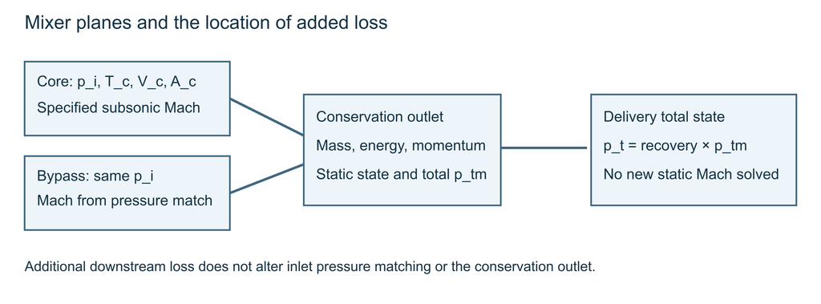

Distinct inlet, conservation and delivery planes

A field named `ideal_mixer_exit_mach` refers to the conservation outlet before the additional pressure loss. The word ideal here does not mean that unlike-stream mixing is reversible or isentropic. Irreversibility can already arise in the conservation-based mixing process.

## 14.2 Matching the incoming static pressures

The input supplies both total states and the core Mach number. For constant properties,

$$T_c=\frac{T_{tc}}{1+(\gamma_c-1)M_c^2/2},\qquad
p_i=p_{tc}(T_c/T_{tc})^{\gamma_c/(\gamma_c-1)}.$$

The bypass Mach follows from its total pressure and that required common static pressure:

$$M_b=\sqrt{\frac{2}{\gamma_b-1}
\left[(p_{tb}/p_i)^{(\gamma_b-1)/\gamma_b}-1\right]}.$$

A positive-flow bypass must have sufficient total pressure and a resulting Mach strictly below one. If its total pressure is below the required static pressure, an isentropic incoming state cannot be formed. If the required Mach is supersonic, it lies outside this two-subsonic-inlet model. Reducing downstream mixer recovery cannot repair either incompatibility, because it acts at a different plane.

After velocities and densities are known, continuity supplies areas:

$$A_c=\frac{\dot m_c}{\rho_cV_c},\qquad
A_b=\frac{\dot m_b}{\rho_bV_b}.$$

Thus the input Mach and total states determine the required inlet geometry for the supplied flows. The model does not accept an arbitrary second inlet area and independently guarantee pressure matching.

For frozen NASA9 properties, the core static temperature is found from $h(T_c)+M_c^2a_f(T_c)^2/2=h_{tc}$, and entropy gives static pressure. The bypass static temperature is found at that pressure with its own total entropy; its velocity follows from enthalpy drop. These integrations replace constant-gamma powers while retaining the same physical matching condition.

## 14.3 Conserved mixture quantities

Total mass flow is $\dot m=\dot m_c+\dot m_b$. With adiabatic walls and no shaft work,

$$h_{tm}=\frac{\dot m_ch_{tc}+\dot m_bh_{tb}}{\dot m}.$$

For a constant-area mixer without an imposed external axial force, the incoming axial momentum-plus-pressure flux is

$$J=p_iA+\dot m_cV_c+\dot m_bV_b.$$

The uniform outlet must satisfy

$$\dot m=\rho_mV_mA,\qquad
h_m+V_m^2/2=h_{tm},\qquad
p_mA+\dot mV_m=J.$$

The quantity $J$ is not net engine thrust. It contains internal pressure forces and incoming momentum at the selected mixer boundary. Engine thrust requires a control volume extending to the external incoming and outgoing streams.

For constant effective properties, use mass-weighted $c_p$ and $R$, then form $\gamma=c_p/(c_p-R)$. Averaging the two gammas directly does not generally reproduce this thermodynamic relation. Mixed total temperature is $T_{tm}=h_{tm}/c_p$ under the shared $c_pT$ convention; it is a simple mass average only if the two heat capacities are equal.

For frozen species mixtures, sum actual species molar flows,

$$\dot n_i=\frac{\dot m_cx_{ic}}{\overline W_c}
+\frac{\dot m_bx_{ib}}{\overline W_b}.$$

Normalize their sum to obtain outlet mole fractions. Averaging mole fractions by mass flow would be wrong when molecular weights differ. No equilibrium chemistry is solved inside the frozen mixer, even if the combined mixture could react physically.

## 14.4 Deriving the constant-property velocity roots

Let $B=J/\dot m$. The momentum equation gives $p_mA/\dot m=B-V_m$, while continuity and the ideal-gas law give $p_mA/\dot m=RT_m/V_m$. Using $T_m=T_{tm}-V_m^2/(2c_p)$,

$$\left(1-\frac{R}{2c_p}\right)V_m^2-BV_m+RT_{tm}=0.$$

Define $a=1-R/(2c_p)$. The discriminant is $D=B^2-4aRT_{tm}$. A negative discriminant means there is no real outlet satisfying the declared momentum, energy and area conditions. It is not fixed by silently replacing the root with Mach one.

The lower-velocity root is evaluated in the cancellation-resistant form

$$V_m=\frac{2RT_{tm}}{B+\sqrt D}.$$

The solver then recovers static temperature, pressure and Mach and checks the subsonic branch and conservation residuals. The constant-property implementation permits a tiny numerical tolerance around Mach one; the variable-property mixer explicitly requires an exit below one. Neither model supplies a supersonic mixer branch or a shock-train transition.

The NASA9 calculation instead calls the frozen flux-state reconstruction with mass, area, total enthalpy and momentum flux, explicitly selecting its subsonic branch. Chapter 26 develops that more general inversion.

## 14.5 Total-pressure recovery after conservation

At the reconstructed outlet, total temperature comes from the conserved total enthalpy. Total pressure is obtained by isentropically stagnating that outlet state. For constant properties,

$$p_{tm}=p_m(T_{tm}/T_m)^{\gamma/(\gamma-1)}.$$

For NASA9 properties, the same operation uses entropy differences. Only after this calculation does the additional loss apply:

$$p_{t,delivered}=\pi_{m,extra}p_{tm}.$$

The conserved Mach and momentum residual still describe the preceding outlet. Treating the delivered pressure as though it belonged to the same static state would mix two definitions. No extra temperature drop accompanies this adiabatic total-pressure loss.

## 14.6 Original mixer example

Choose two illustrative constant-property streams with $c_p=1000$ J/(kg K), $R=250$ J/(kg K), hence $\gamma=4/3$. Let core and bypass flow be 2 and 3 kg/s, total temperatures 800 and 400 K, and both inlet Mach numbers 0.4 at common static pressure 100 kPa. Their matching total pressures are equal because gamma and Mach are equal; their velocities are not.

The core static temperature is 779.220779 K and velocity 203.858877 m/s. Bypass static temperature is 389.610390 K and velocity 144.149994 m/s. Continuity gives areas 0.01911177 and 0.02027109 m². Consequently,

$$A=0.03938286\ \mathrm{m^2},\quad
h_{tm}=560000\ \mathrm{J/kg},\quad J=4778.453994\ \mathrm{N}.$$

The subsonic conservation root gives $V_m=174.309256$ m/s, $T_m=544.808142$ K, $p_m=99.203244$ kPa and $M_m=0.40903388$. Its total temperature is 560 K and total pressure is 110.739772 kPa. Applying an additional recovery of 0.96 gives delivered total pressure 106.310181 kPa.

These are direct analytical arithmetic results for an original teaching case. They demonstrate why outlet static pressure need not equal the matched inlet pressure, and why an averaged total temperature alone is insufficient to recover outlet velocity or pressure. They are not a measured mixer-performance dataset.

## 14.7 Embedding the mixer in a dual-spool cycle

The constant-property mixed turbofan places the fan before the core–bypass split. The fan therefore acts on all incoming air. Its high-pressure compressor acts only on core air, downstream of the fan. Let the core-air flow be the accounting unit and let $\alpha$ denote bypass air divided by core air. The main fuel ratio $f$ is also based on core air.

For cold-gas exponent $e_c=(\gamma_c-1)/\gamma_c$, the fan and high-pressure compressor give

$$T_{t13}=T_{t2}\pi_f^{e_c/\eta_{pf}},\qquad
T_{t3}=T_{t13}\pi_{cH}^{e_c/\eta_{pc}}.$$

Here $\pi_{cH}$ is an additional pressure ratio after the fan. Thus $p_{t4}=p_{t2}\pi_f\pi_{cH}\pi_b$, rather than an expression in which the fan pressure rise disappears from the core path. The burner balance is

$$f=\frac{c_{ph}T_{t4}-c_{pc}T_{t3}}
{\eta_bQ-c_{ph}T_{t4}}.$$

The high-pressure turbine drives the high-pressure compressor; the low-pressure turbine drives the fan. With separate mechanical efficiencies,

$$T_{t45}=T_{t4}-\frac{c_{pc}(T_{t3}-T_{t13})}
{\eta_{mH}(1+f)c_{ph}},$$

$$T_{t5}=T_{t45}-\frac{(1+\alpha)c_{pc}(T_{t13}-T_{t2})}
{\eta_{mL}(1+f)c_{ph}}.$$

The factor $1+\alpha$ in the second equation is essential: core air also passes through the fan. Conversely, only the hot core stream passes through these turbines. Assigning bypass mass to turbine power would overstate the available shaft work.

For hot-gas exponent $e_h=(\gamma_h-1)/\gamma_h$, the model uses turbine polytropic efficiency to infer the two pressure ratios:

$$\pi_{tH}=(T_{t45}/T_{t4})^{1/(e_h\eta_{pt})},\qquad
\pi_{tL}=(T_{t5}/T_{t45})^{1/(e_h\eta_{pt})}.$$

The mixer receives core mass $1+f$ at $T_{t5},p_{t4}\pi_{tH}\pi_{tL}$, and bypass mass $\alpha$ at $T_{t13},p_{t2}\pi_f$. Positive turbine temperatures alone do not guarantee an admissible engine. These two streams must also satisfy the static-pressure and subsonic conditions of Sections 14.2–14.4. A thermodynamically possible compressor–turbine calculation can therefore end with an incompatible mixer.

This calculation closes shaft power at a prescribed design point. It does not match two rotating component maps, determine shaft speeds, or solve a fixed installed mixer geometry. The mixer areas are consequences of the chosen states, flows and core Mach. A sequence of design-point calculations may imply a different area at every point.

## 14.8 Post-mixer afterburning and fuel bases

The incoming mass at the afterburner is

$$\mu=1+f+\alpha$$

per unit core air. Let $f_{ab}$ be added afterburner fuel per unit core air, $h_{tm}$ the mixed total enthalpy, and $h_{t7}=c_{p,ab}T_{t7}$ the target hot-gas total enthalpy in the effective constant-property convention. The energy balance is

$$\mu h_{tm}+\eta_{ab}f_{ab}Q=(\mu+f_{ab})h_{t7},$$

hence

$$f_{ab}=\mu\frac{c_{p,ab}T_{t7}-c_{pm}T_{tm}}
{\eta_{ab}Q-c_{p,ab}T_{t7}}.$$

Leaving out $\mu$ changes the fuel reference to incoming mixed gas. That can be a useful ratio, but it cannot then be added directly to main-chamber $f$. The App reports both fuel additions on the core-air basis.

The denominator must be positive, the required enthalpy increase nonnegative, and the target temperature cannot be below the incoming mixed temperature in this mode. Because the effective heat capacity may change across the afterburner, temperature ordering and enthalpy ordering are separate checks. This is an effective sensible-enthalpy model; it does not calculate an equilibrium species inventory.

As an original bookkeeping example, continue the 5 kg/s mixer case with incoming total enthalpy 560 kJ/kg. Specify an afterburner gas with $c_p=1200$ J/(kg K), target total temperature 1000 K, $Q=43$ MJ/kg and efficiency 0.98. Direct substitution gives added fuel 0.0781632 kg/s. Relative to the 5 kg/s incoming mixture, the ratio is 0.0156326. If the 2 kg/s hot core stream contains main fuel, neither of these numbers is automatically the added fuel per kilogram of core air: the original core-air flow must first be recovered. This example deliberately preserves the distinction between a stand-alone mixer and an engine’s accounting basis.

Total pressure delivered to the nozzle is the conservation-derived mixed total pressure multiplied successively by the extra mixer recovery, afterburner pressure ratio when enabled, and nozzle pressure ratio. The nozzle uses the post-afterburner total temperature when afterburning is active. Applying its pressure loss upstream in the mixer matching calculation would define a different model.

## 14.9 Common-nozzle thrust

Write $r_e=p_0/p_9$, $R_9=c_{p9}(\gamma_9-1)/\gamma_9$, and $p_{t9}$ for total pressure after all specified downstream losses. The nozzle pressure ratio is $p_{t9}/p_9=p_{t9}r_e/p_0$. In the constant-property mode,

$$T_9=T_{t7}(p_9/p_{t9})^{(\gamma_9-1)/\gamma_9},\qquad
V_9=\sqrt{2c_{p9}(T_{t7}-T_9)}.$$

Let $\mu_e=1+f+\alpha+f_{ab}$. Eliminating exit area through continuity gives thrust per unit core-air flow:

$$\frac{F}{\dot m_{a,c}}=
\mu_eV_9-(1+\alpha)V_0
+\frac{\mu_eR_9T_9}{V_9}(1-r_e).$$

The pressure term has the sign expected physically: an exit pressure above ambient gives positive pressure thrust. Specific thrust displayed on the total-air basis is this result divided by $1+\alpha$. With a user-specified total-air flow, multiply total-air specific thrust by that flow to obtain force. Fuel consumption is

$$\mathrm{TSFC}=\frac{f+f_{ab}}{F/\dot m_{a,c}}.$$

Nozzle exit pressure is prescribed here; it is not the result of a supplied convergent–divergent nozzle geometry. A computed supersonic exit does not establish that a physical installed nozzle starts or remains attached. Thermal and propulsive efficiencies based on the kinetic-energy decomposition are provided only for full expansion. Overall efficiency uses thrust power divided by fuel chemical power, as discussed in Chapter 1.

## 14.10 The variable-property mixed branch

The NASA9 mixed-exhaust option belongs to the variable-property single-spool turbofan model. It is not the constant-property dual-spool calculation with a different value of gamma. The fan acts on all air, the core compressor follows the fan, and the shaft load combines both contributions. Component efficiencies use the variable-property mode’s isentropic convention. Main combustion determines equilibrium products from the prescribed fuel feed; subsequent turbine expansion retains that composition.

The frozen mixer combines the turbine-exit products with bypass air by species molar flow. It conserves their actual NASA9 total enthalpies, then reconstructs a subsonic outlet. No reaction is silently inserted at this mixing step. The resulting total pressure, after the additional recovery, is the pressure available to downstream combustion or expansion.

If post-mixer combustion is enabled, fuel is added on the core-air basis. Using formation-inclusive enthalpies, its target specific enthalpy is

$$h_{t7}=\frac{\mu h_{tm}+f_{ab}h_f}{\mu+f_{ab}}.$$

The equilibrium calculation solves for the temperature and composition consistent with this enthalpy, the combined elemental inventory and the specified afterburner pressure. Do not add a lower heating value to this expression: the chemical reference energies already carry the reaction energy. The available fuel selections and bounded equilibrium species set remain those of the variable-property mode; mixing does not enlarge that chemistry model.

At zero post-mixer fuel, the implementation preserves the incoming frozen mixture and temperature while applying the specified pressure loss. It does not run an extra equilibrium relaxation merely because the afterburner option is present. With mixed exhaust selected, a separate pre-mixer core afterburner input is rejected; the supported location is downstream of mixing.

Finally, the variable-property nozzle expands the resulting frozen composition to ambient pressure. Its exit state is static, whereas the mixer delivery and afterburner states are total states. Its common-exhaust momentum balance is the fully expanded form of Section 14.9. The mode’s total-air input and core-air fuel basis must still be kept distinct.

## 14.11 Interpreting refusal and comparing designs

A simple incompatible case follows directly from the mixer example. Keep the core conditions that establish an inlet static pressure of 100 kPa, but set bypass total pressure to 95 kPa with positive bypass flow. An adiabatically accelerated bypass stream cannot have static pressure above its total pressure. The computed bypass Mach would therefore not be real. Raising an arbitrary downstream mixer recovery cannot repair this upstream incompatibility.

Setting bypass total pressure exactly to 100 kPa gives zero bypass speed at that matching pressure. Positive mass flow would then require unbounded area. This limiting case is also inadmissible, even though the pressure inequality alone no longer asks for an imaginary Mach. At the other extreme, a sufficiently high bypass total-to-static ratio implies a sonic or supersonic bypass inlet, outside the declared subsonic mixer branch.

These refusals identify a conflict among chosen cycle states, flow split and mixer assumptions. They do not establish that every physical mixer at those engine conditions is impossible. Changing core Mach changes the shared inlet static pressure; changing component pressure ratios changes the entering total states; a different geometry or flow regime would require a different model.

For comparisons, hold the accounting basis and external flight condition fixed. Compare fuel flow and net thrust on the same total-air flow, inspect whether the inferred mixer area changes, and retain the same nozzle-expansion assumption. Equal total-air specific thrust from two runs says nothing by itself about equal engine size or equal shaft speed.

Conservation residuals describe the algebraic closure, not the accuracy of turbulent mixing or an experimental loss correlation. The stand-alone mixers use their supplied dimensional mass flows. The constant-property cycle calls its mixer on a unit-core-air flow basis, so its raw mixer residuals belong to that normalized calculation. The variable-property cycle scales the embedded extensive mixer quantities to the actual core flow. Small residuals from these two outputs should not be compared without accounting for this distinction.

The chapter’s useful physical boundary is therefore explicit: the App can connect specified subsonic streams through a one-dimensional conservation mixer and use the delivered total state in a bounded engine cycle. It does not predict mixing length, temperature pattern, wall heat transfer, acoustics, or installed mixer drag.

# 15. Turbofan components and off-design

A component calculation asks what happens across one specified device. An off-design calculation asks which component states can coexist when the engine’s reference constraints are retained. The second problem cannot be solved by choosing every component outlet independently: shaft power and flow capacity couple the choices.

ThrustOne exposes both problems. The turbofan component mode provides fan, booster, bypass-nozzle and two-stream mixer subproblems. Its separate-flow off-design mode uses a reference-normalized dual-spool approximation with convergent exhaust nozzles. It does not use the optional component maps to solve an operating line. Keeping these two capabilities distinct is necessary when interpreting the word matching.

## 15.1 Boundaries of the component problems

The fan and booster selections both call the shared compressor thermodynamics. Their different names specify their intended engine location, not different aerodynamic blade models. A fan normally processes all incoming air in the cycles considered here; a core booster processes core air. The independent component calculation does not infer either mass allocation or shaft coupling.

For a constant-property compressor with pressure ratio $\pi$, polytropic efficiency $\eta_p$, inlet total temperature $T_{ti}$, and $e=(\gamma-1)/\gamma$,

$$T_{to}=T_{ti}\pi^{e/\eta_p},\qquad
w=c_p(T_{to}-T_{ti}).$$

Specific work $w$ is measured in J/kg of gas crossing that component. If a fan requires 60 kJ/kg and processes 40 kg/s, its fluid power is 2.4 MW. If a booster requires the same specific work but processes only 10 kg/s, its fluid power is 0.6 MW. A shared temperature rise does not imply a shared shaft load.

The frozen variable-property option instead uses an isentropic outlet enthalpy and the specified isentropic efficiency, then inverts enthalpy for the actual outlet temperature. Chapter 11 supplies that derivation and the optional constant-property compressor-map scaling. The same map domain, normalized-coordinate and no-extrapolation restrictions apply when that shared compressor calculation is reached through the fan or booster selection. A frozen-property calculation does not silently reuse that constant-property map option.

The bypass-nozzle component also delegates to the common nozzle solver. It uses the specified total state, pressure recovery and requested exit pressure. This independent calculation is not restricted to the convergent-nozzle law used by the off-design engine below. A supersonic result from a prescribed-pressure component nozzle must not be inserted into a convergent-exit interpretation.

For the mixer selection, the constant-property inputs or the supplied variable-property mixer input determine which conservation solver runs. Both match inlet static pressures and select a subsonic outlet as developed in Chapter 14. The mixer requires two complete stream descriptions; a fan pressure ratio alone cannot determine them.

## 15.2 The reference engine and its flowpath

The off-design model assumes equal fan and low-pressure-compressor outlet states. Thus the core proceeds through a low-pressure compression rise equal to the fan rise, followed by an additional high-pressure compressor. The bypass stream leaves after the fan. The high-pressure turbine powers the high-pressure compressor, and the low-pressure turbine powers the fan and the equivalent low-pressure core compression.

```
                         bypass air ───────────────→ convergent exit 19
                        /
air → inlet → fan / LP compression
                        \
                         core → HP compressor → burner → HP turbine
                                                             ↓
                                                   LP turbine → exit 9

HP shaft: HP turbine ↔ HP compressor
LP shaft: LP turbine ↔ fan and equivalent LP core compression
```

Reference data include the flight state, turbine inlet temperature, component pressure and temperature ratios, bypass ratio, two nozzle exit Mach numbers and total-air mass flow. Current inputs supply the new flight state and turbine inlet temperature, together with retained gas properties, efficiencies and pressure losses. High-pressure turbine temperature and pressure ratios are fixed inputs. They are not discovered from a turbine map.

The two high-pressure turbine stations are assumed choked to support the normalized closure. This is a modeling assumption: the program does not reconstruct internal turbine throat areas and confirm choking from local measured geometry. The two exhaust nozzles, in contrast, may become unchoked and are explicitly switched between subsonic and sonic exit states.

Use a subscript $R$ for reference values, $\tau=T_{to}/T_{ti}$ for component total-temperature ratios, and $\pi=p_{to}/p_{ti}$ for total-pressure ratios. Define

$$\tau_r=1+\frac{\gamma_c-1}{2}M_0^2,\qquad
\tau_\lambda=\frac{c_{ph}T_{t4}}{c_{pc}T_0},\qquad
H=\frac{\tau_\lambda/\tau_r}{\tau_{\lambda R}/\tau_{rR}}.$$

The dimensionless $H$ compares turbine inlet thermal level to incoming total-air thermal level. It is not simply the ratio of the two turbine inlet temperatures when the flight state changes.

## 15.3 Convergent-nozzle closure

Let $q=p_t/p_0$ denote the total-to-ambient pressure ratio after nozzle losses. Forward flow requires $q>1$. For a convergent nozzle, the exit is its minimum-area plane, giving the critical ratio

$$q_* = \left(\frac{\gamma+1}{2}\right)^{\gamma/(\gamma-1)}.$$

The actual total-to-exit pressure ratio is $q_e=\min(q,q_*)$, so

$$M_e=\sqrt{\frac{2}{\gamma-1}(q_e^{(\gamma-1)/\gamma}-1)},
\qquad \frac{p_0}{p_e}=\frac{q_e}{q}.$$

Below choking, $p_e=p_0$ and $M_e<1$. Above choking, $M_e=1$, while exit pressure remains above ambient. The model retains the resulting pressure thrust. It does not continue an isentropic expansion to a supersonic exit inside a convergent nozzle.

For an original example, take $\gamma=1.4$, $c_p=1000$ J/(kg K), and $T_t=360$ K. At $q=1.5$, direct arithmetic gives $M_e=0.783659$, $T_e=320.6201$ K and $V_e=280.6419$ m/s, with no pressure thrust. At $q=3$, the critical ratio is 1.892929, giving $M_e=1$, $T_e=300$ K and $V_e=346.4102$ m/s. Now $p_0/p_e=0.630976$. Further increasing total pressure at fixed total temperature increases mass capacity and pressure thrust, rather than raising this exit Mach above one.

## 15.4 How fixed flow areas create coupling

For a fixed gas, mass flow can be written

$$\dot m=\frac{A p_t}{\sqrt{T_t}}\sqrt{\frac{\gamma}{R}}\,
\Phi(M),\qquad
\Phi(M)=M\left(1+\frac{\gamma-1}{2}M^2\right)^{-\frac{\gamma+1}{2(\gamma-1)}}.$$

Constants cancel when comparing the same gas and station with its reference. This is why the implementation’s mass-flow function omits $\sqrt{\gamma/R}$. Comparing different gases would require restoring it.

The bypass/core flow ratio becomes

$$\alpha=\alpha_R\frac{\pi_{cH,R}}{\pi_{cH}}
\sqrt{H\frac{\tau_{fR}}{\tau_f}}
\frac{\Phi_c(M_{19})}{\Phi_c(M_{19R})}.$$

This relation combines bypass-nozzle capacity with the assumed choked core capacity. It makes bypass ratio an output. Holding it independently fixed would overconstrain this model. The fan nozzle can unchoke, changing $\Phi_c(M_{19})$ even before any change in the component pressure ratios is considered.

The low-pressure turbine pressure ratio obeys

$$\pi_{tL}=\pi_{tL,R}\sqrt{\frac{\tau_{tL}}{\tau_{tL,R}}}
\frac{\Phi_h(M_{9R})}{\Phi_h(M_9)},$$

with the isentropic-efficiency relation

$$\tau_{tL}=1-\eta_{tL}\left(1-\pi_{tL}^{(\gamma_h-1)/\gamma_h}\right).$$

If the core exit remains choked in both states, its mass-flow-function ratio is one. This removes one source of variation but does not make every engine variable constant. Unchoking restores direct feedback from exhaust conditions into the turbine relation.

The retained normalized equations neglect changes in some fuel-mass factors used in deriving reference flow and power ratios. Fuel is recovered later for thrust and consumption. Thus fuel mass appearing in final exhaust momentum does not make the preceding matching equations exact fuel-inclusive component matching.

## 15.5 Shaft relations and the unknowns

The high-pressure spool relation is

$$\tau_{cH}=1+H\frac{\tau_{fR}}{\tau_f}(\tau_{cH,R}-1),
\qquad
\pi_{cH}=[1+\eta_{cH}(\tau_{cH}-1)]^{\gamma_c/(\gamma_c-1)}.$$

The factor $\tau_{fR}/\tau_f$ accounts for the high-pressure compressor’s changing inlet temperature. Omitting it incorrectly treats that compressor as though it still ingested the inlet state ahead of the fan.

The low-pressure spool gives

$$\begin{gathered}
\tau_f=1+\frac{1-\tau_{tL}}{1-\tau_{tL,R}}
H\frac{1+\alpha_R}{1+\alpha}(\tau_{fR}-1),\\
\pi_f=[1+\eta_f(\tau_f-1)]^{\gamma_c/(\gamma_c-1)}.
\end{gathered}$$

An increasing bypass ratio spreads available low-spool work over more air, reducing the rise available per kilogram. These relations use component isentropic efficiencies, unlike the polytropic inputs of several design-point modes.

Nine quantities are mutually dependent: the fan, high-pressure compressor and low-pressure turbine pressure and temperature ratios, bypass ratio, and the two exit Mach numbers. The program starts from reference fan temperature ratio and low-pressure turbine pressure ratio, evaluates the dependent state, and repeatedly updates the fan and low-turbine relations.

Its convergence measure is the largest successive change in those nine quantities, each divided by the larger of the new magnitude and one. A value below $10^{-9}$ ends iteration, with a limit of 1000 updates. This is a fixed-point change criterion. It is not a dimensional shaft-power residual, nor proof of uniqueness or experimental agreement. Invalid intermediate states can terminate the calculation before the iteration limit.

## 15.6 A transparent reference-closure example

A useful original check of the equations is a deliberately consistent algebraic reference. Set both gas gammas to 1.4, all component efficiencies to one, $\tau_{fR}=1.2$, $\tau_{cH,R}=2$, $\tau_{tL,R}=5/6$, and $\alpha_R=3$. Define pressure ratios from these temperatures: $\pi_{fR}=1.892929$, $\pi_{cH,R}=11.313708$, and $\pi_{tL,R}=0.528282$. Choose fixed high-turbine pressure ratio $0.8^{3.5}=0.457947$, no pressure losses, static flight and both reference exit Mach numbers equal to one.

At the unchanged flight and turbine-temperature state, $H=1$. The high-compressor equation gives

$$\tau_{cH}=1+(1.2/1.2)(2-1)=2.$$

The bypass mass-flow-function ratio is one and the pressure-ratio factor is one, so $\alpha=3$. The low-spool equation then gives

$$\tau_f=1+\frac{1-5/6}{1-5/6}\frac{1+3}{1+3}(1.2-1)=1.2.$$

Both nozzle branches remain sonic: the bypass is exactly at the critical pressure ratio, while the product of core pressure ratios exceeds it. The low-turbine update also returns its reference value. Every normalized update therefore reproduces the declared point.

This is a constructed demonstration of reference consistency, not a measured engine or a numerical fixture generated by the App. It isolates an important user responsibility: reference pressure ratios, temperature ratios and efficiencies must describe the same state. Changing only $\pi_{fR}$ while leaving its temperature ratio and efficiency inconsistent removes this fixed point. Passing the input range checks alone does not guarantee coherent reference data.

## 15.7 Recovering dimensional performance

After matching, the fuel ratio follows the main-burner balance:

$$f=\frac{\tau_\lambda-\tau_r\tau_f\tau_{cH}}
{\eta_bQ/(c_{pc}T_0)-\tau_\lambda}.$$

A positive denominator and positive heating are required. Total air flow is recovered as

$$\frac{\dot m_a}{\dot m_{aR}}=
\frac{1+\alpha}{1+\alpha_R}
\frac{p_0\pi_r\pi_d\pi_f\pi_{cH}}
{p_{0R}\pi_{rR}\pi_{dR}\pi_{fR}\pi_{cH,R}}
\sqrt{\frac{T_{t4,R}}{T_{t4}}}.$$

Current inlet recovery includes the specified Mach-dependent empirical factor. The stored reference recovery is used directly in the denominator, so it must represent the intended complete reference recovery. A raw maximum inlet recovery is not interchangeable with a recovered reference value at supersonic flight.

The core exit temperature is obtained from $T_{t4}\tau_{tH}\tau_{tL}$ and its convergent-nozzle pressure ratio. The bypass total temperature is $T_0\tau_r\tau_f$. Apply the nozzle equations to obtain both static temperatures and velocities, then the separate-stream momentum balance of Chapter 13, including each pressure term.

Specific thrust is based on total incoming air; fuel ratio is based on core air. Consequently,

$$F=\dot m_a F_s,\qquad
\mathrm{TSFC}=\frac{f}{(1+\alpha)F_s}.$$

The speed outputs are estimated mechanical ratios from temperature-scaled compressor work. For example,

$$\frac{N_f}{N_{fR}}=
\sqrt{\frac{T_0\tau_r}{T_{0R}\tau_{rR}}
\frac{\pi_f^{e_c}-1}{\pi_{fR}^{e_c}-1}}.$$

The high-spool expression additionally includes $\tau_f/\tau_{fR}$ and uses high-compressor pressure ratios. These are not corrected map speeds, and they do not establish blade stress or a permissible operating-speed limit.

## 15.8 Refusal and interpretation

A nozzle total pressure at or below ambient admits no positive forward-flow solution under this closure. A low-turbine pressure ratio outside zero to one contradicts expansion; a fan temperature ratio at or below one contradicts the required compressing branch. Nonpositive fuel, insufficient heating value, nonpositive net thrust and nonconverged iteration also cause refusal.

The reference bypass ratio must be positive and reference exit Mach numbers lie above zero and at most one. This off-design mode does not offer a zero-bypass turbojet limit through a zero reference bypass input. That boundary differs from some design-point modes and is intentional in interpreting the accepted input domain.

A successful result establishes a fixed point within the specified approximation. It does not supply component surge prediction, a mixed-flow operating line, cooling and bleed schedules, shaft transients or installed inlet interaction. The App omits kinetic-decomposition thermal and propulsive efficiencies when either active nozzle has pressure thrust; overall efficiency still follows thrust power divided by fuel power.

Use this model to understand how a declared reference engine redistributes flow and work as flight or thermal level changes. Use the independent component mode to inspect a particular transformation. Neither should be described as a general replacement for a complete engine performance deck.

# 16. Rocket chamber and nozzle performance

A rocket carries the material that becomes its exhaust. There is no captured-air momentum subtraction in the thrust-chamber calculation. The chamber supplies a high-pressure, high-enthalpy reservoir; the nozzle converts part of that enthalpy into directed kinetic energy. Ambient pressure changes the external pressure force and can change the physical flow regime, even though the simplest attached-flow calculation retains the same internal isentropic solution.

This chapter develops the explicit constant-property model shared by ThrustOne’s thrust-chamber performance and stand-alone nozzle performance modes. The gas temperature, molecular weight and ratio of specific heats are supplied inputs. They are not inferred from a propellant name or mixture ratio. Equilibrium and frozen variable-property chemistry are separate calculations developed in Chapter 17.

## 16.1 Reservoir state, throat and exit

The chamber pressure $p_c$ and temperature $T_c$ in this model act as nozzle-inlet total conditions. A sufficiently large, slowly moving chamber makes static and total conditions nearly equal, but the distinction is physical rather than merely a naming convention. A finite-velocity chamber plane requires the separate conversion of Chapter 18.

```
       reservoir / chamber           sonic throat          supersonic exit
       total state pc, Tc                 At                    Ae
   ┌─────────────────────┐              /  \                 /     |
   │ prescribed gas      │─────────────/    \───────────────/      | → Ve
   │ composition model   │                         expansion       | pe
   └─────────────────────┘                                      ambient pa

                       ε = Ae / At          F = ṁ Ve + (pe − pa) Ae
```

The assumed flow is steady, one-dimensional, adiabatic and isentropic, with constant $\gamma>1$ and gas constant $R$. In the explicit-property model, frozen means the effective gas properties remain fixed; it does not mean a species-resolved NASA calculation has been performed. There is no wall-friction, boundary-layer displacement, shock or separated-flow reconstruction in this equation chain.

Molecular weight $\overline W$ is entered in kg/kmol. The App uses

$$R=\frac{R_u}{\overline W},\qquad
R_u=8314.462618\ \mathrm{J/(kmol\,K)},\qquad
c_p=\frac{\gamma R}{\gamma-1}.$$

Using a mol-based gas constant with a kmol-based molecular weight introduces a factor of one thousand in $R$. All subsequent temperature-to-velocity and choked-flow results would then be wrong.

## 16.2 Deriving the critical mass flow

Continuity gives $\dot m=\rho VA$. Substitute $\rho=p/(RT)$, $V=M\sqrt{\gamma RT}$, and the static-to-total relations from Chapter 2:

$$\frac{\dot m}{A}=
\frac{p_c}{\sqrt{RT_c}}\sqrt\gamma\,
M\left(1+\frac{\gamma-1}{2}M^2\right)^{-\frac{\gamma+1}{2(\gamma-1)}}.$$

The mass flux has its maximum at $M=1$. At the choked throat,

$$\dot m_i=\frac{p_cA_t}{\sqrt{RT_c}}\,\Gamma(\gamma),
\qquad
\Gamma(\gamma)=\sqrt\gamma
\left(\frac{2}{\gamma+1}\right)^{\frac{\gamma+1}{2(\gamma-1)}}.$$

The subscript $i$ marks the ideal reference. Pressure times area has units of force; division by a velocity has units of mass flow. This dimensional check also explains the usefulness of characteristic velocity:

$$c_i^*=\frac{p_cA_t}{\dot m_i}
=\frac{\sqrt{RT_c}}{\Gamma(\gamma)}.$$

Characteristic velocity has units of m/s but is not the gas velocity at the throat or at the exit. It expresses the relation between chamber pressure, throat area and mass flow. Its star belongs to the conventional name; it should not be read as a claim that it equals sonic speed.

At fixed $R,T_c,\gamma$, ideal mass flow is proportional to $p_cA_t$. Temperature raises the specific energy available for expansion but reduces density and choked mass flux at fixed chamber pressure. These two effects must be distinguished when interpreting a hotter chamber.

## 16.3 Geometry selects the expansion branch

Define expansion ratio $\epsilon=A_e/A_t$. Equating the exit and sonic mass-flow expressions produces

$$\epsilon=\frac{1}{M_e}
\left[\frac{2}{\gamma+1}
\left(1+\frac{\gamma-1}{2}M_e^2\right)\right]^{\frac{\gamma+1}{2(\gamma-1)}}.$$

For $\epsilon>1$, this relation has subsonic and supersonic roots. The rocket performance modes select the supersonic root. An area ratio of one gives the sonic state. A subsonic root is mathematically meaningful elsewhere, such as a chamber contraction calculation, but it is not an alternative exhaust branch silently selected by these modes.

Once $M_e$ is known,

$$T_e=\frac{T_c}{1+(\gamma-1)M_e^2/2},\qquad
\frac{p_e}{p_c}=\left(1+\frac{\gamma-1}{2}M_e^2\right)^{-\gamma/(\gamma-1)}.$$

The velocity can be reconstructed either from Mach or from energy:

$$V_{e,i}=M_e\sqrt{\gamma RT_e}
=\sqrt{\frac{2\gamma}{\gamma-1}RT_c
\left[1-\left(\frac{p_e}{p_c}\right)^{(\gamma-1)/\gamma}\right]}.$$

The second form follows from $V_e^2/2=c_p(T_c-T_e)$. It shows that an arbitrarily large expansion ratio cannot produce an arbitrarily large velocity. Within the constant-property model, velocity approaches $\sqrt{2c_pT_c}$ as exit pressure approaches zero, while the required area diverges. The zero-temperature mathematical limit is not an attainable material or chemistry model.

The App inverts area ratio by a bracketed search restricted to the requested branch. Near $\epsilon=1$, the two roots merge and area changes only weakly with Mach, as discussed in Chapter 2. It treats an area ratio within $10^{-12}$ above one as sonic. Iteration failure is reported rather than replacing a failed root by an arbitrary large Mach.

## 16.4 Equivalent nozzle input choices

Area ratio is not the only way to specify the same ideal expansion. ThrustOne also accepts exit Mach, exit static pressure, chamber-to-exit pressure ratio, or an altitude at which the nozzle is ideally expanded. Each is converted into the supersonic area ratio before performance is calculated.

A specified exit pressure gives

$$M_e^2=\frac{2}{\gamma-1}
\left[\left(\frac{p_c}{p_e}\right)^{(\gamma-1)/\gamma}-1\right].$$

A real positive Mach is not sufficient: this expansion-nozzle interface requires $M_e\ge1$. Thus an exit pressure below chamber pressure can still be rejected if the implied Mach is subsonic. Equivalently, the accepted chamber-to-exit ratio must reach the sonic critical ratio.

The optimum-altitude input sets exit pressure equal to the standard-atmosphere pressure at that design altitude. The separate environment input sets the ambient pressure used for the current thrust calculation. Designing for one altitude and evaluating at another is therefore a meaningful and supported distinction. Choosing an optimum altitude does not continuously resize the nozzle whenever the environment changes.

Vacuum is an environment choice, $p_a=0$. It is not a finite-area nozzle choice with $p_e=0$. A finite expansion ratio leaves positive exit pressure and consequently retains a positive vacuum pressure-thrust term.

## 16.5 Thrust coefficient separates geometry from scale

The ideal thrust balance is

$$F_i=\dot m_iV_{e,i}+(p_e-p_a)A_e.$$

Divide by $p_cA_t$, substitute $\dot m_i=p_cA_t/c_i^*$, and define

$$C_{F,i}=C_{F,m}+C_{F,p},\qquad
C_{F,m}=\frac{V_{e,i}}{c_i^*},\qquad
C_{F,p}=\left(\frac{p_e}{p_c}-\frac{p_a}{p_c}\right)\epsilon.$$

Both contributions are dimensionless. The momentum coefficient depends on the gas exponent and expansion. The pressure coefficient also depends on the external pressure relative to chamber pressure. No captured-air term belongs in this chamber model; whole-vehicle drag remains a separate problem.

If $p_e>p_a$, the nozzle is underexpanded and pressure thrust is positive. If $p_e=p_a$, pressure thrust vanishes, but momentum thrust remains. If $p_e<p_a$, the negative pressure term reduces total thrust. A negative pressure contribution does not by itself make total thrust negative.

For a fixed attached nozzle state,

$$C_{F,vac}=C_{F,m}+\frac{p_e}{p_c}\epsilon,
\qquad
C_{F,vac}-C_{F,i}=\frac{p_a}{p_c}\epsilon.$$

This is a comparison of the same geometry in different environments. It is not a comparison between two nozzles separately optimized for each environment.

## 16.6 Why ideal expansion is optimal

Consider varying exit area along a family of ideal, attached expansions while holding reservoir state and choked throat flow fixed. Differentiate the thrust expression:

$$dF_i=\dot m_i\,dV_e+A_e\,dp_e+(p_e-p_a)\,dA_e.$$

The inviscid momentum relation along the expansion is $dp=-\rho V\,dV$. Continuity gives $\dot m_i=\rho VA$, so the first two terms cancel:

$$dF_i=(p_e-p_a)\,dA_e.$$

Adding exit area improves ideal thrust while the exit pressure exceeds ambient. Once it falls below ambient, further area reduces thrust in this family. The stationary point occurs at $p_e=p_a$.

This result does not include nozzle mass, length, cooling, flight trajectory or separation. It is an ideal local thrust optimum under specified constraints. In vacuum the derivative remains positive for finite positive exit pressure, so there is no finite-area optimum from this criterion alone. A practical vacuum nozzle needs additional constraints that this performance model does not optimize.

## 16.7 Effective exhaust velocity and specific impulse

Define effective exhaust velocity $c_{eff}=F/\dot m$. It includes pressure thrust and therefore generally differs from local exit velocity. Specific impulse is

$$I_{sp}=\frac{F}{\dot m g_0}=\frac{c_{eff}}{g_0},\qquad
c_{eff}=c^*C_F,$$

where $g_0=9.80665$ m/s² is the fixed standard-gravity conversion, not the local gravitational acceleration at the operating altitude. Specific impulse is reported in seconds. A change in local gravity does not change the same engine’s reported $I_{sp}$ under this definition.

These relations divide performance into two useful questions: how much mass crosses a given pressure–throat scale, and how effectively that scale produces thrust. They are definitions and bookkeeping relations, not proof that combustion and nozzle losses are physically independent.

## 16.8 The App’s two performance factors

The explicit-property solver accepts a characteristic-velocity factor $\eta_{c^*}$ and a thrust-coefficient factor $\eta_{C_F}$, each in $(0,1]$. It applies them as

$$c^*=\eta_{c^*}c_i^*,\qquad
C_F=\eta_{C_F}(C_{F,m}+C_{F,p}),$$

$$\dot m=\frac{p_cA_t}{\eta_{c^*}c_i^*},\qquad
F=\eta_{C_F}C_{F,i}p_cA_t,\qquad
I_{sp}=\eta_{c^*}\eta_{C_F}\frac{c_i^*C_{F,i}}{g_0}.$$

At fixed chamber pressure and throat area, reducing $\eta_{c^*}$ increases the inferred mass flow. This follows from the definition; it should not be described as an increase in combustion quality. At fixed input mass flow, the same change instead reduces the resolved throat area. Always state which scale is held fixed before discussing an efficiency trend.

The thrust-coefficient factor multiplies the sum of momentum and pressure terms, including the vacuum result. The separately reported `cf_momentum` and `cf_pressure` remain the ideal reference components. They must be multiplied by the factor before their sum is compared to the reported final `cf`.

Crucially, these empirical performance factors do not reconstruct a new exit static state. The reported exit Mach, temperature, pressure and velocity remain the ideal thermodynamic reference, and `exit_velocity` equals `exit_velocity_ideal`. Combining that reference velocity with the corrected mass flow in the raw momentum equation will generally not recover the corrected thrust. Use $F=C_Fp_cA_t$ and $F/\dot m=c^*C_F$ for the corrected performance. A physically resolved lossy nozzle would need additional state equations beyond these two factors.

## 16.9 Original numerical example

Choose an illustrative gas with $\gamma=1.25$, $R=400$ J/(kg K), and $T_c=3200$ K. Its corresponding molecular weight is 20.786156545 kg/kmol. Set $p_c=5$ MPa, $A_t=0.002$ m², ambient pressure 100 kPa and exit Mach 3. These are teaching inputs, not a named propellant or measured motor.

First, the static-to-total temperature factor is $1+0.25(3^2)/2=2.125$. It gives $T_e=1505.882353$ K and $p_e=115391.902$ Pa. The area–Mach relation gives $\epsilon=5.831866839$, so $A_e=0.011663734$ m². The ideal exit velocity is 2603.165494 m/s.

Next, $\Gamma=0.658064792$, and $c_i^*=1719.239297$ m/s. The pressure–throat scale is $p_cA_t=10000$ N. Therefore ideal mass flow is 5.816525959 kg/s. The momentum coefficient is 1.514137967, and the positive pressure coefficient is 0.017952705. Their sum is 1.532090672, giving thrust 15320.906717 N and specific impulse 268.596360 s.

The exit pressure slightly exceeds ambient; the pressure term adds approximately 179.53 N to the momentum thrust. In vacuum the coefficient becomes 1.648728009. The change in force is $p_aA_e$, approximately 1166.37 N, with the same ideal internal nozzle state.

Now retain the same pressure, temperature and geometry, but set $\eta_{c^*}=0.95$ and $\eta_{C_F}=0.97$. The reported mass flow becomes 6.122658904 kg/s, thrust 14861.279516 N, and specific impulse 247.511545 s. The exit reference velocity remains 2603.165494 m/s. These numbers illustrate the exact performance-factor convention; they are direct analytical arithmetic, not App-generated evidence of experimental agreement.

## 16.10 Scale choices and the two mode names

The same dimensionless nozzle can be assigned a throat area or throat diameter. For a circular throat, $A_t=\pi d_t^2/4$. Alternatively, the user can specify mass flow, sea-level thrust or vacuum thrust. The first requires $A_t=\dot m c^*/p_c$. A thrust target requires $A_t=F_{target}/(C_Fp_c)$, with the coefficient evaluated in the target environment.

The sea-level-thrust scale uses 101325 Pa for sizing even when the separately selected current environment differs. Vacuum-thrust scale uses zero ambient pressure. After resolving area, the calculation evaluates the current environment. Therefore a nozzle sized to produce a chosen sea-level thrust need not display that same force when the current environment is vacuum.

Scale-free mode reports specific performance without absolute thrust, mass flow or areas. Its internal unit-area evaluation is a normalization device, not a declaration that the user has designed a one-square-metre throat.

The current thrust-chamber and stand-alone nozzle mode names share this explicit-property performance chain. The nozzle selection does not infer a chamber’s chemical state, and the thrust-chamber selection does not add an injector, feed system or cooling calculation. Scale choices are resolved before either result is returned.

## 16.11 Back pressure and the boundary of the result

The model warns when exit pressure falls below ambient. It also adds a possible-separation warning when $p_e<p_a/2.5$. This is a fixed screening threshold, not a geometry-resolved separation calculation or a universal operating boundary. No separation location, side load or corrected post-separation thrust is returned.

The solver continues the attached supersonic calculation while its coefficient stays positive. If back pressure makes that coefficient nonpositive, it rejects the state. A positive coefficient alone does not establish that the nozzle can physically sustain the assumed supersonic attached branch. In particular, the explicit model does not solve startup, an internal normal shock or an unchoked alternative when back pressure is high.

Report overexpanded results as conditional ideal predictions and retain their warnings. Do not use the presence of a numeric result to erase the flow-regime assumptions. Chapters17–20 add thermochemistry, chamber geometry, contours and parameter studies while preserving this distinction between a computed reference and a complete physical engine.

# 17. Equilibrium and frozen rocket expansion

A hot chamber mixture can contain dissociated species as well as stable combustion products. As pressure and temperature change through a nozzle, the preferred chemical composition changes. Whether the gas can approach that composition depends on reaction times compared with the available flow time. An equilibrium calculation assumes continuous chemical adjustment; a frozen calculation suppresses adjustment. Neither assumption supplies a finite-rate chemical history.

ThrustOne provides three thermochemical rocket paths: composition frozen from the chamber, equilibrium maintained through the nozzle, and equilibrium followed by freezing at a user-specified area. They use formation-inclusive NASA9 gas properties and the bounded gas-phase equilibrium model introduced in Chapters 5–6. This chapter follows their energy, entropy and mass-flow closures and explains why their throat definitions must differ.

## 17.1 Two independent chamber decisions

First decide how chamber temperature is obtained. In a specified-temperature calculation, chamber pressure and temperature are inputs. The calculation determines compatible properties or equilibrium composition at that state; it does not prove that a supplied feed can produce that temperature.

Alternatively, the chamber temperature can be obtained from a constant-pressure enthalpy balance. With negligible chamber velocity,

$$h_c=h_{in}+q,$$

where $h_{in}$ is the gaseous inlet mixture’s specific enthalpy and $q$ is heat added per unit inlet mass. The solver searches the supplied temperature bracket for equilibrium products with the target enthalpy. Setting $q=0$ means adiabatic conversion of the prescribed gaseous feed. Chemical energy is already included in species formation enthalpies; adding a separate heating value would count it twice.

The second decision concerns chamber composition. The frozen rocket mode permits either equilibrium at the chamber temperature and pressure or a directly specified frozen mixture. Solving chamber temperature from the equilibrium enthalpy balance requires chamber equilibrium to be enabled. The equilibrium and specified-freeze-area nozzle modes also require an equilibrium chamber.

These decisions should not be collapsed into the phrase combustion calculation. Specifying a hot mixture, equilibrating a specified hot mixture, and solving an adiabatic reaction temperature are different problems. The current gaseous enthalpy closure excludes liquid vaporization, injector pressure losses, two-phase feed properties and condensed combustion products.

## 17.2 What is preserved along each path

For steady adiabatic flow with no shaft work,

$$h+\frac{V^2}{2}=h_c.$$

For the ideal reversible expansion,

$$s=s_c.$$

These are specific enthalpy in J/kg and specific entropy in J/(kg K), referenced consistently to the chamber state. All paths preserve elemental inventory. A frozen path additionally preserves every species amount relative to the total composition. An equilibrium path preserves elements while allowing the species distribution and total mole count to change.

```
chamber equilibrium ──┬── freeze composition ── frozen throat ── frozen exit
                      │
                      ├── equilibrium throat ── equilibrium exit
                      │
                      └── equilibrium throat ── specified freeze area
                                                     └── frozen exit
```

The frozen and equilibrium paths can have different throat mass fluxes even for the same chamber pressure, temperature, elemental inventory and physical throat area. Thus comparing exit velocity alone does not compare thrust at a fixed throat scale. Both mass flow and pressure thrust must be retained.

## 17.3 Frozen throat from energy and sound speed

For fixed composition $\mathbf x_c$, define frozen sound speed

$$a_f^2(T)=\gamma_f(T)R_cT,\qquad
\gamma_f(T)=\frac{c_p(T)}{c_p(T)-R_c}.$$

Although species fractions and $R_c$ remain fixed, heat capacity and gamma can vary with temperature. At the frozen sonic throat, $V_*=a_f(T_*)$. Substitution into energy gives the scalar equation

$$h(T_*,\mathbf x_c)+\frac{a_f^2(T_*,\mathbf x_c)}{2}=h_c.$$

The App brackets this temperature between the common lower data limit and chamber temperature. It then finds the throat pressure from entropy conservation. With a reference pressure $p_r$,

$$s(T,p,\mathbf x_c)=s(T,p_r,\mathbf x_c)-R_c\ln(p/p_r),$$

so

$$p_*=p_r\exp\left[\frac{s(T_*,p_r,\mathbf x_c)-s_c}{R_c}\right].$$

This expression includes the mixture’s entropy convention consistently. It does not replace the variable-property expansion by a power law using a locally evaluated gamma. Mass flow follows from $\dot m=\rho_*a_fA_t$. The frozen chamber-to-nozzle mode requires ambient pressure below this critical static pressure before proceeding with its choked expansion assumption.

## 17.4 Frozen expansion from an already moving inlet

The shared frozen-nozzle solver also has a stand-alone scramjet-family entry. Its temperature and pressure are static inlet quantities, and its inlet Mach is at least one. Consequently its conserved total enthalpy is

$$h_t=h_i+\frac{M_i^2a_{f,i}^2}{2},$$

not simply $h_i$. Its mass flow is $\rho_iM_ia_{f,i}A_i$. A rocket calls this same solver using the sonic throat just calculated; a stand-alone nozzle can start farther downstream at a supersonic state.

At any trial temperature, entropy determines pressure and energy determines velocity:

$$p(T)=p_r\exp[(s(T,p_r)-s_i)/R],\qquad
V(T)=\sqrt{2[h_t-h(T)]}.$$

Continuity then supplies the implied area,

$$A(T)=\frac{\dot m}{\rho(T)V(T)}.$$

For each requested downstream area, the solver inverts this relation on the supersonic branch, decreasing temperature as area increases. It rejects a state that leaves this branch or requires a temperature below the property-data range. No extrapolation is used to manufacture a large-area exit.

The displayed profile uses linearly increasing area along the specified length. Length assigns an axial coordinate; it does not add friction, reaction residence time or a wall-pressure solution. Two lengths with the same inlet and exit areas have the same ideal endpoint thermodynamics in this model.

## 17.5 Constructing an equilibrium isentrope

For equilibrium expansion, composition is a function of both temperature and pressure, subject to the fixed elemental inventory. At each trial temperature $T$, the App solves

$$\mathbf x=\mathbf x_{eq}(T,p;\mathbf b),\qquad
s(T,p,\mathbf x)=s_c.$$

The pressure root cannot be found by treating composition as constant in an entropy pressure correction. Each pressure trial requires its own equilibrium composition and thermodynamic properties. The implementation brackets pressure progressively below chamber pressure and searches in logarithmic pressure, preserving positive pressure.

Once the entropy root is found,

$$V(T)=\sqrt{2[h_c-h(T,p(T),\mathbf x(T))]},\qquad
j(T)=\rho(T)V(T).$$

Here $j$ is mass flux in kg/(m² s). The chamber endpoint has zero velocity and zero flux. Moving down the isentrope initially increases velocity fast enough to increase flux; farther into expansion, decreasing density eventually dominates. The interior maximum determines the critical flux.

The chemistry calculation remains the included ideal-gas species model. No equilibrium with unlisted ions, liquids or solids is implied. An equilibrium residual belongs to that declared system; it does not establish that omitted species are physically negligible under every possible input.

## 17.6 Why frozen Mach is not the equilibrium choking test

For a reversible equilibrium path with fixed elemental composition, the thermodynamic relation is $dh=dp/\rho$. Differentiating energy gives $V\,dV=-dp/\rho$. Introduce the equilibrium sound speed through

$$a_{eq}^2=\left(\frac{\partial p}{\partial\rho}\right)_{s,\mathbf b,eq}.$$

Then the derivative of mass flux along that path is

$$\frac{dj}{d\rho}=V+\rho\frac{dV}{d\rho}
=V-\frac{a_{eq}^2}{V}.$$

At an interior stationary flux, $V=a_{eq}$. This is the chemical-equilibrium choking condition. By contrast, $\sqrt{\gamma_fRT}$ holds local species fixed during the perturbation. It generally represents a different derivative because chemical rearrangement contributes to the equilibrium response.

The App therefore maximizes $\rho V$ on its computed equilibrium isentrope instead of imposing $V/a_f=1$. It reports `throat_frozen_mach` and `exit_frozen_mach` using local frozen sound speed. A throat value different from one is not by itself a failed choking calculation. It must not be relabeled equilibrium Mach.

The search first samples the allowed temperature interval, requires a single sampled interior peak, and refines its bracket. An endpoint maximum or multiple sampled critical candidates is rejected. This guards the intended branch but does not prove that an arbitrarily complicated isentrope is globally unimodal. The current solver is explicitly restricted to this single-maximum regime.

## 17.7 Area selects the downstream equilibrium state

Once critical flux $j_*$ is known, $\dot m=j_*A_t$. For exit expansion ratio $\epsilon$, the target is

$$j_e=\frac{j_*}{\epsilon}.$$

The same flux below its maximum can occur on two sides of the throat. The nozzle selects the lower-temperature downstream branch, searching between its minimum allowed temperature and the throat. At $\epsilon=1$, it returns the throat directly. It checks the area/mass-flow residual after inversion.

The user-specified minimum nozzle temperature bounds the equilibrium path search. If the critical peak is outside the interval, or the desired exit flux requires a still colder state, the result is refused. Increasing area without extending physically supported thermodynamic data cannot be resolved by changing an iteration count.

Ambient pressure must lie below critical static pressure, but this condition alone is not a complete test for attached supersonic flow throughout a long nozzle. The thermochemical modes do not reconstruct shocks or post-separation states. Their final thrust expression remains conditional on the ideal expansion path.

## 17.8 A specified freezing area

In the partially frozen model, equilibrium is followed to $\epsilon_f=A_f/A_t$, where $1<\epsilon_f\le\epsilon_e$. The transition transfers the equilibrium temperature, pressure, velocity, mass flow and full composition to the frozen solver. No heat or impulse is introduced at that interface. Total enthalpy and entropy remain continuous, and the downstream species fractions are held at their transition values.

The frozen continuation requires $V_f/a_{f,f}>1$. Being downstream of the equilibrium critical flux does not automatically satisfy this separate frozen-branch condition. A selected point too close to the equilibrium throat may therefore be refused, with a request for a farther downstream freeze area.

When freeze area equals exit area, there is no downstream frozen segment. The endpoint is the equilibrium exit, provided the frozen-Mach eligibility condition passes. Freezing exactly at the throat is not accepted by this interface; the input must be strictly greater than one. The chamber-frozen model is a separate path with its own throat and mass flow, not a shortcut obtained by assigning zero downstream equilibrium length.

The freeze location is prescribed. No reaction mechanism, Damköhler-number criterion, residence-time estimate or chemical relaxation equation predicts it here. Varying it is a sensitivity study of an assumption, not a simulation of where a real gas ceases to equilibrate.

## 17.9 Original inert-limit example

An inert monatomic ideal gas makes the relation between these paths transparent. Take $\gamma=5/3$, $R=8314.462618/39.948=208.132137$ J/(kg K), $c_p=2.5R$, chamber temperature 2400 K, chamber pressure 1 MPa and throat area 0.001 m². These define an analytical constant-property teaching limit; the numbers are not represented as a run of the full NASA9 equilibrium solver.

Because no species conversion is available in this constructed gas, equilibrium and frozen thermodynamic derivatives coincide. The throat temperature is 1800 K, throat pressure 487139.290 Pa and critical mass flux 1027.476053 kg/(m² s). Thus mass flow is 1.027476053 kg/s and characteristic velocity 973.258692 m/s.

Choose exit Mach 2. The area–Mach relation gives $\epsilon=1.53125$; the exit temperature is 1028.571429 K, pressure 120242.511 Pa and velocity 1194.651329 m/s. The equilibrium flux-maximum construction and frozen sonic construction reduce to the same result because both use the same constant-composition isentrope. An arbitrary freeze point between throat and exit cannot change this gas’s composition or endpoint state.

This example explains what should disappear in the inert limit: the distinction between frozen and equilibrium sound speeds, the chemical shift in critical flux, and sensitivity to the chosen freeze location. It does not demonstrate how much recombination occurs in a reacting hydrogen–oxygen mixture. That requires an actual equilibrium calculation with its declared species and temperature bounds.

## 17.10 Interpreting reactive comparisons

Dissociation stores part of the mixture energy in chemical form. As equilibrium shifts toward more strongly bound species, energy may become available for thermal and kinetic changes. Frozen expansion cannot redistribute that stored energy through changing composition. This explains why equilibrium and frozen performance can differ without an external heat source.

Do not turn that explanation into a universal ranking of every reported quantity. Exit temperature, pressure, mass flow, velocity and thrust are coupled. Comparisons must retain the same chamber closure, elemental inventory, throat area, exit area and environment. In particular, comparing a specified-temperature chamber in one path with an adiabatic enthalpy-closed chamber in another changes two assumptions simultaneously.

Nor do equilibrium and chamber-frozen results constitute rigorous upper and lower bounds on every real engine. Finite-rate chemistry, viscous losses, heat transfer, two-phase effects and separated flow add physical mechanisms absent from both ideal calculations. The partially frozen path is an intermediate chemical assumption, not a correction for those other losses.

## 17.11 Reading the outputs

For all thermochemical rocket paths, thrust is evaluated from

$$\begin{gathered}
F=\dot mV_e+(p_e-p_a)A_e,\\
c^*=\frac{p_cA_t}{\dot m},\\
C_F=\frac{F}{p_cA_t},\\
I_{sp}=\frac{F}{\dot m g_0}.
\end{gathered}$$

The explicit-property empirical factors of Chapter 16 are not automatically applied to these paths. Their results follow the computed gas states and ideal momentum balance. Unlike the explicit-property solver’s positive-coefficient check, these routines check final finiteness without imposing a general positive-thrust acceptance rule. A finite output is therefore not an assertion of useful propulsion at that back pressure.

The stand-alone frozen nozzle reports `gross_thrust`. It lacks a complete upstream engine control volume and cannot subtract captured-air momentum on its own. The rocket wrapper can identify this same exhaust force as chamber thrust, while a full airbreathing engine must add the appropriate inlet accounting.

Energy residuals measure consistency of total enthalpy; entropy residuals measure the isentropic closure; area residuals measure flow compatibility. They answer different questions. A displayed zero equilibrium residual when chamber equilibrium is disabled indicates that no equilibrium solve was performed, not that the prescribed composition was proved to be an equilibrium mixture.

Profiles show composition changes on the equilibrium segment and fixed fractions after freezing. Their axial coordinate is generated from the prescribed linear area variation, not from a solved nozzle wall contour. A `completed` value confirms that the chosen mathematical path reached its requested endpoint. It does not establish chemical-rate accuracy, attached flow or measured hardware performance.

# 18. Chamber and convergent geometry

A chamber-volume calculation and a chamber-flow calculation answer different questions. The first assigns space upstream of the throat. The second relates a moving gas at a finite-area plane to a total state and a choked throat. Neither, by itself, predicts how an injector vaporizes propellant or how completely combustion occurs.

ThrustOne separates these tasks into three modes: equivalent chamber sizing, cylindrical chamber plus convergent-section sizing, and finite contraction from an explicitly static chamber plane. This chapter develops their equations and the boundaries between them. The separation prevents a geometrical length from being mistaken for a combustion-performance prediction, or a static pressure from being silently reused as a total pressure.

## 18.1 Characteristic length is a volume measure

Let $A_t$ be throat area and $V_c$ the chamber volume measured from the injector face to the throat plane. Characteristic length is

$$L^*=\frac{V_c}{A_t}.$$

It has units of length, but it is not generally the physical injector-to-throat distance. Different chamber radii and convergent shapes can have the same volume and hence the same $L^*$. The input is a prescribed volume criterion; the App does not derive its required value from propellant chemistry.

Define contraction ratio

$$\chi=\frac{A_c}{A_t}>1,$$

where $A_c$ is the cylindrical chamber cross-section. For circular sections,

$$r_t=\sqrt{A_t/\pi},\qquad r_c=r_t\sqrt\chi.$$

An equivalent cylinder occupying the entire prescribed volume would have length

$$L_{eq}=\frac{V_c}{A_c}=\frac{L^*}{\chi}.$$

This is precisely the equivalent-sizing interpretation. It does not reserve part of the volume for a convergent section. Adding a convergent volume to that equivalent cylinder without shortening the cylinder would exceed the original $L^*$ requirement.

## 18.2 Why volume is not residence time

As a rough background estimate, a uniform gas occupying volume $V_c$ would have an inventory $\rho_cV_c$ and inventory-to-flow time $t_{inv}=\rho_cV_c/\dot m$. Substituting $V_c=L^*A_t$, $\rho_c=p_c/(RT_c)$ and $\dot m=p_cA_t/c^*$ gives

$$t_{inv}\approx\frac{L^*c^*}{RT_c}.$$

The units are seconds. This derivation explains why a volume normalized by throat area can be useful when comparing similar chambers. It also exposes the assumptions: approximately uniform density, a compatible pressure convention and a steady mass flow.

Actual spray penetration, vaporization, mixing, recirculation and reaction times need not equal this inventory time. Spatially varying density and a finite convergent volume further weaken the uniform approximation. The current sizing modes do not calculate these processes or certify a minimum combustion residence time. A supplied $L^*$ must therefore carry its own engineering rationale outside the calculation.

## 18.3 Allocating a conical convergent section

The explicit geometry mode uses a circular cylinder followed by a straight conical frustum terminating at the throat. Let $\theta_c$ be the convergent half-angle measured from the axis. The required convergent length is

$$L_{conv}=\frac{r_c-r_t}{\tan\theta_c},\qquad 0<\theta_c<\frac{\pi}{2}.$$

The full included angle is $2\theta_c$. Confusing the included angle with the half-angle changes both length and allocated volume.

To derive the volume rather than memorize a frustum formula, measure $x$ from the start of convergence and write

$$r(x)=r_c-\frac{r_c-r_t}{L_{conv}}x.$$

Integrating the circular cross-section gives

$$V_{conv}=\int_0^{L_{conv}}\pi r(x)^2\,dx
=\frac{\pi L_{conv}}{3}(r_c^2+r_cr_t+r_t^2).$$

The cylinder receives the remaining volume:

$$V_{cyl}=L^*A_t-V_{conv},\qquad
L_{cyl}=\frac{V_{cyl}}{A_c},\qquad
L_{total}=L_{cyl}+L_{conv}.$$

The cylindrical volume fraction is $V_{cyl}/(L^*A_t)$. It is a geometric fraction, not the fraction of heat release occurring in the cylinder.

```
injector face       start of convergence                 throat plane
     |                       |                                |
     |<------ Lcyl --------->|<----------- Lconv ------------>|
     ┌───────────────────────┐
     │       radius rc       └───────────────╲
axis ├────────────────────────────────────────╲───────────────→
     │                    cylindrical volume    throat radius rt

             Vcyl + Vconv = L* At
```

The sketch identifies volume boundaries, not a manufactured wall contour. The current profile joins cylinder and frustum directly without a fillet or throat rounding. Those omissions matter for mechanical and thermal design but do not change the declared elementary volume allocation.

## 18.4 The minimum admissible characteristic length

The convergent section alone must fit inside the prescribed volume. Therefore

$$L^*\ge\frac{V_{conv}}{A_t}.$$

Substitute $r_c=r_t\sqrt\chi$ and $A_t=\pi r_t^2$:

$$L^*_{min}=\frac{r_t(\sqrt\chi-1)(\chi+\sqrt\chi+1)}{3\tan\theta_c}
=\frac{r_t(\chi^{3/2}-1)}{3\tan\theta_c}.$$

This compact relation shows three effects. A larger throat at the same contraction and angle requires a larger absolute $L^*$ just to contain the convergent volume. Increasing contraction ratio raises that minimum. A shallower half-angle also raises it because the convergent section becomes longer.

At equality, the cylinder has zero length and the whole volume is the frustum. The implementation accepts that geometric limit. Below it, a negative cylinder length would be required, so the input is rejected. It does not clip the length to zero and silently change the requested volume.

This also explains why scaling a chamber is not always simple. If every linear dimension is multiplied by $k$, volume scales as $k^3$, throat area as $k^2$, and $L^*$ as $k$. Holding $L^*$ fixed while increasing throat diameter does not preserve geometric similarity.

## 18.5 Original volume-allocation example

Choose throat radius 25 mm, contraction ratio 4, characteristic length 0.6 m and convergent half-angle 45°. These are illustrative geometric inputs, not a recommended chamber design. The throat area is 0.0019634954 m²; chamber radius is 50 mm and chamber area0.0078539816 m².

The convergent length is 25 mm. Its volume is 0.0001145372 m³, or0.114537 L. The total required volume is 0.0011780972 m³, or1.178097 L. Thus the cylinder receives 1.063560 L and has length 0.1354167 m. Injector-to-throat length is 0.1604167 m.

The equivalent-cylinder result for the same volume would instead be $L_{eq}=0.6/4=0.15$ m. It is neither the actual cylindrical segment length nor the complete cylinder-plus-convergent length. The tapered section contains less volume per unit axial length than the full chamber cylinder, which is why allocating it increases total physical length beyond the equivalent value.

For this throat and angle, $L^*_{min}=0.0583333$ m. Requesting $L^*=0.05$ m would provide only 0.098175 L, less than the convergent section’s0.114537 L. Refusal is the correct geometric outcome. Reducing a numerical tolerance would not solve that incompatibility; the requested geometry or volume must change.

## 18.6 A finite-area chamber plane has velocity

Now consider the separate flow problem. Inputs are throat area, contraction ratio, constant $\gamma$, specific gas constant $R$, and chamber-plane static pressure $p_c$ and temperature $T_c$. Assume an isentropic subsonic contraction to a choked throat. The chamber Mach is the subsonic solution of

$$\chi=\frac{1}{M_c}
\left[\frac{2}{\gamma+1}
\left(1+\frac{\gamma-1}{2}M_c^2\right)\right]^{\frac{\gamma+1}{2(\gamma-1)}}.$$

The selected root lies strictly between zero and one. A supersonic root would describe a different branch and is not an alternative chamber solution in this mode. The implementation solves the logarithm of the area relation, which avoids directly raising large factors during the search. Contraction ratio must be greater than one; the exactly sonic chamber plane is outside this interface.

Once $M_c$ is obtained,

$$V_c=M_c\sqrt{\gamma RT_c},\quad
T_{tc}=T_c\left(1+\frac{\gamma-1}{2}M_c^2\right),$$

$$p_{tc}=p_c\left(1+\frac{\gamma-1}{2}M_c^2\right)^{\gamma/(\gamma-1)}.$$

The total pressure is higher than the supplied static pressure because the static plane contains kinetic energy. This is an isentropic state conversion. It must not be confused with a combustion-induced total-pressure loss or with a correction between two different heat-addition chamber models.

At large contraction ratio, $M_c$ approaches zero and static and total states approach each other. At a contraction ratio close to one, kinetic energy is substantial and treating static pressure as reservoir pressure produces a meaningful flow error.

## 18.7 Mass continuity links the two planes

The chamber-plane flow is

$$\dot m_c=\frac{p_c}{RT_c}V_cA_c.$$

Using the recovered total state, the choked-throat expression is

$$\dot m_*=
A_tp_{tc}\sqrt{\frac{\gamma}{RT_{tc}}}
\left(\frac{2}{\gamma+1}\right)^{\frac{\gamma+1}{2(\gamma-1)}}.$$

These must agree because the area–Mach equation was derived from that same isentropic continuity relation. The reported mass residual is $\dot m_c-\dot m_*$, in kg/s; its internal acceptance uses the residual relative to throat flow. The separate area residual is dimensionless. Neither residual measures combustion completeness or real nozzle discharge behavior.

The current mode does not insert its total state into other rocket calculations automatically. Its inputs belong to an independent static-plane problem. Transferring its results to a performance calculation requires deliberately using the recovered total pressure and temperature, with compatible gas properties and scale. Reusing its original static inputs as total conditions would erase the very distinction the mode computes.

## 18.8 Original static-to-total example

Use the same throat radius 25 mm for scale, but specify a separate flow case with $\gamma=1.4$, $R=300$ J/(kg K), static temperature 2000 K and static pressure 3 MPa. Choose a contraction ratio 2.96352; this was constructed from $M_c=0.2$ using the area relation, so the subsonic inverse is transparent.

The temperature factor is 1.008, giving total temperature 2016 K. The total pressure is 3.084843363 MPa and the chamber velocity 183.303028 m/s. Continuity gives mass flow 5.333071369 kg/s. The throat calculation using the recovered total state gives the same analytical flow.

If static pressure and temperature were mistakenly inserted directly as the throat reservoir state, the inferred mass flow would be smaller by the factor

$$\frac{\dot m_*}{\dot m_{wrong}}=
\frac{p_{tc}}{p_c}\sqrt{\frac{T_c}{T_{tc}}}
=1.008^{\gamma/(\gamma-1)-1/2}=1.008^3.$$

The ratio is about 1.02419. Even this modest chamber Mach therefore produces a roughly 2.4% change relative to that mistaken flow estimate. This original example tests the meaning of the input planes; it is not a measured finite-contraction combustion correction.

## 18.9 What the App combines, and what it keeps separate

Equivalent sizing and cylinder-plus-convergent sizing obtain their absolute throat scale from the resolved explicit-property rocket definition. Scale-free input is rejected for these dimensions. Because the current routing first resolves the base performance point, an invalid base rocket input can prevent geometry output even when the elementary geometry formulas themselves would be meaningful. The geometric mode does not repair that upstream input.

Equivalent sizing retains the base performance results and adds equivalent dimensions. The explicit convergent allocation returns its volume and length metrics with a simple radius profile. Neither applies a finite-contraction total-pressure correction to the base thrust calculation. The static-plane finite-contraction mode uses its own independent inputs and does not require that base performance route.

For the explicit geometry, radians enter the mathematical kernel; the UI half-angle in degrees is converted before evaluation. Volumes are m³ and lengths m. Reporting a value in litres or millimetres requires the corresponding unit conversion, not a new geometric model.

The finite-contraction mode warns that finite-velocity heat-addition losses can matter at small contraction ratios, but does not calculate them. The volume modes exclude evaporation, combustion completion and injector design. Wall thickness, cooling passages, throat erosion, manufacturing fillets and structural life are also outside the result. The correct deliverable is a clearly defined ideal state or volume allocation, with enough information to use it consistently in the next calculation.

# 19. Nozzle reference contours

An expansion ratio fixes the inlet-to-exit area relationship of an ideal nozzle. It does not fix the wall shape between those planes. A long cone and a shorter bell can share the same throat and exit areas while having different wall angles, lengths and real flow losses. The one-dimensional performance calculation cannot distinguish those effects unless an additional model supplies them.

ThrustOne’s contour mode constructs reference geometry: a straight cone or a circular throat turn followed by a quadratic parabolic arc. The bell’s endpoint angles are explicit inputs. No method-of-characteristics solution, empirical angle chart or thrust optimization selects them. This chapter develops the construction so that the resulting curve can be interpreted as geometry rather than as an implied aerodynamic optimum.

## 19.1 Coordinates and scale

Use axial coordinate $x$, radius $r$, and the throat plane as $x=0$. For circular throat area $A_t$ and expansion ratio $\epsilon$,

$$r_t=\sqrt{A_t/\pi},\qquad r_e=r_t\sqrt\epsilon.$$

A radius profile determines area through $A(x)=\pi r(x)^2$. The plotted curve is the gas-side reference radius, not wall thickness or an outer structural envelope. The model includes no cooling-channel allowance or manufacturing tolerance.

Absolute scale is required for the App’s exported contour coordinates. The scale-free performance option therefore cannot supply this profile. Scaling every radius and axial coordinate by a common factor preserves shape and expansion ratio, while all areas scale by the square of that factor.

## 19.2 The straight conical section

For a cone with half-angle $\theta$ measured from the axis,

$$L_{cone}=\frac{r_e-r_t}{\tan\theta},\qquad
r(x)=r_t+x\tan\theta,\quad 0\le x\le L_{cone}.$$

This is the divergent section only. It begins at the throat radius but does not include a smooth throat arc or the upstream convergent chamber. In the App, points are spaced uniformly in axial coordinate. The resulting area is quadratic in $x$, even though radius is linear.

At fixed end radii, a smaller angle increases length. A very large angle shortens the cone but does not establish that a physically attached, efficient exhaust follows it. The numerical domain is an angle strictly between zero and90°, with finite positive throat area. It is a geometric domain rather than a recommended design-angle range.

The conical implementation permits expansion ratio one through the underlying performance definition. In that limiting case its length is zero and its points coincide at the throat radius. This is a degenerate profile, not a finite divergent nozzle. The bell interface instead requires expansion ratio strictly greater than one.

## 19.3 Meaning of the conical divergence factor

The contour output includes

$$\lambda_{cone}=\frac{1+\cos\theta}{2}.$$

A simple background interpretation comes from averaging axial projection over an idealized spherical outflow cap. If momentum per solid angle and speed are uniform, the mean axial projection is

$$\frac{\int_0^\theta\cos\phi\sin\phi\,d\phi}
{\int_0^\theta\sin\phi\,d\phi}
=\frac{\sin^2\theta}{2(1-\cos\theta)}
=\frac{1+\cos\theta}{2}.$$

This derivation explains the geometric projection factor and its assumptions. It does not establish a resolved velocity distribution on a real conical nozzle’s exit plane. At15° the factor is 0.9829629; it tends to one as angle tends to zero, while cone length diverges for nonzero radius change.

The App reports this factor separately and does not multiply it into the already prescribed thrust-coefficient efficiency. Applying it again without knowing what that supplied efficiency represents could double-count a loss. A reference contour calculation is not an instruction to replace every nozzle loss by this single projection factor.

## 19.4 Bell length and the throat-turn circle

The bell uses a length fraction $f_L>0$ relative to a 15° reference cone:

$$L=f_L\frac{r_e-r_t}{\tan 15^\circ}.$$

The input is a multiplier:0.8 means80% of that reference length. The implementation does not impose an upper bound of one. A value greater than one is geometrically possible if the remaining constraints permit it; the word fraction does not itself force a shorter contour.

Let the throat-turn radius be $r_a=k_ar_t$, with positive supplied ratio $k_a$. Starting at $(0,r_t)$, parameterize the circular arc by its tangent angle $\phi$:

$$x(\phi)=r_a\sin\phi,\qquad
r(\phi)=r_t+r_a(1-\cos\phi),\qquad
0\le\phi\le\theta_n.$$

Differentiating gives $dr/dx=\tan\phi$. The throat tangent is axial, and the join point $N$ has prescribed tangent angle $\theta_n$:

$$x_n=r_a\sin\theta_n,\qquad
r_n=r_t+r_a(1-\cos\theta_n).$$

The circular segment is downstream of the throat. It does not construct an upstream rounding or join to the convergent geometry of Chapter18.

## 19.5 The tangent intersection fixes the parabola

Let the exit be $E=(L,r_e)$, with tangent slope $m_e=\tan\theta_e$. The join tangent has slope $m_n=\tan\theta_n$. Their intersection $Q=(x_q,r_q)$ satisfies

$$r_q=r_n+m_n(x_q-x_n)=r_e+m_e(x_q-L).$$

Solving these two line equations gives

$$x_q=\frac{r_e-r_n+m_nx_n-m_eL}{m_n-m_e},\qquad
r_q=r_n+m_n(x_q-x_n).$$

With $N,Q,E$ as control points, the quadratic curve is

$$\mathbf B(t)=(1-t)^2\mathbf N+2(1-t)t\mathbf Q+t^2\mathbf E,
\qquad0\le t\le1.$$

Its derivative is $2[(1-t)(\mathbf Q-\mathbf N)+t(\mathbf E-\mathbf Q)]$. Therefore its initial tangent lies along $NQ$, and its exit tangent along $QE$. These tangents have exactly the two prescribed slopes. The curve generally does not pass through $Q$; $Q$ controls direction and shape.

A nondegenerate quadratic curve of this form is a parabolic arc in its own orientation. It need not be representable as a simple quadratic radius function $r=ax^2+bx+c$ in the nozzle’s chosen axes. The parametric representation avoids imposing that extra restriction.

The arc and parabola share position and tangent at $N$. They are not required to share curvature. A tangent-continuous join is not automatically a curvature-continuous or aerodynamically optimized join.

## 19.6 Monotonicity and admissible endpoint angles

The model requires

$$0\le\theta_e<\theta_n<90^\circ,\qquad
x_n<x_q<L,\qquad r_n<r_q\le r_e.$$

The ordered control-point coordinates keep the quadratic segment moving downstream and outward. Its derivatives are convex combinations of positive axial increments and nonnegative radial increments, so it cannot double back between sampled points under these constraints. At zero exit angle, $r_q=r_e$, permitting a horizontal exit tangent.

An equivalent way to understand the length restriction is to compare the endpoint secant slope

$$s=\frac{r_e-r_n}{L-x_n}$$

with the endpoint tangent slopes. A useful monotonic construction requires $m_e<s<m_n$. For a positive exit angle this becomes

$$x_n+\frac{r_e-r_n}{m_n}<L<
x_n+\frac{r_e-r_n}{m_e}.$$

Too short a bell asks for a mean outward slope larger than its initial tangent. Too long a bell asks for a mean slope smaller than its exit tangent. Either makes the chosen tangent intersection incompatible with the required control-point order. When $m_e=0$, there is no finite upper bound from this secant test, although the other positivity constraints still apply.

Changing the throat-turn radius changes $N$, and therefore changes these length bounds. It cannot be varied independently while assuming that the previously acceptable parabola remains valid.

## 19.7 Original bell construction

Choose throat radius 20 mm, expansion ratio 9, throat-turn ratio 0.5, initial angle 35°, exit angle 5° and length multiplier 0.8. The exit radius is 60 mm. The15° reference cone is 149.282032 mm long; the selected bell length is 119.425626 mm.

The circular arc ends at

$$N=(5.735764,21.808480)\ \mathrm{mm}.$$

The tangent intersection is

$$Q=(51.833490,54.086454)\ \mathrm{mm},$$

and the exit is $E=(119.425626,60)$ mm. These satisfy both coordinate-order conditions. At $t=0.5$, the parabolic segment passes through $(57.207092,47.495347)$ mm. This midpoint is neither the tangent intersection nor necessarily the point halfway along physical arc length.

The secant-derived length bounds are approximately 60.278908 and442.266841 mm. Selecting 40 mm while retaining the same throat arc, end radius and angles violates the lower bound. The correct response is to reject that shape, not to draw an inward-turning or backward-running curve and label it a bell.

These coordinates were obtained directly from the displayed construction for an original example. They describe a reference curve and do not carry a measured thrust efficiency or wall-pressure prediction.

## 19.8 Sampling and profile interpretation

The bell profile allocates roughly one fifth of its requested points to the circular arc, with at least two arc points. It uses the remaining count for the quadratic segment and avoids duplicating the shared join. Arc points are uniform in angle; quadratic points are uniform in parameter $t$. Neither spacing is generally uniform in $x$ or physical arc length.

Increasing point count makes a plotted polyline smoother and changes the discretization of exported geometry. It does not improve the underlying aerodynamic physics, because no aerodynamic field is solved. Point-count limits are 5–1000 for the bell and2–1000 for the conical profile. Each row reports axial coordinate, radius and local area ratio $(r/r_t)^2$.

The end area of the constructed bell is the requested expansion ratio, and its end slopes are fixed analytically. A smooth-looking polyline alone cannot establish curvature quality near the join, manufacturability, absence of internal shocks or acceptable heat flux. These are separate physical or geometric questions beyond the supplied construction.

## 19.9 Geometry versus optimized nozzle design

A thrust-optimized contour requires an objective, constraints and a flow model connecting wall shape to performance. Depending on the design problem, those constraints might include length, exit area, chamber conditions, pressure distribution or integrated wall force. The present mode does not solve that optimization. Its explicit length and angle inputs already choose the geometry before the points are generated.

The familiar use of a parabola as an approximation to a designed bell does not imply that every parabola with plausible angles is optimal. Likewise, an 80% reference length is a geometric convention, not an 80% efficiency. The underlying performance remains the one-dimensional reference calculated from the same throat, expansion ratio, gas properties and supplied efficiency factors.

Changing the contour angles while keeping those performance inputs fixed therefore does not automatically change the App’s predicted thrust. That behavior follows the current separation of geometry and performance; it should not be read as evidence that real nozzle thrust is independent of wall shape.

Use the profile to inspect endpoint geometry, length allocation and admissibility. Preserve the declared boundary when handing the curve onward: it excludes wall pressure, boundary layers, separation position, side loads, cooling, thickness and a method-of-characteristics flowfield. A reference contour can support later engineering work without pretending that those additional analyses have already been performed.

# 20. Rocket performance studies

A parameter study is defined as much by what stays fixed as by what changes. Raising chamber pressure at fixed throat area is different from resizing a throat to preserve thrust. Changing mixture ratio at fixed chamber temperature is different from predicting a new adiabatic temperature. Curves without these constraints are easy to misinterpret even when every individual point is calculated correctly.

ThrustOne provides altitude, area-ratio and chamber-pressure studies using the explicit-property rocket model, plus a gaseous mixture-ratio study using a selected thermochemical expansion path. Each is a sequence of bounded point calculations. The program does not turn these scans into a trajectory, feed-system model or unrestricted optimization.

## 20.1 The baseline is resolved once

For the three explicit-property studies, the initial rocket definition first resolves the environment, nozzle input and absolute scale as described in Chapter16. The resulting throat area and effective gas properties become the baseline. Each scan row copies that resolved input and changes one quantity.

| Study | Quantity changed per row | Important quantities retained |
| --- | --- | --- |
| Altitude | Ambient pressure from standard atmosphere | Chamber state, gas properties, throat and exit geometry |
| Area ratio | Exit-to-throat area ratio | Chamber state, throat area, gas properties, ambient pressure |
| Chamber pressure | Chamber total pressure | Chamber temperature, gas properties, throat and exit geometry, ambient pressure |

A baseline sized for a specified thrust is therefore not resized at every scan point. Similarly, a baseline nozzle defined by an optimum altitude is converted once into area ratio. The altitude study subsequently evaluates that fixed nozzle at changing back pressure.

The top-level metrics retain the resolved baseline performance and add scan counts. The row profiles contain the changing study results. Reading a baseline metric as the last scan point would mix two meanings. Scale-free mode suppresses absolute thrust, mass flow and area fields in the rows, preserving only the specific and dimensionless interpretation.

## 20.2 Altitude changes external pressure force

Under the fixed attached-flow assumptions of Chapter16, altitude changes ambient pressure $p_a$, while exit pressure, velocity and choked mass flow stay fixed. With the supplied thrust-coefficient factor $\eta_{C_F}$,

$$F(p_a)=\eta_{C_F}[p_cA_tC_{F,vac,i}-p_aA_e].$$

Hence

$$\frac{dF}{dp_a}=-\eta_{C_F}A_e.$$

The force response is linear in ambient pressure, but not generally linear in altitude because atmosphere pressure is not linear in height. The calculation uses the bounded standard-atmosphere relation; it does not use weather, vehicle speed or aerodynamic drag to modify chamber thrust.

This study therefore isolates back-pressure sensitivity. It does not predict vehicle acceleration, required thrust, propellant depletion or altitude reached. Those require vehicle mass, trajectory and operating schedules absent from this model.

## 20.3 Area ratio changes the internal expansion

Changing $\epsilon=A_e/A_t$ at fixed throat area changes both exit area and the supersonic area–Mach solution. Exit temperature, pressure and velocity must be recomputed. Mass flow remains fixed in this explicit-property study because chamber state, throat area and characteristic-velocity factor remain fixed.

For ideal attached expansions, Chapter16 derived

$$dF_i=(p_e-p_a)\,dA_e.$$

A positive exit-pressure excess rewards more area; a negative excess penalizes it. At nonzero ambient pressure, the ideal stationary point occurs at matched exit pressure. In vacuum, no finite-area maximum follows from this relation alone. A discrete scan can still show diminishing gains without establishing a practical optimum.

The area-ratio study does not generate a new wall contour at every point, estimate nozzle weight or apply a separation correction. The larger exit might imply a longer or differently shaped nozzle in hardware, but that geometry is not inferred by this curve.

## 20.4 Chamber-pressure scaling and the meaning of throttle

Let $k_e=p_e/p_c$ and hold the explicit gas state and expansion ratio fixed. Both $k_e$ and the ideal momentum coefficient remain constant. Then

$$F=\eta_{C_F}A_t[p_c(C_{F,m}+k_e\epsilon)-p_a\epsilon],
\qquad
\dot m=\frac{p_cA_t}{\eta_{c^*}c_i^*}.$$

Mass flow is proportional to chamber pressure. Thrust has a linear pressure dependence with a fixed negative ambient-force intercept. Specific impulse follows

$$I_{sp}=\frac{\eta_{c^*}\eta_{C_F}c_i^*}{g_0}
\left[C_{F,m}+k_e\epsilon-\frac{p_a\epsilon}{p_c}\right].$$

At vacuum back pressure it is constant in this explicit-property scan. At positive ambient pressure, increasing chamber pressure reduces the relative pressure penalty. This is an algebraic pressure sweep, not a complete throttling model: chamber temperature, combustion efficiency, mixture ratio, injector pressure drop and pump behavior do not automatically change with pressure.

The finite coefficient becomes nonpositive below a model-specific pressure threshold. A failed row there should not be interpreted as a solved low-throttle operating state. Even above that threshold, a physical nozzle may not sustain the assumed attached supersonic branch.

## 20.5 Original pressure-study example

Reuse the original gas and geometry of Chapter16: $\gamma=1.25$, $R=400$ J/(kg K), chamber temperature 3200 K, throat area 0.002 m², expansion ratio 5.831866839 and unity performance factors. At chamber pressure 5 MPa, the vacuum coefficient is 1.648728009, characteristic velocity1719.239297 m/s and exit pressure 115.391902 kPa.

At ambient pressure 100 kPa, thrust is 15320.906717 N. Reducing back pressure to 50 kPa raises thrust by $50000A_e=583.186684$ N, giving 15904.093401 N. Mass flow stays 5.816525959 kg/s. These are pressure levels for a transparent arithmetic example; they are not assigned invented standard-atmosphere altitudes.

Now instead retain ambient pressure 100 kPa and raise chamber pressure to 10 MPa. Mass flow doubles to 11.633051918 kg/s and exit pressure doubles to 230.783804 kPa. Thrust becomes

$$F=20000(1.648728009)-1166.373368
\approx31808.186802\ \mathrm N.$$

This exceeds twice the original thrust by 1166.373368 N because the ambient-force penalty is subtracted once, not twice. Calling the result simply twice the thrust would overlook that fixed force term.

The example is direct arithmetic from the earlier analytical state, not a numerical dataset generated by the App. It demonstrates which outputs are proportional and which retain an ambient offset.

## 20.6 Mixture ratio is a mass ratio

The thermochemical study defines

$$MR=\frac{m_{oxidizer}}{m_{fuel}}.$$

The supported scan selects H2, CH4 or CO fuel with O2 oxidizer. On a basis of one kilogram of fuel, the feed amounts are

$$n_f=\frac{1}{\overline W_f},\qquad
n_o=\frac{MR}{\overline W_o},$$

in kmol when molecular weights are kg/kmol. The total feed mass is $1+MR$ kg on this bookkeeping basis. These amounts set the elemental inventory; they are not a mass-flow schedule for the sized nozzle.

For an illustrative molecular-weight approximation of 2 kg/kmol for H2 and 32 kg/kmol for O2, a mass ratio 8 gives0.5 kmol fuel and 0.25 kmol oxidizer: a 2:1 molecular ratio. Entering8 as a mole ratio would describe an entirely different mixture. The App uses its property database molecular weights rather than these deliberately rounded teaching values.

Stoichiometry identifies elemental proportions for a chosen complete reaction. It does not alone identify the maximum specific impulse. Temperature, molecular weight, dissociation, recombination and nozzle expansion all contribute to that objective.

## 20.7 What changes in each chemical sample

Every mixture sample uses chamber equilibrium and the same selected nozzle model: frozen, equilibrium or specified-area freezing. Geometry and back pressure stay fixed. The selected freeze area, when applicable, remains a prescribed assumption at every sample; a sample can fail if that location does not admit the required supersonic frozen continuation.

With specified chamber temperature, that temperature is held constant while feed composition and equilibrium products change. This examines composition sensitivity at an imposed thermal state. It is not an adiabatic combustion-temperature prediction.

With enthalpy closure, the inlet temperature and added heat per unit mixture mass are retained. Each mixture has a new inlet specific enthalpy and elemental inventory, so the chamber temperature is solved afresh. Holding heat per unit mixture mass fixed does not mean a fixed total heater power: the sized nozzle’s mass flow can change.

Formation-inclusive properties carry chemical energy throughout this calculation. No separate fuel heating value should be added on top of the equilibrium enthalpy balance. The scan remains gaseous and excludes liquid vaporization, condensed phases and finite-rate chemistry. It is not interpolation between tabulated propellant performance rows.

## 20.8 Sampling, failed rows and maxima

Explicit-property scans use equally spaced coordinates between finite endpoints, with 2–1000 samples. Their implementation permits decreasing or identical endpoints; those choices give reverse ordering or repeated points rather than a new physical branch. The mixture scan specifically requires a positive increasing mass-ratio interval and 2–101 points.

Each attempted point retains its coordinate and a status. Successful rows contain numerical metrics; failed rows do not acquire fabricated zero thrust or interpolated properties. Failure may indicate invalid input, an unsupported flow branch, insufficient thermodynamic range or a solver limitation. It is not automatically evidence of a physical discontinuity.

The mixture scan reports the largest specific impulse among its successful samples. If the largest value occurs at an endpoint, the selected interval does not establish a surrounding maximum. If neighboring samples fail, the missing region remains unknown. Even an interior sampled maximum is not proof of a continuous or global optimum.

If all mixture points fail, scan counts remain available but no best-sample pair is reported. The three explicit-property studies do not themselves return an optimized design. Their role is to expose trends under the declared fixed conditions.

## 20.9 Warning propagation and result limits

The current explicit-property scan records thrown point failures, but it does not append each successful point’s individual warning list to the aggregate result. Its baseline warnings therefore must not be treated as a complete per-row overexpansion or separation assessment. A sweep can move into lower exit-to-ambient pressure ratios after a benign baseline. Inspect a selected point through the corresponding single-point calculation before interpreting it as an attached-flow prediction.

Likewise, successful mixture rows carry metrics rather than a full collection of each point’s warnings. General scan warnings describe the common chemistry and scope. Neither a status value of one nor a smooth curve establishes freedom from nozzle separation, acceptable materials, combustion stability or practical feed-system operation.

These limits do not prevent useful comparison. They determine what the comparison supports: an ideal pressure trend, an explicit expansion tradeoff, or a bounded chemical sensitivity under fixed geometry. Retain the input state, scan interval, failed rows and chosen objective whenever presenting a conclusion. Chapter34 develops the general interpretation of discrete studies across all engine families.

# 21. Solid-propellant equilibrium pressure

A burning solid surface supplies gas while the nozzle removes it. In a steady lumped balance, chamber pressure adjusts until these two mass rates agree. Pressure also changes the prescribed surface regression rate, creating feedback between gas generation and discharge. This chapter derives the equilibrium of that simplified model and explains what its sensitivity can and cannot establish.

The App’s equilibrium pressure mode takes an explicit burning area, a reference burn rate and pressure exponent, solid density, characteristic velocity and throat area. It does not identify a propellant formulation or infer a burn law from chemistry. Its output is conditional on the supplied law and the assumption of choked discharge.

## 21.1 Surface regression and generated mass

Burn rate $r_b$ is the speed at which the burning surface recedes normal to itself, measured in m/s. It is not the gas velocity in the port. For burning area $A_b$ and solid density $\rho_p$, a small regression distance $dw$ consumes volume $A_b\,dw$. With $dw/dt=r_b$, gas generation is

$$\dot m_g=\rho_pA_br_b.$$

This relation assumes that the consumed solid mass enters the represented gas inventory. It does not resolve condensed particles, incomplete conversion or separate solid and gas velocities. The burning area is the active surface area, not necessarily the frontal area, port area or exterior grain area.

For the equilibrium mode, $A_b$ is supplied directly and remains fixed during the calculation. Grain dimensions do not determine it. The transient mode instead derives active area from its selected geometry, as developed in Chapter 22. Passing the same input structure to both modes does not make their area definitions interchangeable.

## 21.2 A reference-pressure burn law

The implemented law is

$$r_b(p)=r_{ref}\left(\frac{p}{p_{ref}}\right)^n,
\qquad0<n<1.$$

The ratio inside the power is dimensionless, $r_{ref}$ has units of m/s, and $p_{ref}$ is the pressure at which that rate is specified. This representation avoids burying pressure units inside a fitted coefficient. The App evaluates it using the logarithm of the pressure ratio.

An equivalent form is $r_b=ap^n$, with $a=r_{ref}/p_{ref}^n$. The numerical value and units of $a$ depend on the pressure unit used. A coefficient fitted using MPa cannot be inserted into a Pa-based expression without conversion. For example, converting pressure from MPa to Pa multiplies the corresponding coefficient by $10^{-6n}$, before any additional conversion of regression-rate units.

Reference pressure is a representation choice if the reference rate is transformed consistently. Replacing $p_{ref}$ by $kp_{ref}$ while representing the same physical curve requires replacing $r_{ref}$ by $k^nr_{ref}$. Changing reference pressure alone changes the law rather than merely relabeling it.

A power law is normally an approximation over a declared pressure and material-temperature range. The current input has no fitted validity interval or grain-temperature correction. The program therefore cannot certify that a mathematically accepted pressure lies within the range of the supplied empirical data.

## 21.3 Choked discharge and the pressure balance

With supplied characteristic velocity $c^*>0$, the nozzle mass-flow model is

$$\dot m_n=\frac{pA_t}{c^*}.$$

This uses chamber pressure in the reservoir sense adopted by the lumped model. No finite chamber-velocity correction is inferred. The supplied $c^*$ is not recomputed from the input gas temperature and molecular weight in this equilibrium mode.

At equilibrium, gas storage is stationary:

$$\rho_pA_br_{ref}\left(\frac{p_{eq}}{p_{ref}}\right)^n
=\frac{p_{eq}A_t}{c^*}.$$

Collecting the pressure terms gives

$$p_{eq}^{1-n}=\frac{\rho_pA_br_{ref}c^*}{A_tp_{ref}^n}.$$

A dimensionless version makes the scaling especially clear. Define

$$S=\frac{\rho_pA_br_{ref}c^*}{A_tp_{ref}},\qquad
\frac{p_{eq}}{p_{ref}}=S^{1/(1-n)}.$$

The numerator of $S$ has units of force and so does its denominator. The equilibrium is positive and unique for positive parameters with $0<n<1$. The implementation evaluates the logarithm of the dimensional expression before exponentiation to reduce avoidable overflow in intermediate products. An extreme result can still exceed finite numerical range and is not accepted.

## 21.4 Choking is an additional requirement

An algebraic intersection is not enough. The discharge law assumes a choked throat. For nonzero ambient pressure, the App requires

$$\frac{p_{eq}}{p_a}\ge
\left(\frac{\gamma+1}{2}\right)^{\gamma/(\gamma-1)}.$$

At vacuum ambient pressure, this pressure-ratio check is automatically satisfied. At finite back pressure, an equilibrium below the critical ratio is rejected; the program does not replace the nozzle relation with an unchoked discharge equation and find a different equilibrium.

Gamma affects this admissibility test. In the current equilibrium formula it does not separately alter the mass flow after $c^*$ has been supplied. Treating gamma and $c^*$ as independently calibrated inputs is therefore part of the model. Giving them mutually inconsistent physical interpretations can produce a numerical result without a coherent gas model.

Choking does not establish the absence of shocks or separation downstream, nor does it qualify a complete nozzle. This mode has no exit area or wall contour from which to calculate those effects.

## 21.5 Sensitivity to area and burn-law inputs

For fixed exponent and reference pressure, logarithmic differentiation gives

$$d\ln p_{eq}=\frac{1}{1-n}
(d\ln\rho_p+d\ln A_b+d\ln r_{ref}+d\ln c^*-d\ln A_t).$$

The pressure elasticity with respect to burning area is $1/(1-n)$, while the elasticity with respect to throat area is its negative. As $n$ approaches one, a small fractional input change causes a much larger fractional pressure change. This is sensitivity of the supplied algebraic model, not a numerical defect that should be hidden by rounding.

For a finite change in burning area by a factor $k$,

$$\frac{p_{eq,new}}{p_{eq,old}}=k^{1/(1-n)}.$$

Using the differential approximation for a large change can be inaccurate. For example, at $n=0.5$, a 10% increase in area gives a 21% pressure increase, because $1.1^2=1.21$. The first-order estimate would give20%.

Exponent sensitivity depends on the position relative to the reference state:

$$\frac{\partial\ln(p_{eq}/p_{ref})}{\partial n}
=\frac{\ln S}{(1-n)^2},$$

when $S$ is held fixed. Raising the exponent increases equilibrium pressure if $S>1$, decreases it if $S<1$, and leaves the reference intersection unchanged if $S=1$. A universal statement that larger exponent always means larger equilibrium pressure would therefore be incorrect.

## 21.6 Original normalized example

Choose a purely illustrative aggregate supply parameter $S=1.5$ and exponent $n=0.5$. No real propellant coefficients are assigned. The equilibrium ratio is

$$P=\frac{p_{eq}}{p_{ref}}=1.5^2=2.25.$$

Normalize mass flow by $\dot m_{ref}=A_tp_{ref}/c^*$. The discharge is $\dot m_n/\dot m_{ref}=P=2.25$. Generation is $\dot m_g/\dot m_{ref}=S P^n=1.5\sqrt{2.25}=2.25$. The two rates agree, and the burn rate is 1.5 times its reference value.

Increasing burning area by 10% changes $S$ to 1.65 and gives $P=2.7225$, a 21% increase. Increasing throat area by 10% instead gives $S=1.5/1.1$ and $P=2.25/1.21\approx1.85950$. The same percentage change in different areas has opposite effects because one supplies gas and the other removes it.

Now let ambient pressure equal reference pressure and choose $\gamma=1.4$. The critical ratio is approximately1.89293. The initial 2.25 pressure ratio passes the model’s choking test, but the enlarged-throat result 1.85950 does not. The latter algebraic number must therefore be rejected under the choked-only model. It is not a valid prediction of an unchoked motor state.

## 21.7 Limited pressure-feedback interpretation

For a fixed gas volume $V$, fixed gas temperature and constant $R$, a background lumped pressure equation is

$$\frac{dp}{dt}=\frac{RT}{V}(\dot m_g-\dot m_n).$$

At the equilibrium point, differentiating the two mass rates gives

$$\left.\frac{d(\dot m_g-\dot m_n)}{dp}\right|_{eq}
=(n-1)\frac{A_t}{c^*}.$$

For $0<n<1$, a small positive pressure perturbation increases discharge faster than generation, producing negative feedback under these assumptions. A linearized perturbation obeys

$$\frac{d\delta p}{dt}=-\frac{RT(1-n)A_t}{Vc^*}\delta p.$$

This calculation explains a local relaxation tendency in a fixed-volume, instantaneous burn-law model. It is not a combustion-stability assessment. Acoustic modes, delayed surface response, erosive burning, temperature feedback, structural motion and changing burning area can alter real behavior. The App does not compute those mechanisms or report a qualified stability margin.

The transient model also permits chamber free volume and burning area to change. Its pressure equation contains a volume-growth contribution, so this fixed-volume linearization must not be used as a complete explanation of its time history.

## 21.8 Thrust and supplied coefficients

The equilibrium mode reports

$$F=C_Fp_{eq}A_t,$$

using the supplied positive thrust coefficient. It does not recompute $C_F$ from ambient pressure, expansion ratio or nozzle geometry. Ambient pressure enters the choking test; it does not independently subtract a pressure force from this supplied-coefficient thrust expression.

A meaningful use of $C_F$ therefore requires knowing the conditions it represents. If a coefficient already includes a particular pressure-thrust contribution, adding another one externally can double-count it. Conversely, using one constant coefficient across different back pressures does not constitute an altitude-performance model.

Gas temperature and molecular weight are used in the transient gas-storage relation, but not in this equilibrium algebra beyond the separately supplied $c^*$. Initial pressure, free volume and time-step settings likewise do not alter the equilibrium root. The shared input validation nevertheless requires their values to remain in the common input domain. A field’s presence is not evidence that it contributes to every mode’s equations.

## 21.9 From an equilibrium point to a history

The result describes one frozen geometry and one supplied burn law. It contains no elapsed burn time or propellant depletion. As a grain regresses, its active surface can change; applying the equilibrium relation repeatedly then gives a sequence of quasi-steady reference pressures. A real lumped transient additionally stores gas and may lag that sequence.

Chapter 22 develops the implemented established-burning history with geometric regression and discharged mass. Keep the roles separate: the equilibrium mode locates the steady mass-balance intersection; the transient mode follows a finite gas inventory under changing geometry. Neither supplies ignition, tail-off, a qualified material dataset or a complete motor design.

# 22. Established-burning transients

A steady pressure balance suppresses gas storage. A transient chamber can accumulate or lose gas while the burning surface changes, so its pressure need not equal the instantaneous equilibrium value. ThrustOne’s transient solid-rocket mode follows this lumped storage problem from an already pressurized, burning state. It does not calculate ignition or the discharge after propellant burnout.

The model retains the reference burn law and supplied nozzle coefficients of Chapter 21. It adds two idealized regression geometries, a prescribed constant gas temperature and a finite initial free volume. The state variables are regression distance and cumulative discharged mass; chamber gas mass is reconstructed from the exact volume swept by regression.

## 22.1 Initial inventory and state variables

Let $w$ be regression distance in metres, with $w=0$ at the initial surface, and $D$ cumulative discharged mass in kilograms. With initial chamber pressure $p_i$, free volume $V_i$, gas temperature $T$ and specific gas constant $R$, initial gas mass is

$$m_{g,i}=\frac{p_iV_i}{RT}.$$

The App obtains $R=8314.462618/\overline W$, with molecular weight in kg/kmol. Temperature and molecular weight remain fixed throughout this history. There is no gas energy equation predicting cooling or a changing combustion temperature.

If $V_b(w)$ is the consumed solid volume, gas mass and free volume become

$$m_g(w,D)=m_{g,i}+\rho_pV_b(w)-D,
\qquad V_g(w)=V_i+V_b(w).$$

Pressure is reconstructed algebraically:

$$p(w,D)=\frac{[m_{g,i}+\rho_pV_b(w)-D]RT}{V_i+V_b(w)}.$$

The initial free volume is an independent input. It must represent the intended gas space consistently with the chosen grain geometry; the solver does not derive an initial casing volume and subtract the grain to obtain it.

## 22.2 End-burning geometry

For an end burner of outer radius $r_o$, optional inner radius $r_i$, and axial grain length $L_g$, the active face area is

$$A_b=\pi(r_o^2-r_i^2).$$

The model exposes one annular or circular end face, with the other surfaces effectively inhibited. Regression proceeds axially:

$$V_b(w)=\pi(r_o^2-r_i^2)w,
\qquad0\le w\le L_g.$$

Thus $dV_b/dw=A_b$, and the area remains constant before burnout. A nonzero inner radius does not activate inner-bore burning in this mode. It simply removes material from the end face and initial propellant volume.

Constant burning area does not force constant chamber pressure. Initial storage, free-volume growth and the pressure-dependent regression law can still produce a transient. Calling the geometry neutral describes its area history, not a guarantee of a perfectly flat thrust curve.

## 22.3 Internal-bore geometry

For internal-bore burning, only the cylindrical inner surface regresses; end faces and outer surface do not burn. The instantaneous port radius is $r_i+w$, and

$$A_b(w)=2\pi(r_i+w)L_g,$$

$$V_b(w)=\pi[(r_i+w)^2-r_i^2]L_g
=\pi(2r_iw+w^2)L_g.$$

Burnout occurs at $w=r_o-r_i$. A strictly positive initial bore radius is required for this mode. Its area increases with regression, creating a progressive gas-generation tendency. Free volume increases simultaneously, so the pressure response cannot be inferred from area alone.

Both geometries begin with propellant volume $\pi(r_o^2-r_i^2)L_g$. Remaining propellant mass is that initial volume minus $V_b(w)$, multiplied by density. These are ideal geometric inventories; no sliver, cracking, deformation or erosion correction is inferred.

## 22.4 Evolution equations and pressure storage

The integrated equations are

$$\frac{dw}{dt}=r_{ref}(p/p_{ref})^n,
\qquad
\frac{dD}{dt}=\frac{pA_t}{c^*}.$$

They are coupled through the reconstructed pressure. To understand their physical content, differentiate $pV_g=m_gRT$ at constant $R,T$. Since $\dot V_g=A_br_b$ and $\dot m_g=\rho_pA_br_b-\dot m_n$,

$$\frac{dp}{dt}=\frac{RT}{V_g}(\rho_pA_br_b-\dot m_n)
-\frac{p}{V_g}A_br_b.$$

The final term is the pressure effect of newly available volume. It is absent from a fixed-volume chamber equation. At an instant when generated and discharged mass rates are equal, pressure still decreases if the gas volume is growing. An instantaneous mass-flow equilibrium is therefore not exactly a constant-pressure condition in this model.

The equations assume immediate conversion of the consumed solid into the represented gas inventory and instantaneous response to the pressure-dependent burn law. They contain no ignition delay, surface thermal memory or acoustic pressure variation.

## 22.5 Why the implementation integrates discharged mass

Integrating regression determines consumed volume from the exact geometry. Integrating discharged mass then gives the gas inventory by subtraction. This retains the bookkeeping identity

$$m_{g,i}+m_{burned}-D-m_g=0$$

at the reconstructed state, up to arithmetic error. It avoids separately integrating gas generation and remaining solid mass with inconsistent geometric approximations.

This identity is useful but limited. A small mass residual does not prove that a large time step has accurately followed the pressure history. The integration can preserve its inventory equation while approximating the timing of regression poorly. Conservation and temporal accuracy answer different questions.

The App uses classical fourth-order Runge–Kutta updates for $w,D$. Intermediate states must have nonnegative regression and discharge, positive gas mass and finite positive pressure. An invalid tentative update is retried with a smaller step, for a bounded number of halvings. This is a validity recovery mechanism, not a local truncation-error estimator or an automatic accuracy guarantee.

## 22.6 Original inventory example

Consider a dimensionless teaching snapshot. Let initial gas mass be one mass unit, initial free volume one volume unit, and choose units so $RT=1$. Suppose regression has consumed 0.2 volume units of solid, whose density is 10 mass units per volume unit, while cumulative discharge is 1.5 mass units.

Burned mass is 2 units. Gas mass is $1+2-1.5=1.5$, free volume is 1.2, and pressure is $1.5/1.2=1.25$ pressure units. The inventory residual is exactly zero in this algebraic example.

If the added free volume were omitted, the same gas inventory would incorrectly give pressure 1.5. If discharge were incorrectly set to3.2, the reconstructed gas mass would be negative; the state must be rejected rather than assigning a small positive pressure. These numbers illustrate bookkeeping only and are not propellant properties or an App-generated time history.

For an internal bore, a regression of $w=0.1r_i$ increases active area by 10%, but the consumed cross-sectional area is $\pi r_i^2(1.1^2-1)=0.21\pi r_i^2$. Replacing that finite swept area by the initial circumference times regression would give 0.20$\pi r_i^2$, undercounting the consumed volume. The exact quadratic expression used by the model avoids that discrepancy.

## 22.7 Burnout and validity stops

The simulation starts only if initial pressure meets the choked-nozzle criterion. It advances until the requested duration, burnout, loss of the accepted choked regime, or its step limit. These stopping conditions have different meanings.

When an update crosses the geometric web limit, the App bisects the time increment to locate burnout and sets regression to the limiting value. The final burnout row has zero remaining propellant, burn rate and active burning area. Chamber pressure and nozzle discharge can still be positive at that instant. The calculation then stops; it does not integrate the subsequent gas blowdown.

If a candidate endpoint no longer meets the choking criterion, that candidate is not appended. The preceding accepted history is retained. This stop is not a precisely interpolated unchoking event. The reported final time is the last accepted point, not necessarily the instant at which the critical pressure ratio was crossed.

A limit of 10000 accepted steps also bounds work. A requested nominal duration/time-step ratio above that limit is rejected initially; step reductions can nevertheless reach the accepted-step limit before the requested duration. Such an interrupted history is retained with an explanatory reason. It must not be presented as a complete burn.

## 22.8 Impulse and sampled peaks

With constant supplied $C_F$ and $c^*$,

$$F=C_FpA_t=C_Fc^*\dot m_n.$$

Integrating gives

$$I=\int F\,dt=C_Fc^*D.$$

The App uses cumulative discharged mass to obtain total impulse, rather than independently integrating a displayed thrust polyline. The result includes only the simulated interval. At burnout, unexpelled gas can remain, so it excludes any later tail-off impulse.

Peak pressure and peak thrust are maxima among stored history points. They are not continuously optimized extrema between samples. The reported burn time is the simulated elapsed time; if the requested duration is reached with remaining propellant, it is not the complete material consumption time.

The `completed` indicator is true when the requested duration is reached or burnout is reached. The separate `burnout_reached` field distinguishes these cases. Always read them with remaining propellant mass and the stop reason. A completed requested interval can legitimately end before burnout.

## 22.9 Relating histories to equilibrium predictions

One can use the instantaneous burning area in Chapter 21’s equilibrium relation as a reference curve. A history close to that curve suggests rapid storage adjustment relative to geometric change under the model assumptions. A difference can arise from initial gas inventory, growing free volume or finite response; it is not automatically an integration failure.

The equilibrium mode’s explicit `burnArea` does not control the transient surface. The selected geometry does. Conversely, changing grain geometry while leaving equilibrium burning area unchanged does not change that separate equilibrium calculation. This input distinction is essential when comparing the two modes.

The prescribed gas temperature, characteristic velocity and thrust coefficient remain independent model inputs. No energy balance enforces mutual thermochemical consistency, and ambient pressure affects regime validity rather than recalculating the supplied thrust coefficient. Neither a smooth pressure history nor a small mass residual resolves that modeling limitation.

The useful result is a bounded established-burning history with explicit inventory, regression and stopping semantics. It excludes ignition, tail-off, erosive burning, star grains, structural response, two-phase flow and motor qualification. Those exclusions should remain attached to any use of the plotted history.

# 23. Shock waves

A shock compresses a supersonic gas through an irreversible transition. Static pressure and temperature rise while total pressure falls. These statements are compatible: static pressure measures the local mechanical state, whereas total pressure measures the pressure recoverable by an isentropic stagnation from that state. A shock destroys some of that recoverability without removing total enthalpy from an adiabatic, stationary flow.

ThrustOne provides independent normal- and oblique-shock calculations for a calorically perfect gas. Their results are ratios and downstream Mach numbers. They do not locate a shock inside a complete inlet, determine a shock train or predict a detached bow-shock shape.

## 23.1 Conservation across a normal shock

Place a thin stationary control volume across a plane shock normal to the incoming velocity. Let states1 and 2 denote upstream and downstream. The area is unchanged and there is no heat or shaft work crossing the control volume. Conservation gives

$$\rho_1V_1=\rho_2V_2=j,$$

$$p_1+\rho_1V_1^2=p_2+\rho_2V_2^2,$$

$$c_pT_1+V_1^2/2=c_pT_2+V_2^2/2.$$

The pressure term in momentum cannot be omitted. Equating momentum flux alone would incorrectly force equal velocities when mass flux is conserved. The energy equation states that total temperature is unchanged; static temperature is free to rise as velocity falls.

Introduce the density ratio $d=\rho_2/\rho_1$. Continuity gives $V_2=V_1/d$. With $V_1^2=\gamma RT_1M_1^2$, momentum becomes

$$\frac{p_2}{p_1}=1+\gamma M_1^2(1-1/d).$$

The ideal-gas relation gives $T_2/T_1=(p_2/p_1)/d$. Substituting these expressions into energy gives the unchanged-state root $d=1$ and the compressive shock root

$$d=\frac{(\gamma+1)M_1^2}{2+(\gamma-1)M_1^2}.$$

The unchanged-state solution is not a shock. Selecting the compressive branch for $M_1>1$ gives

$$\frac{p_2}{p_1}=1+\frac{2\gamma}{\gamma+1}(M_1^2-1),\qquad
\frac{T_2}{T_1}=\frac{p_2/p_1}{d}.$$

Finally, use the new velocity and sound speed to obtain

$$M_2^2=\frac{1+(\gamma-1)M_1^2/2}
{\gamma M_1^2-(\gamma-1)/2}.$$

The downstream normal-shock state is subsonic. The App requires upstream Mach strictly greater than one and gamma greater than one; the exactly sonic unchanged-state limit is not an accepted normal-shock input.

## 23.2 Entropy and total-pressure loss

For constant heat capacities,

$$\frac{s_2-s_1}{R}=\frac{\gamma}{\gamma-1}\ln(T_2/T_1)-\ln(p_2/p_1).$$

Because total temperature is conserved, the same entropy difference can be written using the two stagnation states:

$$s_2-s_1=-R\ln(p_{t2}/p_{t1}).$$

Thus positive entropy production implies total-pressure recovery below one. Combining the static jump relations gives

$$\frac{p_{t2}}{p_{t1}}=
\left[\frac{(\gamma+1)M_1^2}{2+(\gamma-1)M_1^2}\right]^{\gamma/(\gamma-1)}
\left[\frac{\gamma+1}{2\gamma M_1^2-(\gamma-1)}\right]^{1/(\gamma-1)}.$$

Total-pressure loss is not a heat-loss fraction. Total enthalpy remains constant across this ideal adiabatic shock. A downstream compressor must nevertheless perform more work to recover a given delivery pressure because the gas has lost stagnation-pressure capability.

In the limit $M_1\to1^+$, pressure, density and temperature ratios approach one and entropy generation approaches zero. For very large upstream Mach at fixed gamma, density ratio approaches $(\gamma+1)/(\gamma-1)$, while pressure and temperature can continue increasing. Real high-temperature gases may then require variable properties and chemistry outside this component model.

## 23.3 Original normal-shock example

Choose $M_1=2.5$ and $\gamma=1.4$. The density ratio is 10/3, pressure ratio 7.125 and temperature ratio 2.1375. Downstream Mach is 0.512989176. Total-pressure recovery is 0.499014812, corresponding to $(s_2-s_1)/R=0.695119500$.

For illustrative upstream static values of 40 kPa and 240 K, the downstream pressure is 285 kPa and temperature513 K. Both stagnation temperatures are540 K, since $240[1+0.2(2.5)^2]=540$. Static heating therefore does not contradict conservation of total temperature.

The velocity ratio is 0.3, fixed by continuity. Total pressure is approximately halved despite the static pressure rising by more than a factor of seven. These values are direct analytical arithmetic for an original teaching case, not a measured inlet or an App-generated verification dataset.

## 23.4 Foundation for an oblique shock

An oblique shock retains the same normal compression physics but also has a tangential velocity component. Let $\beta$ be the shock angle measured from the upstream flow and $\theta$ the flow deflection. The upstream normal Mach is $M_{n1}=M_1\sin\beta$. In inviscid flow the tangential velocity is unchanged across the shock; the normal component follows the normal-shock jump relations.

The downstream normal Mach is obtained using $M_{n1}$, and the full downstream Mach follows from

$$M_2=\frac{M_{n2}}{\sin(\beta-\theta)}.$$

Pressure, density, temperature and total-pressure recovery are the normal-shock ratios evaluated at $M_{n1}$. They must not be evaluated at the full upstream Mach unless the shock is normal. The angle relation below closes the problem and exposes the two attached branches.

## 23.5 Deriving the deflection relation

Resolve velocity perpendicular and parallel to the shock. Tangential continuity gives $V_{t2}=V_{t1}$; normal mass continuity gives $V_{n2}=V_{n1}/d$, where $d$ is the density jump evaluated at $M_1\sin\beta$. Therefore

$$\tan(\beta-\theta)=\frac{V_{n2}}{V_{t2}}=\frac{\tan\beta}{d}.$$

Substitute the normal density ratio and use the tangent difference identity. After collecting terms,

$$\tan\theta=2\cot\beta\,
\frac{M_1^2\sin^2\beta-1}{M_1^2(\gamma+\cos2\beta)+2}.$$

The admissible compressive shock angle lies between the Mach angle $\mu=\sin^{-1}(1/M_1)$ and 90°. A smaller angle would give a subsonic normal upstream component and cannot support this compressive shock. The deflection is measured between upstream and downstream flow directions, not between the shock and the wall normal.

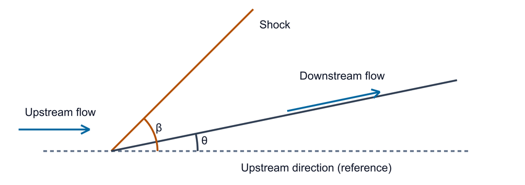

Original shock and flow-angle schematic

## 23.6 Two roots and the attached limit

For fixed upstream Mach and gamma, deflection is zero at both the Mach angle and 90°. Between them it reaches a maximum. For a positive deflection below that maximum, the smaller shock angle is the weak branch and the larger angle is the strong branch. They are distinct states with different compression and entropy production, not two numerical approximations to one state.

A weak oblique shock often leaves supersonic downstream flow, but weakness does not guarantee downstream Mach above one near the attachment limit. Selecting weak solely because a subsequent component requires supersonic flow is insufficient; inspect the actual downstream result. The surrounding flow and downstream conditions determine which physical configuration can occur. This isolated component does not solve that global selection problem.

The App maximizes the angle relation over the physical interval, then brackets the requested branch on the corresponding side of the maximum. It uses bounded golden-section search for the peak and bisection for the root. A requested deflection above the maximum is refused; a detached-shock substitute is not returned. A small angular tolerance merges the roots at the computed peak.

At exactly zero deflection, weak returns the unchanged Mach-wave limit with all property ratios one. Strong returns the normal-shock state at 90°. This explicit distinction matters even though the specified turning angle is identical. Angles in the mathematical routines are radians; the App’s displayed deflection and shock angles are degrees.

## 23.7 Original weak–strong comparison

Choose upstream Mach 2 and gamma 1.4. Select a 45° shock angle to construct a convenient weak-branch teaching case. Substitution into the angle relation gives deflection 14.743562836°. Its normal upstream Mach is $\sqrt2$, so the pressure ratio is 13/6, density ratio 12/7 and temperature ratio 91/72. Downstream Mach is 1.456323838 and total-pressure recovery 0.954577001.

Solving the same angle relation on its larger-angle branch gives shock angle 80.055319827°. The strong result has downstream Mach 0.641200943, pressure ratio 4.360819743, density ratio 2.621888917, temperature ratio 1.663235888 and total-pressure recovery 0.734902406.

Both states turn the flow through the same angle and satisfy the same conservation laws. The strong shock produces more static compression and more stagnation-pressure loss. Using the full upstream Mach 2 in a normal-shock formula for the weak case would wrongly predict a pressure ratio 4.5 instead of 2.166666667: the normal component, not the full velocity, drives the compression.

These are direct arithmetic and a scalar angle-root calculation for an original example. They are not generated by calling the App or presented as a measured inlet dataset.

## 23.8 Interpreting component outputs

The reported pressure, temperature and density ratios are downstream divided by upstream. To recover dimensional states, multiply them by compatible upstream static values. Total-pressure recovery multiplies upstream total pressure. Static and total ratios must not be interchanged.

The normal and oblique modes do not determine capture area, inlet drag, wall heat transfer or downstream combustor compatibility. Several isolated shock calculations can explain a proposed compression sequence, but they do not automatically establish a self-consistent installed inlet. Reflections, boundary-layer interactions and detached structures require additional closure.

Finally, constant gamma is an explicit assumption. A high predicted temperature is a reason to examine its applicability, not evidence that equilibrium chemistry has already been included. The result is an ideal jump across the selected compressive branch, with the irreversible loss that follows from those assumptions.

# 24. Friction, heating and quasi-one-dimensional flow

Friction and heat addition can both drive compressible flow toward a sonic limit, but they do not conserve the same quantities. Fanno flow preserves total enthalpy while wall drag removes axial momentum. Rayleigh flow preserves momentum flux while external heating changes total enthalpy. The common appearance of choking does not make these models interchangeable.

ThrustOne exposes each idealized component and a more general quasi-one-dimensional segment calculation. The special cases provide useful physical reference paths; the segment calculation also admits area variation and mass injection. Its additional terms must be interpreted with their own units and control-volume conventions.

## 24.1 Fanno assumptions and wall force

Consider steady flow in a constant-area duct with no heat addition, shaft work or mass injection. For fixed gas composition and constant heat capacities,

$$\dot m=\rho VA=\text{constant},\qquad
c_pT+V^2/2=c_pT_t=\text{constant}.$$

The differential momentum balance is

$$dp+\rho V\,dV=-\frac{f_D}{D}\frac{\rho V^2}{2}\,dx.$$

Here $f_D$ is the Darcy friction factor and $D$ the duct diameter, or the compatible hydraulic diameter for the intended model. The Darcy convention satisfies $f_D=4f_F$, where $f_F$ is the Fanning factor. Entering a Fanning value into a Darcy field underestimates the specified friction parameter by a factor of four.

The App’s isolated Fanno input is the product $f_DL/D$. It does not infer friction factor from Reynolds number or roughness. A fitted or estimated factor must therefore be supplied consistently with its convention and intended regime.

## 24.2 Deriving the remaining choking length

Continuity gives $d\rho/\rho=-dV/V$, and the ideal-gas law gives $dp/p=dT/T-dV/V$. Constant total enthalpy supplies $c_p\,dT=-V\,dV$. Substitution into momentum yields

$$(1-M^2)\frac{dV}{V}=\frac{\gamma M^2}{2}\frac{f_D\,dx}{D}.$$

Thus wall friction accelerates subsonic flow and decelerates supersonic flow under these assumptions. Both move toward Mach one. Friction does not necessarily reduce local velocity; its momentum loss combines with changes in pressure and density.

Since $M=V/\sqrt{\gamma RT}$, the energy relation gives

$$\frac{dM}{M}=\left[1+\frac{\gamma-1}{2}M^2\right]\frac{dV}{V}.$$

Eliminating velocity and integrating to the sonic state produces

$$\mathcal F(M)=\frac{1-M^2}{\gamma M^2}
+\frac{\gamma+1}{2\gamma}\ln
\left[\frac{(\gamma+1)M^2}{2+(\gamma-1)M^2}\right].$$

This is the remaining dimensionless friction length to choking. For a segment,

$$\frac{f_DL}{D}=\mathcal F(M_1)-\mathcal F(M_2).$$

The App finds $M_2$ on the same side of Mach one as the inlet. A prescribed friction length larger than the available value is rejected. It does not cross the sonic point by switching branches. At the choking limit it returns Mach one within its numerical tolerance; zero friction leaves the state unchanged.

## 24.3 Fanno static and total ratios

A star denotes the sonic state on the same Fanno line. Constant total temperature and continuity give

$$\frac{T}{T^*}=\frac{\gamma+1}{2+(\gamma-1)M^2},\qquad
\frac{p}{p^*}=\frac{1}{M}\sqrt{\frac{\gamma+1}{2+(\gamma-1)M^2}},$$

$$\frac{\rho}{\rho^*}=\frac{1}{M}\sqrt{\frac{2+(\gamma-1)M^2}{\gamma+1}}.$$

Isentropically stagnating each local state yields

$$\frac{p_t}{p_t^*}=\frac{1}{M}
\left[\frac{2+(\gamma-1)M^2}{\gamma+1}\right]^{\frac{\gamma+1}{2(\gamma-1)}}.$$

The ratio between states2 and 1 is obtained by dividing their respective starred expressions. The starred quantities are normalization references, not an assertion that the requested segment actually reaches choking. Total pressure decreases downstream with positive friction while total temperature stays constant.

## 24.4 Original friction-length example

For $\gamma=1.4$, choose a supersonic segment from Mach 2 to Mach 1.5. Direct evaluation gives $\mathcal F(2)=0.304996503$ and $\mathcal F(1.5)=0.136050217$. The required Darcy friction length is 0.168946285.

For an illustrative supplied $f_D=0.02$, this corresponds to $L/D=8.44731426$. The total available distance to choking from the same inlet is $L^*/D=15.2498251$. A request for $f_DL/D=0.4$ exceeds that capacity and must be refused under the fixed inlet conditions.

The Mach numbers and friction factor here are teaching values. The arithmetic demonstrates the component closure; it does not establish an experimentally appropriate friction factor or a real duct’s flow capacity.

## 24.5 Rayleigh mass and momentum constraints

Rayleigh flow instead has constant area, no wall friction and no mass injection, but permits heat transfer. Mass and momentum conservation imply

$$\rho V=j=\text{constant},\qquad
p+\rho V^2=p(1+\gamma M^2)=\text{constant}.$$

Energy changes according to $q=c_p(T_{t2}-T_{t1})$, with $q$ in J/kg. The isolated App component specifies the ratio of downstream to upstream total temperature. It does not obtain this heat from a reacting fuel mixture.

Using the sonic state on the same Rayleigh line as reference gives

$$\frac{p}{p^*}=\frac{1+\gamma}{1+\gamma M^2},\qquad
\frac{T}{T^*}=\frac{(1+\gamma)^2M^2}{(1+\gamma M^2)^2}.$$

Combining static and total temperature relations gives

$$\mathcal R(M)=\frac{T_t}{T_t^*}
=\frac{(1+\gamma)M^2[2+(\gamma-1)M^2]}{(1+\gamma M^2)^2}.$$

If the specified total-temperature ratio is $\tau_q$, the downstream target is $\mathcal R(M_2)=\tau_q\mathcal R(M_1)$. Its maximum is one at the sonic state. Heating raises the target toward that maximum; the solver rejects a target above it rather than continuing through thermal choking.

## 24.6 Heating does not imply monotonic static temperature

Positive heat raises total temperature, but static temperature also reflects changing kinetic energy. Differentiating the starred static-temperature expression shows that its maximum occurs at $M=1/\sqrt\gamma$, rather than at Mach one. A subsonic stream approaching choking can therefore have increasing total temperature while static temperature falls over the final part of the path.

The App selects the downstream Rayleigh root on the branch implied by upstream Mach. An exactly sonic inlet is assigned to the subsonic search branch for subsequent cooling. This is a numerical branch convention, not a general physical selection rule at a sonic junction.

On the supersonic branch, $\mathcal R(M)$ approaches $1-1/\gamma^2$ as Mach tends to infinity. Sufficiently strong cooling can request a target below that limiting value, so no finite supersonic state exists on the selected line. The current bounded search then refuses to establish a root; positivity of the requested temperature ratio alone does not ensure a solution.

## 24.7 Original thermal-choking example

For $\gamma=1.4$ and upstream Mach 2, $\mathcal R(M_1)=0.793388430$. A downstream Mach 1.5 corresponds to 0.909275657, requiring total-temperature ratio1.146066192. If the inlet total temperature were 1000 K, the target would be 1146.066192 K, with heat per mass $146.066192c_p$ J/kg when $c_p$ is entered in J/(kg K).

The largest supported heating ratio on this line is $1/\mathcal R(2)=1.260416667$. A ratio1.3 therefore crosses the thermal limit. That input must not be interpreted as a completed segment with a chosen downstream subsonic branch. These values are direct analytical arithmetic, not App-generated validation data.

## 24.8 General segment inputs and units

The quasi-one-dimensional solver advances static pressure $p$, temperature $T$, axial velocity $V$, mass flow $\dot m$ and area $A$ along $x$. The inlet must satisfy $\dot m=\rho VA$; these five supplied quantities are not independent. A helper can synchronize mass flow from the other state inputs, but the solver itself rejects an inconsistent inlet rather than silently replacing it.

Each segment specifies positive length and exit area. Area varies linearly from the area at that segment’s entrance, so $A'=(A_{out}-A_{in})/L$. The following distributed sources are constant inputs within the segment:

| Quantity | Meaning | Units |
| --- | --- | --- |
| $Q'$ | External heat supplied per unit axial length | W/m |
| $q_m$ | Injected mass flow per unit axial length | kg/(s m) |
| $h_{tj}$ | Total specific enthalpy of injected material | J/kg |
| $V_j$ | Axial injection velocity | m/s |
| $f_D$ | Darcy wall-friction factor | Dimensionless |

Heat per length is a power density along the duct, not heat per unit gas mass. Its integral over length is watts; dividing by an appropriate mass flow produces a specific-energy change. When mass is injected, that mass flow changes along the segment and cannot be treated as a single fixed denominator without accounting for energy carried by the injection.

The solver uses the circular equivalent diameter $D=2\sqrt{A/\pi}$ for wall drag. It does not accept an independent wetted perimeter or arbitrary-section hydraulic diameter. A rectangular or annular duct interpreted through this area-only diameter is therefore an additional approximation.

## 24.9 Mass, momentum and energy with injection

Mass conservation is

$$\dot m'=q_m.$$

For momentum, include injected axial momentum, pressure force on a changing-area wall, and wall drag. The flux form is

$$(pA+\dot mV)'=pA'+q_mV_j-F'_w,
\qquad
F'_w=\frac{f_D\rho V^2A}{2D}.$$

Expanding the derivative and cancelling $pA'$ yields

$$Ap'+\dot mV'=q_m(V_j-V)-F'_w\equiv F'.$$

The $-q_mV$ term is essential: added mass must acquire the stream velocity. A zero axial injection velocity does not mean zero momentum effect. The quantity $F'$ is an effective force per length, in N/m, rather than the total force on the engine.

The total-enthalpy flux balance is

$$(\dot m h_t)'=Q'+q_mh_{tj},\qquad h_t=h+V^2/2.$$

Using $\dot m'=q_m$ gives

$$\dot m h_t'=Q'+q_m(h_{tj}-h_t)\equiv Q'_{eff}.$$

Injection can increase total energy flux while reducing the stream’s specific total enthalpy if the added material has lower $h_{tj}$. This is dilution, not energy destruction. For constant composition, $dh=c_p(T)dT$, so

$$c_pT'+VV'=Q'_{eff}/\dot m.$$

No chemical source is introduced by calling the injection fuel. A different species inventory requires a composition-aware mixing or reacting model, developed in Chapter29.

## 24.10 The velocity differential equation

Differentiate continuity in logarithmic form with fixed gas constant:

$$\frac{q_m}{\dot m}=\frac{p'}p-\frac{T'}T+\frac{V'}V+\frac{A'}A.$$

Substitute $p'=(F'-\dot mV')/A$ and $T'=(Q'_{eff}/\dot m-VV')/c_p$. Collecting velocity terms gives

$$V'=\frac{V}{1-M^2}
\left[\frac{q_m}{\dot m}-\frac{A'}A-
\frac{F'}{Ap}+\frac{Q'_{eff}}{\dot m c_pT}\right].$$

Every bracketed term has units of inverse length. The factor $1-M^2$ reveals the sonic singularity of this formulation. A numerator that happens to approach zero does not authorize the current solver to construct a transonic continuation; that would require a separate critical-point compatibility treatment.

With no sources, the relation reduces to $(1-M^2)dV/V=-dA/A$. A convergent passage accelerates subsonic flow; a divergent passage accelerates supersonic flow. With constant area, no injection and no heat, the wall-force term recovers Fanno flow. With constant area, no injection and no drag, the heat term recovers Rayleigh flow. These reductions identify meaningful comparisons without pretending that the three numerical interfaces have identical stopping behavior.

## 24.11 Original injection bookkeeping example

Take an illustrative inlet mass flow 2 kg/s and total specific enthalpy 400 kJ/kg. A one-metre segment supplies 10 kW/m external heat and 0.2 kg/(s m) injection with total enthalpy 300 kJ/kg. The exit mass flow must be 2.2 kg/s. The inlet energy flux is 800 kW; external heat adds10 kW and injection adds60 kW. Therefore any completed adiabatic-wall calculation with those declared sources must have

$$h_{t,out}=\frac{800+10+60}{2.2}
=395.454545\ \mathrm{kJ/kg}.$$

Total energy flux increases while specific total enthalpy decreases. Adding10 kJ/kg directly to the inlet enthalpy would be wrong: the supplied heat has different units, and the added mass carries its own energy.

This is a necessary flux balance, not a complete outlet-state solution. Pressure, temperature and velocity still depend on area, momentum injection and the selected flow branch. In particular, changing $V_j$ at fixed injection total enthalpy changes injected static enthalpy and the momentum balance. The same total-energy target can therefore accompany different admissible outlet states.

## 24.12 Property and composition restrictions

The constant-property variant uses supplied gamma and gas constant, with $h=c_pT$. Its injection total enthalpy must be nonnegative. The frozen NASA9 variant instead evaluates $c_p(T)$, formation-inclusive enthalpy and frozen sound speed from one fixed mixture; its gas constant remains fixed because composition does not evolve.

Active injection with a separately specified injection composition is rejected in this solver. The frozen calculation cannot silently combine different compositions while keeping one mixture property law. For same-composition frozen injection, the model checks that $h_{tj}-V_j^2/2$ can be inverted to a supported static temperature. Negative formation-inclusive total enthalpy is not automatically invalid in that convention.

External heat can be negative to represent cooling, and injection velocity is a signed axial quantity. Injected mass rate and friction factor must be nonnegative. These input domains do not make the model a resolved injector calculation: no penetration, mixing length or transverse momentum field is predicted.

## 24.13 Integration and sonic stopping

The App applies a fixed-step fourth-order Runge–Kutta method within each segment, with at most 10000 total requested steps. It preserves the subsonic or supersonic side selected by the initial Mach. Intermediate and candidate states must remain finite and positive, and $|1-M^2|$ must exceed $10^{-4}$.

If a step approaches that sonic exclusion region, crosses branches, produces an invalid state or exceeds its conservation-residual criteria, the solver returns the previous accepted points with `completed=false` and a stop reason. It does not append a synthetic Mach-one endpoint or adaptively locate the exact choking coordinate. The last plotted position is therefore a retained valid station, not necessarily the true critical station.

Inlet continuity is checked to a tighter relative tolerance than accepted downstream steps. Frozen-property steps also check integrated energy flux against accumulated heat and injection enthalpy. These checks expose gross inconsistency; they do not replace an accuracy estimate for the spatial discretization. A smaller step can resolve a numerical difficulty but cannot create a physically missing branch beyond choking.

The isolated Fanno component can return its analytic sonic endpoint, whereas this general differential solver stops short of its singularity. The Rayleigh component may return a numerical state close to the thermal limit. Those endpoint differences must be respected when comparing results. Agreement should be assessed at compatible pre-sonic states with the same gas, area and source conventions.

A completed segment supplies a one-dimensional state history under these assumptions. It does not provide engine thrust by itself, infer a shock train, or guarantee that downstream back pressure can support the computed branch. The subsequent full-engine chapters add their own inlet, combustor and nozzle closures around these local balances.

# 25. Ramjet cycle and complete subsonic flowpath

A ramjet uses incoming flight motion to provide compression before heat addition. It has no shaft-driven compressor or turbine in the ideal cycle considered here. The inlet slows the captured stream, the combustor raises its total enthalpy, and the nozzle accelerates the exhaust. Net thrust is the difference between exhaust force and captured-air momentum, with any nozzle pressure term retained.

ThrustOne offers a design-point cycle and a spatial subsonic-combustion flowpath. The first specifies a combustor outlet total temperature and pressure-loss factors. The second integrates prescribed area, heat, drag and injection sources before attaching a pressure-specified nozzle. They answer different questions and should not be described as interchangeable ways of solving the same fixed hardware.

## 25.1 Inlet total conditions

For ambient static temperature $T_0$, pressure $p_0$, flight Mach $M_0$ and cold-gas gamma $\gamma_c$,

$$\tau_r=1+\frac{\gamma_c-1}{2}M_0^2,\qquad
T_{t2}=T_0\tau_r,\qquad
p_{t2}=p_0\tau_r^{\gamma_c/(\gamma_c-1)}\pi_d.$$

The total-pressure recovery $\pi_d$ represents inlet loss. In the nonideal design-point mode it combines the supplied recovery with the empirical Mach-dependent factor discussed in Chapter 4. The ideal selection uses unity recovery. Neither option determines a shock position, capture geometry or inlet starting margin.

At zero flight Mach, an ideal inlet provides no ram pressure rise. A conventional ramjet therefore cannot obtain its normal propulsion cycle merely by adding heat to static ambient air in this ideal pressure chain. The current cycle also requires a positive nozzle pressure ratio above one and positive net specific thrust.

## 25.2 Combustor fuel balance

Let $T_{t4}$ be the prescribed combustor exit total temperature. On a unit captured-air mass basis, with effective cold and hot heat capacities, the nonideal energy balance is

$$c_{pc}T_{t2}+\eta_b fQ=(1+f)c_{ph}T_{t4}.$$

Solving for fuel-to-air mass ratio gives

$$f=\frac{c_{ph}T_{t4}-c_{pc}T_{t2}}
{\eta_bQ-c_{ph}T_{t4}}.$$

The denominator must remain positive, and the numerator cannot require negative fuel. This is a prescribed effective sensible-enthalpy and heating-value model. It does not infer equilibrium species or gaseous feed enthalpies from chemical data.

The ideal selection uses one cold-gas property set throughout, unity efficiencies and pressure recoveries, and neglects fuel mass in exhaust momentum. Its fuel balance becomes

$$f_i=\frac{c_p(T_{t4}-T_{t2})}{Q}.$$

Fuel energy is retained while its added exhaust mass is neglected. This is a deliberate cycle approximation, not an exact finite-fuel mass balance. The ideal mode also requires complete expansion to ambient pressure.

## 25.3 Specified-pressure nozzle and thrust

Let $r_e=p_0/p_9$. With combustor and nozzle pressure ratios $\pi_b$ and $\pi_n$,

$$\frac{p_{t9}}{p_9}=r_e\tau_r^{\gamma_c/(\gamma_c-1)}\pi_d\pi_b\pi_n.$$

The nozzle uses the hot-gas gamma and gas constant $R_h=c_{ph}(\gamma_h-1)/\gamma_h$ to recover static temperature and velocity:

$$T_9=T_{t4}(p_9/p_{t9})^{(\gamma_h-1)/\gamma_h},\qquad
V_9=\sqrt{2c_{ph}(T_{t4}-T_9)}.$$

For the nonideal cycle, net thrust per unit captured-air flow is

$$F_s=(1+f)V_9-V_0+
\frac{(1+f)R_hT_9}{V_9}(1-r_e).$$

The last term follows by eliminating exit area through continuity. Positive excess exit pressure adds thrust; overexpansion subtracts it. The nozzle geometry is not supplied or solved as a fixed-area back-pressure problem. A prescribed exit pressure can imply a supersonic expansion without proving that an installed nozzle sustains that branch.

Specific fuel consumption is $f/F_s$. An optional air mass flow converts specific thrust to net force. Overall efficiency is thrust power divided by fuel chemical power when fuel is positive; kinetic-decomposition thermal and propulsive efficiencies are reported only for full expansion.

## 25.4 Ideal limiting relation

With one gas, unity recoveries and full expansion, the inlet and nozzle pressure ratios cancel so that $M_9=M_0$. Nevertheless exhaust velocity exceeds flight velocity if heat has raised the nozzle temperature. Specifically,

$$T_9=T_{t4}/\tau_r,\qquad
\frac{V_9}{V_0}=\sqrt{\frac{T_{t4}}{T_0\tau_r}},$$

and, neglecting fuel mass,

$$F_{s,i}=V_0\left[\sqrt{\frac{T_{t4}}{T_0\tau_r}}-1\right].$$

Equal inlet and exit Mach numbers do not imply equal velocities because their sound speeds differ. Positive heating requires $T_{t4}>T_0\tau_r$. Increasing flight Mach at fixed maximum combustor temperature eventually reduces the available temperature rise; a larger ram pressure rise is not an unlimited performance benefit.

## 25.5 Original ideal-cycle example

Choose an illustrative constant gas with $\gamma=1.4$, $c_p=1000$ J/(kg K), ambient temperature 250 K and flight Mach2. Set combustor total temperature 1800 K and heating value40 MJ/kg. These inputs are an ideal teaching case, not a fuel-property recommendation.

The inlet temperature factor is 1.8 and its total temperature 450 K. The gas constant is 285.714286 J/(kg K), giving ambient sound speed316.227766 m/s and flight velocity632.455532 m/s. Full ideal expansion gives exit temperature 1000 K and exit Mach2, so exhaust speed1264.911064 m/s.

The ideal specific thrust is 632.455532 N per kg/s of captured air. The approximate fuel ratio is $1000(1800-450)/(40\times10^6)=0.03375$. These values follow directly from the limiting equations. Restoring fuel mass, different hot-gas properties or pressure losses changes the model and therefore the result; it should not be treated as a rounding correction to this ideal calculation.

## 25.6 A captured stream and a subsonic combustor inlet

The spatial full-flowpath mode requires a supersonic freestream and a positive capture area. It first computes captured air flow,

$$\dot m_a=\frac{p_0}{RT_0}V_0A_{capture},\qquad
V_0=M_0\sqrt{\gamma RT_0}.$$

Its inlet total temperature follows ram heating, and total pressure is multiplied by the directly supplied recovery. Unlike the nonideal design-point cycle, this inlet does not add the empirical Mach recovery factor. Identical numerical recovery inputs therefore need not describe identical recovered total pressures in the two modes.

The selected inlet closure specifies exit Mach, static temperature, static pressure, or an area constraint with recovery. A temperature input gives $M_i^2=2(T_t/T_i-1)/(\gamma-1)$; a pressure input gives the corresponding isentropic Mach relation. Given Mach,

$$T_i=\frac{T_t}{1+(\gamma-1)M_i^2/2},\quad
p_i=p_t(T_i/T_t)^{\gamma/(\gamma-1)},\quad
A_i=\frac{\dot m_aRT_i}{p_iV_i}.$$

The inlet must decelerate the freestream into a positive subsonic Mach and produce static pressure no lower than ambient. No shock sequence is reconstructed to prove how that specified recovery and state are achieved.

For contraction/recovery closures, the area is capture area divided by contraction ratio. The solver checks its sonic mass-flow capacity, then selects the subsonic root compatible with captured flow and recovered total conditions. In the current implementation, both named closure routes use the same supplied contraction and recovery relation; recovery is not inferred from a separate shock solution.

## 25.7 Distributed heat and injected mass

The combustor is one or more constant-property segments governed by Chapter 24’s equations. They permit area change, Darcy drag, external heat per length and injected mass carrying specified momentum and total enthalpy. The calculation follows the subsonic branch and refuses to integrate through its sonic singularity.

This is not a resolved combustion-chemistry calculation. A heat input in W/m is an imposed energy source; a mass source in kg/(s m) is an imposed material addition. Neither alone supplies a fuel heating value or establishes combustion efficiency. If the user represents fuel through both mass injection and heat, the chosen conventions must avoid counting its chemical energy twice.

In particular, the design-point fuel ratio from Section 25.2 is not automatically transferred to this spatial model. The full-flowpath output has captured and exit mass flows, but does not report a chemically inferred fuel-to-air ratio or TSFC. An energy residual checks the supplied flux balance, not combustion completeness.

If the combustor stops early, the returned exit fields describe its last accepted point. The downstream nozzle is not calculated and no completed full-engine thrust is supplied. More heat cannot be accommodated merely by allowing a plotted line to jump from a subsonic to a supersonic combustor state.

## 25.8 A pressure-specified nozzle after the combustor

At a completed combustor exit, the wrapper reconstructs total conditions from its static state:

$$T_{tn}=T_b+V_b^2/(2c_p),\qquad
p_{tn}=p_b[1+(\gamma-1)M_b^2/2]^{\gamma/(\gamma-1)}.$$

The nozzle recovery reduces total pressure while total temperature is retained. The specified ambient-to-exit pressure ratio determines $p_e$. The shared nozzle component then obtains exit temperature and velocity from the available enthalpy drop. Finally,

$$A_e=\frac{\dot m_eRT_e}{p_eV_e}.$$

Exit area is a result. The full ramjet route ignores separately supplied nozzle segments and uses this pressure closure instead. A nozzle length input positions the final station but does not determine the area solution or internal flow distribution.

Only inlet and exit nozzle states are reported in a separate station profile. Connecting them visually does not turn them into a solved continuous nozzle. A supersonic exit would require a suitable throat and expansion in hardware, but the current wrapper does not construct that throat or solve its back-pressure operating regimes.

## 25.9 Original nozzle and momentum example

Consider a constructed nozzle interface with total temperature 1000 K, total pressure 200 kPa before a recovery of 0.9, mass flow 2 kg/s, $\gamma=1.4$, $R=300$ J/(kg K), and exit pressure 100 kPa equal to ambient. The available nozzle total pressure is 180 kPa and $c_p=1050$ J/(kg K).

The isentropic endpoint is $T_e=845.405363$ K, $V_e=569.779552$ m/s and $M_e=0.956202148$. Continuity yields $A_e=0.008902447$ m². This example deliberately gives a subsonic nozzle exit: a ramjet nozzle result is not forced to be supersonic when the prescribed pressure ratio is below the critical ratio.

Gross thrust is 1139.559104 N. If the upstream bookkeeping gives captured air flow 1.8 kg/s at 500 m/s, captured momentum is 900 N and net thrust is 239.559104 N. The 0.2 kg/s difference between exit and captured flow would need to be supplied consistently by the upstream mass sources. These selected interface values illustrate endpoint and force accounting; they do not claim a fully integrated combustor history.

The nozzle area cannot be prescribed independently while retaining all these endpoint quantities. Choosing a different area would require changing a pressure, velocity, mass-flow or upstream state constraint. That is why this model is described as pressure-specified rather than fixed-geometry ambient matching.

## 25.10 Full-flowpath force and diagnostics

The completed engine uses

$$F=\dot m_eV_e-\dot m_aV_0+(p_e-p_0)A_e,
\qquad F_s=F/\dot m_a.$$

Captured air flow remains the denominator even when injection increases exit mass. Gross thrust omits the captured-momentum subtraction. The current full-flowpath routine checks finiteness but does not require positive net thrust, unlike the design-point cycle. A finite negative result represents drag under the declared model, not useful propulsion.

The retained flow profile ends at the combustor. Its mass-flow field and final static state remain useful for interpreting the nozzle inlet. The final overall exit fields are then replaced by the nozzle result. The energy residual retained from the upstream calculation belongs to the integrated combustor source balance, not to a separately integrated nozzle flowfield.

Neither capture area nor a specified recovery predicts spillage, installation drag, inlet unstart or shock–boundary-layer interaction. Nozzle pressure specification likewise does not prove that the combustor and an installed nozzle can share a stable operating point. The calculation connects a bounded subsonic source-term flowpath to a thermodynamically consistent endpoint expansion; that is the scope of the completed result.

# 26. Frozen variable-property flow and state reconstruction

A flow state can be specified through temperature and pressure, density and velocity, or conserved flux quantities. These forms describe the same physical variables only when they share a composition, an enthalpy reference and a branch. ThrustOne’s frozen variable-property flow mode reconstructs an inlet from seven input forms, then advances that fixed composition through the source-term equations of Chapter24.

Frozen composition does not require constant heat capacity. NASA9 enthalpy, heat capacity and sound speed are evaluated at the local temperature. The distinction is essential for the reconstruction from momentum and total enthalpy, where an incorrect reference energy can select an entirely different state or leave no admissible root.

## 26.1 Seven forms, one physical inlet

The supported forms are temperature–pressure–Mach, temperature–pressure–velocity, temperature–density–Mach, temperature–density–velocity, pressure–density–Mach, pressure–density–velocity, and momentum/energy flux reconstruction. Every form also requires a positive area and a declared mixture.

For the first six, the ideal-gas relation closes the missing thermodynamic variable:

$$p=\rho RT,\qquad T=p/(\rho R).$$

A supplied velocity is used directly. A supplied Mach number instead gives $V=Ma_f(T)$, with $a_f$ obtained from the frozen mixture properties. Finally,

$$\dot m=\frac{pVA}{RT}.$$

Mass flow is an output of these forms. It is not another independent condition that can be chosen arbitrarily alongside pressure, temperature, velocity and area. The properties and reconstructed state must stay finite, positive and within their supported temperature range.

These are seven inlet representations, not seven chemical models or seven flow-regime predictions. Composition remains fixed after reconstruction unless a different, explicitly mixing or reacting mode is selected.

## 26.2 What F and G mean

The final input form supplies

$$F=pA+\dot mV,\qquad G=h+V^2/2,$$

along with mass flow, area and an explicit subsonic or supersonic branch. $F$ has units of newtons and is the pressure-plus-momentum flux at the selected plane. It is not net engine thrust. $G$ has units of J/kg and is total specific enthalpy, not energy flow in watts.

The associated energy flux is $\dot mG$. Subtracting incoming momentum and including external pressure forces is still necessary before a full control volume yields thrust. A positive $F$ therefore says nothing by itself about whether a complete engine produces positive propulsion.

NASA enthalpy includes formation reference energies. Consequently $G$ can legitimately be negative. The velocity contribution is nonnegative, but it need not exceed a negative mixture enthalpy. Rejecting every negative total enthalpy would remove physically representable states from this convention.

## 26.3 Reduce momentum to a velocity–temperature curve

Let $q_F=F/\dot m$, a quantity with units of m/s. Continuity gives $pA/\dot m=RT/V$. Substituting into the momentum definition yields

$$q_F=V+RT/V,\qquad T(V)=\frac{V(q_F-V)}R.$$

Positive temperature requires $0<V<q_F$. The temperature curve reaches its maximum $q_F^2/(4R)$ at $V=q_F/2$. If even that maximum is below the mixture’s minimum supported temperature, there is no admissible reconstruction.

For any admissible temperature, the two momentum-compatible velocities are

$$V_{\pm}=\frac{q_F\pm\sqrt{q_F^2-4RT}}2.$$

The low-speed expression is evaluated in the cancellation-resistant form

$$V_- =\frac{2RT/q_F}{1+\sqrt{1-4RT/q_F^2}},\qquad V_+=q_F-V_-.$$

These two momentum roots do not alone identify the requested flow state. They construct the allowable velocity intervals associated with the property’s temperature limits. Energy then selects roots within those intervals.

## 26.4 Energy closure and the sonic partition

Substitute the momentum temperature into total enthalpy:

$$E(V)=h[T(V)]+V^2/2-G=0.$$

The App evaluates mixture properties at each trial temperature, brackets roots and partitions the search around a frozen sonic point where needed. To see why that point is significant, differentiate at fixed composition:

$$E'(V)=c_p\frac{q_F-2V}{R}+V.$$

On the momentum curve, $q_F=V+RT/V$, so

$$E'(V)=\frac{c_pT}{V}-\frac{c_vV}{R}.$$

The stationary condition is $V^2=(c_p/c_v)RT=a_f^2$. The energy curve therefore turns at the frozen sonic state, separating the subsonic and supersonic branches. This gives a physical basis for the branch partition rather than treating two roots as an arbitrary numerical nuisance.

The current implementation accepts exactly one nonsonic root on the requested branch within the valid temperature domain. It excludes roots within its small sonic-Mach tolerance and rejects no-root or nonunique outcomes. It does not silently choose whichever root happens to be discovered first.

Once velocity is selected, pressure follows from

$$p=\frac{\dot mRT}{AV}.$$

Area controls dimensional pressure for this fixed $F/\dot m,G$ reconstruction. It does not change the velocity–temperature root when the composition and other flux inputs stay fixed.

## 26.5 Original two-root illustration

Use an analytical constant-property gas to make the roots transparent: $R=250$ J/(kg K), $c_p=1000$ J/(kg K), hence $\gamma=4/3$, with the deliberate reference $h=c_pT$. Set $q_F=1000$ m/s and $G=900000$ J/kg. This is a teaching limit, not an assertion that these energies use the NASA9 formation reference.

Substitution gives

$$G=4V(1000-V)+V^2/2=4000V-3.5V^2.$$

There are two roots. The low-speed state has velocity308.013016 m/s, temperature852.563991 K and Mach0.577784920. The high-speed state has velocity834.844127 m/s, temperature551.517642 K and Mach1.947091314.

For mass flow2 kg/s and area0.01 m², their pressures are138397.396899 Pa and33031.174530 Pa respectively. Both have $F=2000$ N and $G=900000$ J/kg. Flux values alone do not say which branch the user intends.

The two states can also be viewed as compatible constant-area adiabatic jump endpoints. Entropy direction would matter if interpreting them as a shock, but this reconstruction does not impose an upstream-to-downstream shock event. Its branch input selects a state, not an irreversible process connecting the roots.

These numbers were calculated directly from the quadratic. A NASA9 calculation must use its actual $h(T)$, including the reference term. Adding a constant enthalpy offset to both the property law and supplied $G$ preserves the state; changing only one of them does not.

## 26.6 Advancing the reconstructed state

The variable-property flow mode passes the inlet and fixed mixture to the same quasi-one-dimensional solver developed in Chapter24. Area, drag, external heat and same-composition mass injection can change the local state. The gas constant remains fixed; local heat capacity, enthalpy and sound speed vary with temperature.

A separately specified injection composition is not accepted with active injection in this frozen flow. Different-composition mixing belongs to the appropriate composition-aware mode. Similarly, an explicit heat source is not a finite-rate chemical mechanism. Renaming a segment combustor does not create species evolution.

At each accepted point, the profile includes static pressure, temperature, velocity, area, mass flow, Mach, heat capacity, gamma and specific enthalpy. The enthalpy field is static $h$; add $V^2/2$ to obtain $G$. Comparing that static field directly with an inlet total-enthalpy input would create a false apparent energy discrepancy.

## 26.7 Partial histories and energy diagnostics

The general solver retains the initial subsonic or supersonic side and stops before its sonic singularity or an invalid state. The frozen-flow wrapper reports the final accepted point even when `completed` is false. The exit fields then describe a partial segment, not the requested endpoint.

Its energy diagnostic is the dimensional flux difference

$$\mathcal E=\dot m_e(h_e+V_e^2/2)-\dot m_i(h_i+V_i^2/2)
-\int_0^{x_e}(Q'+q_mh_{tj})\,dx.$$

It has units of watts. For a partial history, the source integral includes only the length actually reached, including a partially completed segment. It must not include all the heat specified beyond the retained endpoint.

The wrapper exposes this value as `flow_energy_residual`; it is not the same normalized quantity as the general solver’s internal relative checks. A small dimensional residual depends on the flow scale and does not certify chemistry, temporal response or an installed flowpath.

## 26.8 Choosing the appropriate frozen calculation

Use the standalone frozen nozzle of Chapter17 when the problem is an adiabatic, isentropic, sonic-or-supersonic expansion through nondecreasing area. That solver reconstructs states from conserved entropy and total enthalpy. Use the present source-term segment when heating, friction, general area change or permitted mass injection must be represented.

The nozzle can begin at a sonic throat. The general differential flow solver excludes its sonic singularity. A comparison that starts both calculations at exactly Mach one is therefore not a comparison of compatible numerical domains. Compare common nonsonic states and consistent source assumptions instead.

Neither calculation predicts a shock train, composition relaxation, cooling system or automatic transition between branches. Their common strength is explicit thermodynamic and flow accounting within a fixed-composition model, with the reference state and root choice made visible.

# 27. Calibrated variable-property inlets

An inlet model can conserve energy while requiring an empirical description of irreversibility. ThrustOne’s calibrated inlet uses one explicit reference state to set the relationship between entropy production and static-pressure rise. It then combines that relationship with frozen dry-air properties to reconstruct other compression states.

The word calibrated does not mean the App contains measured data for an unspecified inlet. The reference altitude, flight Mach, exit Mach and contraction ratio are user inputs. Their consistency and relevance determine what the resulting model represents. The calculation does not find shock locations, boundary layers, capture spillage or inlet starting limits.

## 27.1 The property and freestream model

The mixture is fixed at0.79 N2 and0.21 O2 by mole, using NASA9 properties. It does not react or dissociate as it heats. Its gas constant is constant, but heat capacity, enthalpy and frozen sound speed depend on temperature.

For an atmosphere state $T_0,p_0$,

$$V_0=M_0a_f(T_0),\quad
\rho_0=p_0/(RT_0),\quad
q_0=\rho_0V_0^2/2,$$

$$h_t=h(T_0)+V_0^2/2,\qquad s_0=s(T_0,p_0).$$

The supported geometric altitude range is0–70 km. The calculation uses its bundled atmosphere and property data, not measured weather. The actual flight state must be supersonic. Property-temperature limits can constrain high-energy cases even when altitude is within the declared range.

Three freestream input forms are available. Altitude and Mach directly determine the state. At specified altitude and dynamic pressure, Mach follows from $M_0=\sqrt{q_0/q_{M=1}}$, because the local thermodynamic state is fixed. At specified Mach and dynamic pressure, altitude is bracketed within the allowed atmosphere range and solved numerically. An unbracketed pressure request is rejected rather than assigned an extrapolated altitude.

## 27.2 Recovering the reference exit

Apply the same freestream construction to the reference inputs, denoted by subscript R. Given reference exit Mach $M_{eR}$, find its static temperature from

$$h(T_{eR})+\frac{M_{eR}^2a_f(T_{eR})^2}{2}=h_{tR}.$$

The reference exit Mach must be positive and lower than the reference flight Mach. Temperature is bracketed between freestream temperature and the stagnation temperature obtained by enthalpy inversion. This avoids treating a locally evaluated gamma as a global calorically perfect relation.

Define contraction ratio $C=A_{capture}/A_e$. Continuity implies

$$\rho_eV_e=C\rho_0V_0.$$

Thus reference pressure is recovered from

$$p_{eR}=C_R\rho_{0R}V_{0R}\frac{RT_{eR}}{V_{eR}}.$$

Reference contraction must exceed one and this reconstructed pressure must exceed reference ambient pressure. The entropy change is then evaluated from the two actual property states.

## 27.3 The calibrated entropy law

The implemented relationship is

$$\Delta s=K\ln(p_e/p_0),\qquad
K=\frac{s_{eR}-s_{0R}}{\ln(p_{eR}/p_{0R})}.$$

The coefficient $K$ has units of J/(kg K), not a dimensionless efficiency. The model requires a finite positive coefficient, so a reversible reference with zero entropy change is outside this lossy calibration interface. A negative-entropy reference is rejected.

This law is a supplied reference approximation. It is not derived from a universal shock train or wall-friction correlation. One reference fixes one parameter; it does not demonstrate accuracy over all Mach numbers, altitudes or contractions. Changing the reference changes the model even if the current flight inputs stay identical.

The calibration and the current-flow closure are distinct steps. The App reconstructs the coefficient from the saved reference each time, then applies it to the selected current state. It does not overwrite the reference with each newly computed point.

## 27.4 Deriving the current compression path

At a trial exit temperature, write the ideal-gas entropy pressure correction for the same frozen mixture:

$$s(T,p_e)=s(T,p_0)-R\ln(p_e/p_0).$$

Set this equal to $s_0+K\ln(p_e/p_0)$, obtaining

$$\ln(p_e/p_0)=\frac{s(T,p_0)-s_0}{R+K}.$$

Energy and continuity then give

$$V_e=\sqrt{2[h_t-h(T)]},\quad
M_e=V_e/a_f(T),\quad
C=\frac{\rho_eV_e}{\rho_0V_0}.$$

The accepted state must have temperature above freestream temperature, positive remaining kinetic energy and pressure above freestream pressure. Those conditions describe adiabatic deceleration and compression on the modeled path. They do not determine the physical devices or shocks producing it.

Absolute capture area is absent from this independent calculation: continuity provides an area ratio through mass fluxes. A dimensional mass flow requires an additional capture-area scale outside this mode.

## 27.5 Total-pressure recovery without a local-gamma power law

Because total enthalpy and composition are unchanged, isentropically stagnating the upstream and downstream states gives the same total temperature. Their entropy difference therefore satisfies

$$\Delta s=-R\ln(p_{te}/p_{t0}),\qquad
\pi_d=\exp(-\Delta s/R).$$

Together with the calibrated law,

$$\pi_d=(p_e/p_0)^{-K/R}.$$

This power describes the fitted entropy relation, not a calorically perfect static-to-total formula. Static pressure can increase while total-pressure recovery falls, consistent with irreversible compression.

As an original dimensionless illustration, suppose $K/R=0.1$ and the chosen path state has static-pressure ratio10. Then $\Delta s/R=0.1\ln10$ and recovery is $10^{-0.1}\approx0.794328$. Conversely, a recovery of0.8 requires pressure ratio $0.8^{-10}\approx9.313226$ under this particular calibration. These relationships alone do not establish that the corresponding temperature and kinetic energy are admissible for a given flight state; those closures must still be solved.

## 27.6 Five exit constraints

Exit Mach uses the energy inversion of Section27.2, followed by the calibrated pressure relation. Exit temperature directly selects a point on that path. Specified exit pressure sets its logarithmic pressure rise and obtains temperature by entropy inversion:

$$s(T,p_0)=s_0+(R+K)\ln(p_e/p_0).$$

Specified total-pressure recovery first gives

$$\ln(p_e/p_0)=-\frac{R}{K}\ln\pi_d,$$

then uses the same temperature inversion. This branch requires recovery strictly between zero and one. The lossless endpoint is not an accepted calibration limit merely because other inlet models permit unity recovery.

The fifth constraint is contraction ratio. It requires inversion of the computed mass-flux ratio $C(M_e)$. Multiple exits can satisfy the same contraction because velocity and density change in competing directions along the compression path. The root choice becomes part of the input, not an optional plotting preference.

## 27.7 Higher- and lower-Mach roots

For contraction inversion, the App samples candidate exit Mach values from0.05 to0.999 times flight Mach, detects sign-change brackets and refines the selected bracket. The higher-Mach choice takes the highest detected bracket; the lower-Mach choice takes the lowest. It reports the number of detected brackets.

Higher and lower are relative labels. They do not necessarily mean supersonic and subsonic. The returned Mach itself establishes that distinction. For directly specified exit temperature, pressure, Mach or recovery, the high/low selection is not used and `root_count` is set to one; it is not a survey of every possible inverse solution.

A root near a tangency can fail to produce a sign change in the sampled grid. Likewise, a root outside the scanned Mach interval is not discovered. The implementation rejects a contraction without distinguishable brackets rather than inventing a limiting solution. A reported root count therefore describes the search result, not a mathematical proof that no other roots exist in every possible domain.

## 27.8 Interpreting a result and a refusal

The energy residual describes $h_e+V_e^2/2-h_t$, in J/kg. Entropy change and recovered total-pressure ratio describe the calibrated irreversible path. Contraction is a mass-flux ratio. These quantities should not be relabeled thrust, captured mass flow or measured inlet efficiency.

An impossible reference can fail before the current-state calculation begins. A current pressure or recovery can require a temperature outside available property data or leave no positive kinetic energy. A contraction can fail the bracketing condition. Each refusal concerns a specific combination of assumptions and inputs; it does not prove that every physical inlet at that flight condition is impossible.

The fixed dry-air chemistry remains a major boundary at high temperatures. The mode does not automatically substitute equilibrium air, predict dissociation losses or match a reacting combustor. A full-engine calculation using this inlet adds further interface constraints, described in Chapter29. The independent result remains a reference-calibrated compression state with explicit thermodynamic and inverse-root assumptions.

# 28. Constant-property scramjet flowpaths

A scramjet retains supersonic flow through its modeled heat-addition region. This avoids requiring the entire captured stream to be decelerated to subsonic conditions, but it does not remove the coupling between heat, area, momentum and choking. Adding sufficient heat at fixed area can still drive the flow toward a sonic limit.

ThrustOne’s constant-property scramjet modes assemble the source-term equations of Chapter24 into a combustor, a nozzle, or a complete inlet–combustor–nozzle path. Their gas constant and gamma remain fixed. They do not solve chemical rates, molecular mixing or an automatic change to subsonic combustion.

## 28.1 Three boundaries for three questions

The combustor-only mode begins from an explicitly reconstructed static flow state and advances the combustor segments. The nozzle-only mode begins from its own reconstructed state and advances the nozzle segments. Neither has a freestream capture calculation from which to determine full-engine net thrust.

The full-engine mode first constructs a compressed supersonic inlet state from flight conditions and a specified total-pressure recovery. It then advances combustor segments followed by nozzle segments as one connected flowpath. The last accepted state of one segment becomes the initial state of the next.

```
Full engine:  freestream → prescribed inlet → source-term combustor → nozzle
Combustor:                         supplied inlet → combustor exit
Nozzle:                                                  supplied inlet → exit
```

At least one segment is required in the selected combined list. The code does not infer a missing physical component merely because the mode is named full engine. The actual supplied segment list determines what is integrated.

## 28.2 Supersonic inlet closure

For positive capture area and ambient state, captured air flow is $\dot m_a=\rho_0V_0A_{capture}$. Total temperature is obtained by ram heating; total pressure is multiplied by the directly supplied recovery. The inlet is adiabatic, so it retains total enthalpy while losing total pressure.

Exit Mach, temperature or pressure can specify a state as in Chapter25, but here the selected branch must remain supersonic and slower than the freestream. The static exit pressure must not fall below ambient. The implementation does not reconstruct oblique shocks to derive the specified loss.

For an area-contraction constraint, recovered total state and area determine the mass-flow curve. The sonic capacity must accommodate captured flow, and a decelerating supersonic root must exist between Mach one and flight Mach. Otherwise the input is refused. A physically possible subsonic root does not rescue this supersonic-flow mode.

The recovery-named and contraction-named closures share the same current area/recovery equation. This conventional inlet is separate from the NASA9 reference-calibrated model of Chapter27. Their property and loss laws must not be mixed without explicitly changing the model.

## 28.3 Heat addition and area compensation

In a constant-area segment with no injection or drag, Chapter24 gives

$$V'=\frac{V}{1-M^2}\frac{Q'}{\dot m c_pT}.$$

For supersonic flow, positive heat decreases velocity while increasing total enthalpy. Density, pressure and sound speed also change, driving Mach toward one. The added energy is not simply converted into immediate axial acceleration inside the combustor.

Area divergence contributes the term $-A'/A$ inside the same bracket. On the supersonic branch, divergence tends to accelerate the flow and can counter part of the heat-addition tendency. This is why area schedule and heat schedule must be considered together. It does not mean that arbitrary expansion can guarantee an acceptable combustor state: pressure, temperature, finite length and downstream conditions still constrain the result.

Darcy drag and mass injection add the forces and energy-dilution terms already derived in Chapter24. Injection with low axial velocity can reduce stream momentum even while its mass and total enthalpy increase the downstream fluxes. The fixed-property model does not infer those source values from a detailed injector or combustion mechanism.

## 28.4 What the nozzle accepts

Nozzle segments in the full-engine and nozzle-only modes must have zero heat source and zero mass injection. Their area variation and nonnegative Darcy friction remain available. Thus a nozzle can be adiabatic yet lose total pressure through drag. It should only be called isentropic when the relevant dissipative sources are absent.

The model does not impose monotonically increasing area on every constant-property nozzle segment. A decreasing-area supersonic segment decelerates the stream and may approach choking. The branch guard prevents continuation through the sonic region; it does not redesign the area schedule.

Unlike the full ramjet wrapper of Chapter25, this full scramjet integrates supplied nozzle segments. Exit pressure is an output of that integration. Ambient pressure is used in the final force balance but does not adjust the internal solution to match an installed nozzle back pressure. A mismatch is therefore not solved by relocating a shock or changing the inlet state.

## 28.5 Original energy and force bookkeeping

Take an illustrative completed path with captured air flow1 kg/s and no mass injection. If inlet total temperature is600 K, constant $c_p=1000$ J/(kg K), and the combustor receives200 kW total heat, outlet total enthalpy is800 kJ/kg. An adiabatic nozzle retains this total enthalpy. The actual exit temperature and velocity must still satisfy its momentum and geometry solution.

For a separate illustrative endpoint force calculation, let exit mass flow1.1 kg/s, velocity1200 m/s, exit pressure30 kPa, ambient pressure20 kPa and exit area0.02 m². Gross thrust is

$$F_g=1.1(1200)+(30000-20000)(0.02)=1520\ \mathrm N.$$

With captured air flow1 kg/s at900 m/s, net thrust is620 N. The additional0.1 kg/s must be represented by the upstream source bookkeeping; it is not automatically counted as a fuel species or assigned a heating value by this calculation.

These are transparent flux and force examples, not a claimed spatial solver run. They separate the energy constraint from the endpoint momentum accounting. A proposed endpoint must still be attainable through a completed flowpath before it can be interpreted as its prediction.

## 28.6 Incomplete histories are not completed engines

The general solver uses finite-step integration and retains the selected Mach branch. When a step enters its sonic exclusion region, becomes invalid or exceeds its conservation checks, it returns the previous valid history. The last state remains available for diagnosis, and `completed` is false.

The scramjet wrapper then omits gross and full-engine thrust. A pressure and velocity shown in the exit fields of such a result describe the retained stopping point, not the intended physical exit. Combining those fields manually with the originally requested exit area would produce an inconsistent force estimate.

The stop does not automatically mean the real engine changes to ramjet mode. A shock train, isolator response, combustor unstart or mode transition would require a different coupled flow solution. Increasing the integration resolution can address a discretization problem; it cannot authorize crossing a physically singular branch in this model.

## 28.7 Completed outputs and their conventions

On a completed path,

$$F_g=\dot m_eV_e+(p_e-p_a)A_e,
\qquad F=F_g-\dot m_aV_0.$$

The full-engine specific thrust uses captured air flow, even if injected mass increases exit flow. Component-only modes report gross exhaust force without a captured-air subtraction. This quantity is not the net axial force on the nozzle wall or a complete component control-volume force balance; its inlet momentum and pressure terms would also be needed for that interpretation.

The output energy residual compares inlet and exit total-enthalpy flux with integrated heat and injected total enthalpy. Its denominator scales with the magnitudes of those terms. A small residual demonstrates consistency with the specified sources, not chemical accuracy or thrust agreement with a real engine.

The wrapper does not derive fuel consumption, combustion efficiency or specific impulse from unnamed mass and heat sources. It also does not require positive net thrust in the completed calculation. A negative value is possible under unfavorable supplied conditions and should not be silently described as successful propulsion.

## 28.8 Choosing a more detailed path

Use the fixed-property modes when the intended question is how prescribed area, heat, drag and mass sources influence an assumed constant-gas flowpath. Use frozen variable-property flow when temperature-dependent properties matter but composition is held fixed. Use the composition-aware and finite-rate paths of Chapter29 when injected species or reaction evolution are part of the actual question.

Changing the model is more than replacing gamma with a local value. It changes the enthalpy reference, sound speed, species accounting and sometimes the inlet closure. Comparisons must therefore retain common boundary conditions and clearly state which physical assumptions were changed.

The constant-property scramjet remains a bounded one-dimensional model. Capture area does not predict spillage or installed drag, source terms do not predict mixing, and a completed supersonic integration does not prove that downstream back pressure permits stable hardware operation. These distinctions are the conditions under which its plots and force results remain useful.

# 29. Mixing and finite-rate scramjet flowpaths

A reacting flowpath must carry chemical composition as part of its state. Temperature alone cannot identify its stored energy: two mixtures at the same temperature can have different formation enthalpies, gas constants and heat capacities. Injection introduces a second complication. Even with every chemical rate set to zero, adding a different gas changes the mixture and its thermodynamic properties. This chapter develops a conservation formulation that handles both effects without adding an artificial combustion heat source.

The three relevant models are the standalone finite-rate quasi-one-dimensional flowpath, the calibrated-inlet nonreacting mixed-flow engine, and the calibrated-inlet finite-rate reacting engine. They share the spatial flow solver. The full-engine modes additionally establish captured-air conditions and calculate exhaust force after the complete supplied geometry has been traversed. Their common mathematical structure does not make them a multidimensional mixing or combustion simulation.

## 29.1 Control boundary and state variables

Consider a stationary duct with axial coordinate x, cross-sectional area A(x), and a positive axial bulk velocity V. Each cross section has one pressure p, one temperature T and one composition. Side injection contributes mass, axial momentum and total enthalpy. Heat transfer is positive into the gas; wall friction opposes its motion.

The sequence of control boundaries is:

```
captured dry air -> calibrated inlet -> supplied duct segments -> exit
                                           ↑ mass, momentum,
                                           | total enthalpy
                                           ↔ wall heat
```

The standalone model starts at the first supplied duct station. It does not require the calibrated inlet or assign flight momentum to that inlet state.

Let N_i be the molar flow of species i, measured in kmol/s, and W_i its molecular weight in kg/kmol. Then

$$\dot m=\sum_i W_iN_i,\qquad
X_i=\frac{N_i}{\sum_jN_j},\qquad
\overline W=\sum_iX_iW_i.$$

The solver advances the vector of N_i together with momentum flux, energy flux and elapsed residence time:

$$\mathcal F=pA+\dot mV,\qquad
\mathcal E=\dot m\left(h+\frac{V^2}{2}\right),\qquad
\tau.$$

Here h includes the species reference and formation enthalpies of the chosen property database. Momentum flux has units of force; energy flux has units of power. Neither should be confused with a specific quantity. The total specific enthalpy used in state reconstruction is $\mathcal E/\dot m$.

This choice of variables makes conservation transparent. Chemistry rearranges species amounts while preserving elemental inventory. It need not be represented as a separately guessed change in temperature. Temperature, pressure and velocity are recovered from the conserved fluxes and the current composition, using the branch construction developed in Chapter 26.

## 29.2 Species transport and injection

Let $\omega_i$ be the net chemical production rate in kmol/(m³ s). A slice of length dx has volume A dx, so its chemical contribution to species flow is $A\omega_i dx$. Let $q_m=d\dot m_{inj}/dx$ denote injected mass per unit length, in kg/(s m), with injected mole fractions $X_{i,inj}$ and mean molecular weight $\overline W_{inj}$. The balance is

$$\frac{dN_i}{dx}=A\omega_i+
q_m\frac{X_{i,inj}}{\overline W_{inj}}.$$

Both terms have units kmol/(s m). Using a mass fraction in place of the mole fraction in this expression would be incorrect. The equivalent mass-flow source is $q_mY_{i,inj}$, where $Y_{i,inj}=X_{i,inj}W_i/\overline W_{inj}$.

Concentrations required by the kinetic laws follow from the transported molar flows:

$$C_i=\frac{N_i}{AV}.$$

This relation is also a useful conceptual link between residence time and reaction. A slower flow contains more material in a fixed duct volume at the same molar throughput. Reaction rates depend on concentrations and temperature; they do not depend on axial distance alone. Chapter 7 explains how elementary, reverse and pressure-dependent rates contribute to $\omega_i$.

For a chemically balanced mechanism,

$$\sum_iW_i\omega_i=0,
\qquad
\frac{d\dot m}{dx}=q_m.$$

Total molar flow need not be conserved. Dissociation can increase the number of moles without creating mass. Consequently, a change in $\sum_iN_i$ is not itself evidence of a conservation failure.

The App accepts a composition for each injecting segment. If that composition is omitted, it uses the initial flow composition, not the local composition reached after earlier reactions or injections. This default matters in a multisegment calculation. A later segment with unspecified injection composition does not automatically sample the gas currently passing through it.

## 29.3 Momentum and energy balances

The pressure force exerted by a gradually varying wall produces a $p\,dA/dx$ contribution to the derivative of momentum flux. With Darcy friction factor f_D and the circular-equivalent diameter $D=2\sqrt{A/\pi}$, the implemented balance is

$$\frac{d\mathcal F}{dx}
=p\frac{dA}{dx}
-\frac{f_D\rho V^2A}{2D}
+q_mV_{inj}.$$

The injection velocity here is its prescribed axial component. The equation accounts for its axial momentum contribution; it does not solve the transverse jet, penetration distance or shear layer. The friction convention is the Darcy convention discussed in Chapter 24. Substituting a Fanning coefficient without conversion changes the intended drag.

Write Q’ for external heat supplied per unit length, in W/m, and $h_{t,inj}$ for injected total specific enthalpy. Then

$$\frac{d\mathcal E}{dx}=Q'+q_mh_{t,inj}.$$

No extra lower-heating-value term belongs in this equation when formation enthalpy is already included. In an adiabatic reacting segment without injection, $\mathcal E$ remains constant. Chemical conversion changes the relation between h, T and composition, and the reconstruction finds the resulting thermal and kinetic state. Adding a fuel heating value again would count chemical energy twice.

Injected total enthalpy includes kinetic energy:

$$h_{t,inj}=h_{inj}+\frac{V_{inj}^2}{2}.$$

The App checks that the corresponding static enthalpy can be inverted within the selected property model when injection is positive. Supplying an arbitrary positive number is not enough to establish consistency: enthalpy values depend on the database reference convention. A negative formation-inclusive enthalpy is not automatically unphysical.

Finally,

$$\frac{d\tau}{dx}=\frac1V.$$

The integrated residence time is therefore $\int dx/V(x)$. Dividing total length by inlet velocity is only an approximation. Heating, injection, area variation and reactions can all change velocity along the path.

## 29.4 Closing the local state

After an integration step, the species flows define composition and mass flow. At the local area, the solver recovers a state satisfying

$$pA+\dot mV=\mathcal F,
\qquad
h(T,\mathbf X)+\frac{V^2}{2}=\frac{\mathcal E}{\dot m},
\qquad
\dot m=\rho AV.$$

The ideal-gas mixture relation provides density. Property evaluation supplies h, heat capacity and the frozen sound speed. These equations close the thermodynamic state without an independent temperature evolution equation.

The initial state selects a subsonic or supersonic branch using the frozen Mach number. Subsequent reconstruction retains that branch. The model rejects an initial state too close to Mach one and stops if it cannot continue an admissible state. It does not pass through a sonic singularity by switching branches, insert a shock, or solve an isolator adjustment. In this context a reported Mach number is based on the local frozen sound speed; it is not an equilibrium acoustic derivative for an infinitely fast reacting mixture.

Within each segment, area varies linearly between its entrance and specified exit area. The source coefficients supplied for that segment prescribe the distributed forcing. Making many short segments allows a piecewise description, but it does not add radial resolution. Every cross section still has one uniform mixed state.

## 29.5 Nonreacting mixing is a variable-composition problem

The calibrated nonreacting engine sets chemical rates to zero while retaining species transport and property reconstruction. If the injected gas differs from the entering air, its mole fractions change downstream. Thus nonreacting does not mean constant composition, constant heat capacity or constant gas constant.

As an original bookkeeping example, suppose 1 kg/s of an inert carrier with molecular weight 28 kg/kmol receives 0.10 kg/s of a second inert species with molecular weight 32 kg/kmol. The species molar flows after injection are

$$\begin{gathered}
N_1=1/28=0.0357143\;\mathrm{kmol/s},\\
N_2=0.10/32=0.003125\;\mathrm{kmol/s}.
\end{gathered}$$

The second species has mass fraction 0.090909 but mole fraction approximately 0.080460. The mixture molecular weight is approximately 28.3218 kg/kmol. Treating 0.090909 as its mole fraction would change the gas constant and therefore the recovered state.

For a separate energy illustration, take an entering energy flux of 1 MW, injected total enthalpy of 0.5 MJ/kg and no wall heat. The added energy flux is 50 kW. The downstream total specific enthalpy is

$$h_{t,out}=\frac{1.05\;\mathrm{MW}}{1.10\;\mathrm{kg/s}}
=0.954545\;\mathrm{MJ/kg}.$$

Total energy throughput increased, but energy per unit mass decreased. This is not an energy loss. If the injection has axial velocity 100 m/s, its direct axial momentum contribution is 10 N. These balances alone do not determine the outlet temperature: the area, entering momentum flux, property model and selected branch are still required. The numbers illustrate independent conservation arithmetic, not a computed complete engine history.